# 分析模式：可重用对象模型

# Analysis Patterns: Reusable Object Models

[figure not shown]

映射符号

Symbols for mappings

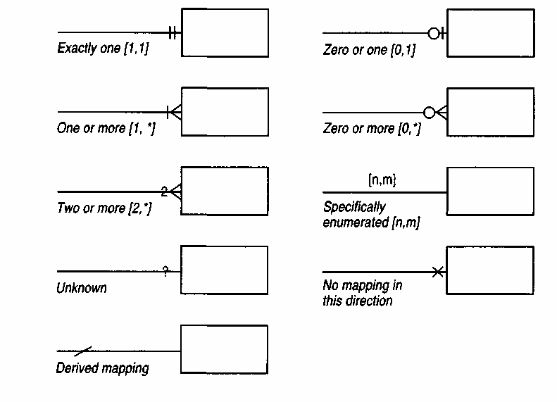

概括符号

Generalization notation

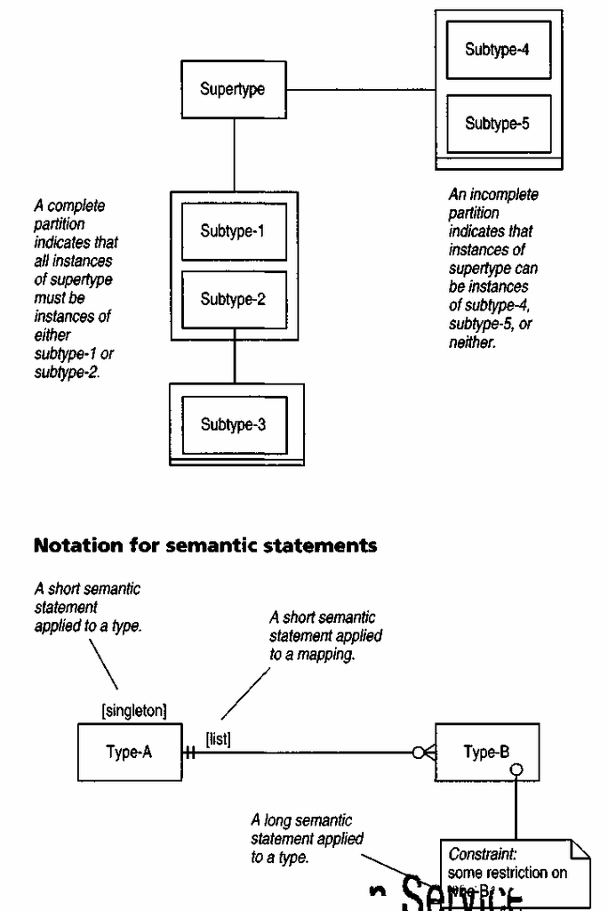

## 前言

## Preface

不久前，市面上几乎没有关于面向对象分析与设计的书籍。如今，这类书籍汗牛充栋，任何从业者都难以全部阅读。大多数书籍侧重于讲解某种符号体系，提出一种简单的建模流程，并用几个简单的例子加以说明。《分析模式：可重用对象模型》则截然不同。它并非着眼于建模过程（如何建模），而是聚焦于建模的结果——模型本身。

Not long ago, no books were available on object-oriented analysis and design. Now there are so many that it is impossible for any practitioner to keep up with them all. Most of these books concentrate on teaching a notation, suggesting a simple process for modeling, and illustrating it with a few simple examples. Analysis Patterns: Reusable Object Models is a different kind of book. Instead of focusing on the process—how to do modeling—it concentrates on the result of the process—the models themselves.

我是一名信息系统对象建模顾问。客户会邀请我培训员工进行建模，并为项目提供指导。我的技能主要来源于对建模技术及其应用的了解。然而，更重要的是我拥有丰富的实际模型创建经验，并且经常发现问题会反复出现。我经常发现，项目的许多方面都会重现我之前遇到的问题。这些经验使我能够重用之前构建的模型，对其进行改进，并使其适应新的需求。

I am a consultant in object modeling for information systems. Clients ask me to train staff on modeling and to provide mentoring on projects. Much of my skill comes from a knowledge of modeling techniques and how to use them. More important, however, is my experience in actually creating many models and regularly seeing problems repeat themselves. Frequently I find that many aspects of a project revisit problems I have faced before. That experience allows me to reuse models I have built before, improve them, and adapt them to new demands.

近年来，越来越多的人开始意识到这种现象。我们认识到，传统的方法论书籍虽然很有价值，但仅仅展现了学习过程的第一步，而学习过程还必须涵盖实际构建的内容。这种认识催生了模式运动。这是一个多元化的群体，成员们代表着不同的兴趣和观点，但他们共同的目标是传播有用的软件系统模式。

Over the last few years, more and more people have also become aware of this phenomenon. We have realized that the typical methodology books, though valuable, only present the first step in a learning process that must also capture the actual things that are built. This realization has flowered into the patterns movement. This is a varied group of people, representing many different interests and opinions yet sharing the goal of propagating useful patterns of software systems.

由于模式社群的多样性，我们一直难以定义“模式”一词。我们都认为自己能够识别模式，而且在大多数情况下，大多数人都会认同这一点，但我们却无法给出一个统一的定义。以下是我的定义：模式是指在某个实际情境中行之有效，并且很可能在其他情境中也同样有效的理念。

As a result of the diversity of this patterns community, we have had difficulty in defining the term pattern. We all think we can recognize a pattern when we see it, we think most of us would agree in most cases, but we cannot come up with a single definition. Here is my definition: A pattern is an idea that has been useful in one practical context and will probably be useful in others.

我喜欢对模式的定义保持一定的宽泛性，因为我希望尽可能贴近模式的根本动机，而避免添加过多限制性的修正。模式可以有多种形式，每种形式都会增加一些对该类型模式有用的特殊功能。（1.2 节讨论了模式领域的现状以及本书的定位。）

I like to leave the definition quite loose because I wish to stay as close to the underlying motivation of patterns, without adding too many restrictive amendments. A pattern can have many forms, and each form adds specializations that are useful for that kind of pattern. (Section 1.2 discusses the current state of the patterns world and where this book fits in.)

本书探讨的是分析模式，这些模式反映的是业务流程的概念结构，而非实际的软件实现。大部分章节讨论了各个业务领域的模式。这些模式很难归入传统的垂直领域（例如制造业、金融业、医疗保健业等），因为它们通常在多个领域都适用。这些模式之所以重要，是因为它们有助于我们理解人们如何感知世界。基于这种感知来设计计算机系统，甚至改变这种感知——这正是业务流程重组（BPR）的意义所在——都具有重要价值。

This book is about patterns in analysis, patterns that reflect conceptual structures of business processes rather than actual software implementations. Most of the chapters discuss patterns for various business domains. Such patterns are hard to classify into traditional vertical areas (manufacturing, finance, health care, and so on) because they are often useful in several areas. These patterns are important because they help us to understand how people perceive the world. It is valuable to base a computer system's design on this perception and, indeed, to change that perception—which is where business process reengineering (BPR) comes in.

然而，概念模式并非孤立存在。只有当软件工程师能够理解如何实现概念模型时，它们才能发挥作用。本书介绍了一些可用于将概念模型转化为软件的模式，并探讨了这些软件如何融入大型信息系统的架构。此外，本书还分享了一些具体的模式实现技巧。

Conceptual patterns cannot exist in isolation, however. Conceptual models are only useful to software engineers if they can see how to implement them. In this book I present patterns that can be used to turn conceptual models into software, and I discuss how that software fits into an architecture for a large information system. I also discuss specific implementation tips with the patterns.

我写这本书是因为我当初入行时就想读这样的书。建模人员可以从本书中找到灵感，帮助他们在新领域开展工作。书中的模式包含实用的模型、模型背后的设计原理，以及适用和不适用的场景。有了这些信息，建模人员可以根据具体问题调整模型。

I wrote this book because this was the book that I wanted to read when I started out. Modelers will find ideas in this book to help them begin working in a new domain. The patterns contain useful models, the reasoning behind their designs, and when they should and should not be applied. With this information a modeler can adapt the models to fit a specific problem.

本书中的模式也可用于模型审查——查看可能遗漏的内容，并提出一些可能改进的替代方案。在审查项目时，我通常会将所见与我从以往工作中学到的模式进行比较。我发现，了解工作中的模式有助于我更轻松地应用过去的经验。这类模式还能揭示一些超出简单教科书范围的建模问题。通过探讨我们为何以这种方式建模，即使我们不直接使用这些模式，也能更深入地理解如何改进建模。

The patterns in this book can also be used in reviewing models—to see what might have been left out and to suggest some alternatives that may lead to improvement. When I review a project, I usually compare what I see with the patterns I have learned from previous work. I have found that being aware of patterns in my work helps me to apply my past experiences more easily. Patterns like this also uncover modeling issues that go beyond what can be covered in a simple text book. By discussing why we model things the way we do, we gain a greater understanding of how to improve our modeling, even if we don't use the patterns directly.

本书结构分为两部分。第一部分涵盖分析模式，这些模式源自概念性商业模型。它们提供了交易、计量、会计和组织关系等领域的关键抽象概念。这些模式是概念性的，因为它们代表了人们对业务的思考方式，而非计算机系统的设计方式。本部分各章节重点介绍可用的替代模式，以及这些替代模式的优缺点。虽然每种模式对于从事同一领域工作的人员来说都非常有用，但基本模式通常也适用于其他领域。

Structure of this Book This book is divided into two sections. The first section covers analysis patterns, which are patterns from conceptual business models. They provide key abstractions from domains such as trading, measurement, accounting, and organizational relationships. The patterns are conceptual because they represent the way people think about the business, rather than the way a computer system is designed. The chapters in this section stress alternative patterns that can be used, and the strengths and weaknesses of those alternatives. Although each pattern will clearly be useful to those working in the same domain, the basic pattern is often useful in other domains.

第二部分重点介绍支持模式，它能帮助您使用分析模式。支持模式展示了分析模式如何融入信息系统架构，概念模型的结构如何转化为软件接口和实现，以及某些高级建模结构如何与更简单的结构相关联。

The second section focuses on support patterns, which help you use analysis patterns. Support patterns show how analysis patterns fit into an information systems architecture, how the constructs of conceptual models turn into software interfaces and implementations, and how certain advanced modeling constructs relate to simpler structures.

为了描述这些模式，我需要一套符号系统。附录简要讨论了我使用的符号系统及其含义。我并不只使用一种方法，而是倾向于融合不同方法的技巧。附录并非旨在提供技巧教程，而是提供一个概述并帮助您回忆相关内容。它还告诉您在哪里可以找到关于我所用技巧的教程。

To describe these patterns, I need a notation. The appendix provides a brief discussion of the notation I use and what the symbols mean. I do not use a single method but prefer to mix techniques from different methods. The appendix is not designed to be a tutorial on techniques, but it should provide an outline and refresh your memory. It also tells you where to find a tutorial on the techniques I use.

每个部分都分为若干章节。每个关于分析模式的章节都包含一些模式，这些模式在主题领域上存在一个大致的关联，并受到催生这些模式的项目的影响。这种组织方式体现了任何模式都必须源于实际应用这一事实。每个模式都出现在章节内的一个子章节中。我没有使用某些模式作者使用的正式标题（参见1.2.2节）。我尽可能以接近原始项目形式的方式来描述每个模式，并尽量减少抽象。我添加了示例来展示模式在其原始领域中的应用，并提出模式在其他领域中的应用可能性。模式的最大难点之一在于如何将其抽象到其他领域；我遵循的原则是，这应该留给读者自行探索（参见1.2.3节）。因此，本书更像是一个目录，而不是一本需要从头到尾阅读的书籍。我力求使每个章节都可以独立于其他章节阅读。 （但这并非总是可行。如果某一章节需要先阅读另一章节，我会在该章节的引言中说明。）每一章都有一个引言，解释该章节的一般主题领域，总结该章节中的模式，并说明这些模式源自哪些项目。

Each section is divided into chapters. Each chapter on analysis patterns contains patterns that are related by a loose notion of subject area, influenced by the projects that spawned them. This organization reflects the fact that any pattern must come from a practical context. Each pattern appears in its own subsection within a chapter. I do not use any of the formal headings for patterns that are used by some patterns authors (see Section 1.2.2). I describe each pattern in a form that is as close to the original project form as is reasonable, with a minimum of abstraction. I add examples to show the use of the pattern within its original domain and also to suggest how the pattern might be used in other domains. One of the greatest difficulties of patterns is abstracting them into other domains; I follow the principle that this should be left to the reader (see Section 1.2.3). This book is thus a catalog, rather than a book to be read from cover to cover. I have tried to write each chapter in such a way that it can be read independently from the other chapters. (This is not always possible, however. Whenever a chapter requires that another chapter be read first, I say so in the chapter introduction.) Each chapter has an introduction that explains the general subject area of the chapter, summarizes the patterns in the chapter, and says what projects the patterns originated from.

如何阅读本书？我建议您先通读第一章，然后再阅读各章的引言。之后，您可以随意选择阅读顺序。如果您不熟悉我的建模方法、符号和概念，请阅读附录。“模式表”简要概述了每种模式的内容，方便您日后查阅或探索书中的模式。需要强调的是，本书中的每种模式在其最初应用领域之外也同样适用。因此，我鼓励您阅读一些您认为与自身兴趣领域无关的章节。例如，我发现为医疗保健行业设计的观察和测量模型在企业财务分析中也同样适用。

How to Read this Book I suggest reading all of Chapter 1 first and then reading each chapter introduction. Then feel free to delve into the chapters in any order you like. If you are not familiar with the approach I take to modeling, or the notation and concepts I use, read the appendix. The Table of Patterns gives a brief summary of what each pattern is about, so you can use that to help you explore or to find a pattern when you come back to the book at a later time. It is important to stress that each pattern in this book is useful outside the domain that gave it birth. Thus I encourage you to look into chapters that you might think are outside your field of interest. For example, I found that models of observation and measurement designed for health care proved to be very useful for corporate financial analysis.

谁应该读这本书？ 这本书对很多读者都有用，尽管不同的读者会从中学到不同的东西，也可能需要一些不同的准备。

Who Should Read this Book This book can be useful to a range of readers, although different readers will learn different things from it and may need some different preparations.

我预计本书的主要读者是面向对象（OO）计算机系统的分析师和设计师，特别是那些从事分析工作的人员。这类读者应该至少对面向对象分析和设计方法有所了解。本书并未提供任何相关介绍，因此如果您是该领域的新手，我建议您先阅读一本关于面向对象分析和设计的书籍。我必须强调，本书中的模式本质上是概念性的，我采用的是一种非常概念化的建模方法。这导致本书在风格上与那些采用更注重实现的建模方法的书籍有所不同。

I expect my biggest audience to be analysts and designers of object-oriented (OO) computer systems, particularly those working at the analysis end. Such readers should have made at least some use of an OO analysis and design method. This book does not provide any introduction to this subject, so I would suggest first reading a book on OO analysis and design if you are new to this field. I must stress that the patterns in this book are conceptual in nature, and I use a very conceptual approach to modeling. This leads to some stylistic differences from those texts that use a more implementation-based approach to modeling.

本书的读者群体虽小，但却非常重要，他们是建模项目中的领域专家。这类读者无需具备计算机知识，但需要了解概念建模。我之所以在本书中使用概念模型，主要原因之一就是为了方便这类读者。这里的建模项目可以是计算机系统开发分析，也可以是业务流程重组（BPR）。我曾向许多专业人士（包括医生、金融交易员、会计师、护士和薪资主管）讲授过这类建模方法，发现软件背景对于概念建模而言既非优势也非劣势。业务模型模式既适用于业务建模，也适用于计算机系统分析（参见1.4节）。任何此类读者都应该参加一门强调概念方面的面向对象分析课程。（Odell 的著作[I]在这方面尤其有价值。）

A small, but very important, audience consists of those people who act as domain experts for a modeling project. Such readers do not require a knowledge of computers but do need to know about conceptual modeling. One of the main reasons I use conceptual models in this book is to make things easier for this group of readers. The modeling project here may be analysis for computer system development or BPR. I have taught many professionals (including doctors, financial traders, accountants, nurses, and payroll supervisors) this kind of modeling and have found that a software background is neither an advantage nor a disadvantage to conceptual modeling. The business model patterns are as much about business modeling as they are about computer systems analysis (see Section 1.4). Any such reader should take a course on OO analysis that stresses the conceptual aspect. (Odell's book [ I ] is particularly valuable in this respect.)

我希望许多程序员都能认真阅读本书，尽管有些程序员可能会对书中缺乏代码示例和偏重概念的论述方式感到不满。对于这些读者，我建议你们特别留意第14章，该章应该有助于解释概念模型与最终软件之间的关系。

I hope many programmers will delve between these covers, although some programmers may take exception to the lack of code and the conceptual slant. For these readers I suggest you take particular note of Chapter 14, which should help to explain the relationship between the conceptual models and the resulting software.

这是一本面向对象的书籍，我毫不犹豫地宣称，面向对象方法是开发软件的最佳途径。然而，这些模型主要是概念模型，而许多数据建模人员长期以来一直使用概念（或逻辑）模型。数据建模人员会发现其中许多模式很有用，尤其是在他们使用更高级的语义技术的情况下。这些模型的面向对象特性将揭示面向对象方法与传统方法之间的许多差异。我建议读者将本书与一本强调建模的概念方面以及面向对象与语义数据建模之间联系的面向对象分析书籍结合使用。

This is an object-oriented book, and I do not hesitate in proclaiming my belief that the object-oriented approach is the superior way to develop software. These models, however, are primarily conceptual models, and many data modelers have had a long tradition of using conceptual (or logical) models. Data modelers should find many of the patterns useful, particularly if they use more advanced semantic techniques. The object-oriented features of the models will reveal many of the differences between object-oriented and traditional approaches. I would encourage such readers to use this book in conjunction with an OO analysis book that stresses the conceptual side of modeling and the links between OO and semantic data modeling.

管理者会发现本书可作为开展发展活动的起点。从某种模式入手有助于明确目标，项目规划也能充分利用这些模式所勾勒出的广阔图景。

Managers will find the book useful as a starting point for development activity. Starting from a pattern can help to clarify goals, and project planning can take advantage of the broad ground that patterns map out.

我写这本书并非为了学生，而是为了专业的软件工程师。不过，我希望有些学生也能看看。我当初学习分析与设计时，发现很难，因为能借鉴的优秀案例很少，尤其是那些来自大学之外的实际案例。正如优秀的代码能让你学到很多编程知识一样，优秀的模型也能让你学到很多分析与设计知识。

I have not aimed this book at students. I've written it more for the professional software engineer. I hope, however, that some students will take a look. When I was learning analysis and design, I found it difficult because there were few good examples I could learn from, examples that came out of the world outside the university. Just as looking at good code can teach you a lot about programming, looking at good models can teach you a lot about analysis and design.

一本鲜活的书 我认识的每一位作者都面临着同样的困境：一旦书出版，就仿佛定型了。书的内容在读者群体中传播，但作者却很难表达自己的想法。我知道自己一直在不断学习，也确信这些学习会改变我的想法。我希望这些改变能够传递给我的读者。

A Living Book Every author I know shares a frustration: Once a book is published it is fixed. The book spreads its advice around the community, yet the author has little way of expressing changes. I know how much I keep learning, and I am sure this learning will modify my ideas. I want these changes to be passed on to my readers.

艾迪生-韦斯利出版社将为本书提供一个网站<http://www.aw.com/cp/fowler.html>，用于发布更多资料，以延续本书的生命力。目前我还不确定网站的具体内容，但我预计会包含以下几点：

With this book, Addison-Wesley will provide a web site <http:// www.aw.com/cp/fowler.html> which will be used to pass on further materials to keep this book alive. At this stage I am not sure exactly what it will contain, but I expect the following:

• 我在书中学到的任何关于图案的新知识。

• any new things I learn about the patterns in the book.

• 对本书相关问题的回答

• answers to questions about the book

• 其他人对这些模式的有用评论

• useful commentary from others about the patterns

• 我和其他人提出的新分析模式

• new analysis patterns by myself, and by others

• 当统一建模符号出现时（或者到那时叫什么名字），我将用新的符号重新绘制书中的所有图表，并将它们放到网站上。

• when the Unified Modeling Notation appears (or whatever it is called by then) I will redraw all the diagrams in the book in the new notation and put them on the site.

这个网站将作为本书的补充，请密切关注它，并利用它告诉我如何改进和发展本书中的想法。

This site will be a complement to the book, so keep an eye on it and use it to let me know how to improve and develop the ideas between these pages.

致谢 任何作者都应感谢众多帮助过他的人。本书尤其如此，因为其中许多模式都是在我的客户、同事和朋友的帮助下构建的。在此，我谨向以下人士致以诚挚的谢意，无论他们是直接提及还是默默付出。

Acknowledgments Any author is indebted to many others who help. For this book this is particularly true since so many of the patterns were built with the help of my cli ents, colleagues, and friends. I would like to give my sincere thanks to the following, both named and implied.

首先，吉姆·奥德尔是我职业生涯中不可或缺的一部分。他教会了我很多关于信息系统开发的知识，并且一直是我灵感的源泉，给予我很多有益的建议，还总能给我带来独特的幽默感。我可以毫不夸张地说，没有他的支持，这本书根本不可能问世。

First and foremost, Jim Odell has been an essential part of my career. He has taught me much about developing information systems and has been a constant source of inspiration, helpful advice, and strange humor. I can safely say that without his support this book would not have happened.

伦敦 Coopers & Lybrand 团队在早期工作中提供了很大帮助，并陪伴我们度过了许多在 Smithfield's 的夜晚。

The team at Coopers & Lybrand in London helped with much of the early work and helped pass many evenings at Smithfield's.

John Edwards 对我早期关于概念建模及其在软件开发中的作用的许多想法产生了影响，他还向我介绍了许多有趣的想法，包括 Christopher Alexander 的想法。

John Edwards formed many of my early ideas about conceptual modeling and its role in software development, as well as introducing me to many interesting ideas, including those of Christopher Alexander.

约翰·霍普敦促我先考虑领域，再考虑技术，并在我职业生涯的几个关键时刻对我施了有益的魔法。

John Hope urged me to think of the domain first and technology second, as well as casting a helpful spell at several key points in my career.

伦敦圣玛丽医院的医生汤姆·凯恩斯和马克·瑟兹与我合作开发了构成本书第二章、第三章和第八章基础的医疗保健模型。他们证明，计算机背景并非成为一流概念建模师的必要条件。马克还慷慨地提供了许多医疗保健案例，这些案例运用了听起来很专业的医学术语。

Tom Cairns and Mark Thursz, doctors at St. Mary's Hospital in London, worked with me in developing the health care models that form the basis of Chapters 2, 3, and 8. They are proof that a computer background is not necessary to be a top-class conceptual modeler. Mark also was a willing source for health care examples with impressive-sounding medical terminology.

这些医疗保健项目还汇集了来自圣玛丽医院、多伦多病童医院 (HSC)、圣托马斯医院和威尔士大学的众多软件和医疗保健专业人员。多伦多病童医院的护士安妮·凯西和分析师哈齐姆·蒂米米协助完成了最终的 Cosmos 模型。格里·戈尔德负责这项工作的筹备和推进。

The health care projects also involved many software and health care professionals from St. Mary's, the Hospital for Sick Children (HSC), St. Thomas's Hospital, and the University of Wales. Anne Casey, a nurse at HSC, and Hazim Timimi, an analyst, helped put together the final Cosmos model. Gerry Gold set up this work and made sure it kept going.

Brad Kain 对我关于再利用和组件的思考产生了很大的影响，他还承担了向我展示波士顿夜生活的重要任务。

Brad Kain has had a great impact on my thinking on reuse and components, as well as undertaking the important task of showing me the nightlife of Boston.

第四章中将医疗保健模型应用于公司财务的经历，对我而言，充分证明了分析模式在不同领域的实用性。Lynne Halpin 和 Craig Lockwood 领导了施乐公司的 MBFW 团队，而 Vivek Salgar 则将我们的概念性想法转化为 C++ 的残酷现实。

Applying the health care models to corporate finance in Chapter 4 was the experience that, for me, proved the usefulness of analysis patterns across different domains. Lynne Halpin and Craig Lockwood led the MBFW team at Xerox, and Vivek Salgar got our conceptual ideas into the brutal reality of C++.

大卫·克雷格、史蒂夫·谢泼德和他们在花旗银行的团队与我合作开发了模型，我从中汲取了第 9 章至第 11 章的金融模式。他们还从医疗保健领域进一步发展了第 12 章的许多架构理念，并教会了我很多关于伦敦金融城快节奏生活的知识。

David Creager, Steve Shepherd, and their team at Citibank worked with me in developing the models from which I drew the financial patterns in Chapters 9-11. They also further developed many of the architectural ideas of Chapter 12 from their health care origins, and taught me much about the frenetic life in The City.

弗雷德·皮尔负责我在花旗银行的工作安排和维护，当然，他开车时也经常吓到我。瓦尔贝克公司的丹尼尔·潘和哈齐姆·蒂米米则把我的许多模糊想法变成了详细的技术规范。

Fred Peel set up and maintained my work at Citibank, when not scaring me with his driving. Daniel Poon and Hazim Timimi from Valbecc got many of my fuzzy ideas into detailed specifications.

第六章的会计模式酝酿已久。Tom Daly、Peter Swettenham、Tom Hadfield 和他们各自的团队开发了模型，这些模型孕育了本书中的模式。Rich Garzaniti 帮我理清了会计术语。Kent Beck 则极大地改进了我的 Smalltalk 代码。

The accounting patterns in Chapter 6 have had a long gestation. Tom Daly, Peter Swettenham, Tom Hadfield, and their respective teams developed models that gave birth to the patterns in this book. Rich Garzaniti got my accounting terminology sorted out. Kent Beck did much to improve my Smalltalk.

第十四章是在詹姆斯·奥德尔的帮助下撰写的。

Chapter 14 was written with the help of James Odell.

我加入图案设计社群的时间比较晚，直到本书大部分内容完成后才开始深入了解这个社群。这是一个非常开放友好的群体，他们给予了我很多鼓励。肯特·贝克、沃德·坎宁安和吉姆·科普林鼓励我积极参与社群活动，并将我的想法发展成图案。拉尔夫·约翰逊对本书初稿提出了特别有益的意见。

I have been very much a latecomer to the patterns community, getting to know it well only after most of this book was written. It is a very open and friendly group that has done much to encourage my work. Kent Beck, Ward Cunningham, and Jim Coplein encouraged me to get involved with the community and to develop my ideas as patterns. Ralph Johnson provided particularly helpful comments on the first draft of this book.

我收到了许多审稿人的宝贵意见，在此我想提及他们的名字：Dave Collins、Ward Cunningham（Cunningham & Cunningham, Inc.）、Henry A. Etlinger（罗切斯特理工学院计算机科学系）、Donald G. Firesmith（Knowledge Systems Corporation）、Erich Gamma、Adele Goldberg、Tom Hadfield（TesserAct Technology）、Lynne Halpin（Netscape Communications）、Brian Henderson-Sellers、Neil Hunt（Pure Software）、Ralph E. Johnson（伊利诺伊大学厄巴纳-香槟分校）、Jean-Pierre Kuilboer（马萨诸塞大学波士顿分校）、Patrick D. Logan（英特尔公司）、James Odell、Charles Richter（Objective Engineering, Inc.）、Douglas C. Schmidt（华盛顿大学）和Dan Tasker。我还要特别提及Don Firesmith，他尽职尽责地追踪并修复了所有问题。

I have had first-class comments from my many reviewers whom I would like to name: Dave Collins, Ward Cunningham (Cunningham & Cunningham, Inc.), Henry A. Etlinger (Department of Computer Science, RIT), Donald G. Firesmith (Knowledge Systems Corporation), Erich Gamma, Adele Goldberg, Tom Hadfield (TesserAct Technology), Lynne Halpin (Netscape Communications), Brian Henderson-Sellers, Neil Hunt (Pure Software), Ralph E. Johnson (University of Illinois at Urbana-Champaign), Jean-Pierre Kuilboer (University of Massachusetts, Boston), Patrick D. Logan (Intel Corporation), James Odell, Charles Richter (Objective Engineering, Inc.), Douglas C. Schmidt (Washington University), and Dan Tasker. I will mention that Don Firesmith went above the call of duty in tracking down problems that needed to be fixed.

这是我的第一本书，我特别感谢Addison-Wesley出版社的各位，感谢他们在整个过程中给予我的帮助。Carter Shanklin负责统筹一切，并在Angela Buenning的大力协助下组建了一个实力雄厚的评审团。Teri Hyde在极其紧张的工期下协调了图书制作，而Barbara Conway则让我的文字摆脱了以往的混乱状态，并毫不留情地纠正了我的口音。

As this is my first book, I'm particularly grateful to those at Addison-Wesley who helped me through the process. Carter Shanklin directed affairs and assembled a formidable panel of reviewers with much assistance from Angela Buenning. Teri Hyde coordinated the book production on a painfully tight schedule and Barbara Conway rescued my prose from its usual erratic state, and ruthlessly eliminated my native accent.

参考

References

1. Martin, }., 和 J. Odell.面向对象方法：基础。Englewood Cliffs, NJ: Prentice-Hall, 1995。

1. Martin, }., and J. Odell. Object-Oriented Methods: A Foundation. Englewood Cliffs, NJ: Prentice-Hall, 1995.

[figure not shown]

## 第一章 引言

## Chapter 1. Introduction

### 1.1 概念模型

### 1.1 Conceptual Models

大多数关于对象建模的书籍都会讨论分析和设计。但对于这两者之间的界限，却鲜有共识。对象开发的一个重要原则是，软件的结构要能够反映问题的结构。这一原则的一个结果是，分析和设计生成的模型最终往往非常相似，这使得许多人误以为两者之间没有区别。

Most books on object modeling talk about analysis and design. There is little agreement on where the boundary between these two activities lies. An important principle in object development is designing software so that its structure reflects that of the problem. One result of this principle is that the models produced from both analysis and design end up deliberately similar, leading many people to think that there is no difference.

我认为分析和设计之间仍然存在区别，但这种区别正日益演变为侧重点的差异。进行分析时，你试图理解问题。在我看来，这不仅仅是列出用例中的需求[8]。用例是系统开发中非常重要甚至必不可少的一部分，但收集用例并非分析的终点。分析还包括深入探究表面需求，从而构建出问题本质的思维模型。

I believe a difference between analysis and design still exists, but it is increasingly becoming one of emphasis. When doing analysis you are trying to understand the problem. To my mind this is not just listing requirements in use-cases [8]. Use-cases are a valuable, if not essential, part of system development, but capturing them is not the end of analysis. Analysis also involves looking behind the surface requirements to come up with a mental model of what is going on in the problem.

假设有人想编写一个模拟斯诺克比赛的软件。这个问题可以从描述表面特征的使用场景来评估：“球员击打白球，使其以特定速度运动；白球以特定角度击中红球；红球沿特定方向运动一段距离。”你可以拍摄数百个这样的场景，并测量球速、角度和运动距离。但仅凭这些例子可能不足以编写一个好的模拟程序。要做好这项工作，你需要深入了解运动的本质，理解质量、速度、动量等相关的运动定律。理解这些定律将使软件的构建变得更加容易。

Consider someone who wants to write software to simulate a game of snooker. This problem could be evaluated in terms of use-cases that describe the surface features: "The player hits the white ball so it travels at a certain speed; it hits the red ball at a certain angle, and the red ball travels a certain distance and direction." You could film several hundred such incidents and measure ball speeds, angles, distances traveled. But these examples alone would probably not be enough to write a good simulation. To do the job well, you would need to look behind the surface to understand the laws of motion that relate mass, velocity, momentum, and the like. Understanding those laws would make it much easier to see how the software could be built.

斯诺克球问题的特殊之处在于，其规律众所周知，而且由来已久。在许多企业中，类似的原理却鲜为人知，我们需要努力去发掘它们。为此，我们需要构建一个概念模型——一个能够帮助我们理解和简化问题的思维模型。某种形式的概念模型是软件开发中必不可少的一部分，即使是最不加节制的黑客也会这样做。区别在于，我们是将概念建模视为一个独立的过程，还是将其视为整个软件设计过程的一个方面。

The snooker ball problem is unusual because the laws are well known and have been well known for a long time. In many enterprises the equiva lent foundations are not so well understood, and we have to make the effort to uncover them. To do this we create a conceptual model—a mental model that allows us to understand and simplify the problem. Some kind of conceptual model is a necessary part of software development, and even the most uncontrolled hacker does it. The difference is whether we think about conceptual modeling as a process in itself or as one aspect of the entire software design process.

重要的是要记住，概念模型是人为的产物。开发者用来创建类似斯诺克模拟程序的运动定律并非真实世界的一部分；它们代表的是一个由人类创造的真实世界模型。从工程学的角度来看，这些模型之所以有效，是因为它们能帮助我们更好地理解现实世界中发生的事情。此外，开发者可以使用多个模型；例如，对于斯诺克模拟，可以使用牛顿模型或爱因斯坦模型。有人可能会认为爱因斯坦模型更准确，因为它考虑了球速变化引起的质量变化，因此更加精确。然而，开发者几乎肯定会更倾向于牛顿模型，因为球速非常低，对模拟结果的影响微乎其微，但却会增加很多额外的复杂性。这说明了一个重要的原则：没有绝对正确或错误的模型，只有最适合当前任务的模型。

It is important to remember that a conceptual model is a human artifact. The laws of motion that a developer uses to create something like the snooker simulation are not part of the real world; they represent a model of the real world, a model created by human beings. They are effective, in engineering terms, because they allow us to better understand what happens in the real world. Also, a developer can use more than one model; for the snooker simulation a Newtonian or Einsteinian model could be used. You could argue that the Einsteinian model would be more correct because it takes into account changes of mass due to the speed the balls are traveling and is thus more precise. The developer would almost certainly prefer the Newtonian model, however, because the speeds would be so low that they would make a negligible difference to the simulation but would involve a lot of extra complexity. This illustrates an important principle: There is no right or wrong model, merely one that is more useful for the job at hand.

**建模原理**

**Modeling Principle**

*模型本身没有对错之分，只有实用性高低之分。*

*Models are not right or wrong; they are more or less useful.*

模型的选择会影响最终系统的灵活性和可重用性。你可能会认为开发者应该使用爱因斯坦模型，因为这样生成的软件足够灵活，可以处理涉及原子碰撞的问题。但这其实是一条危险的道路。在系统中构建过多的灵活性会导致其过于复杂，这是一种糟糕的工程设计。工程设计需要在构建和维护产品的成本与其提供的功能之间进行权衡。要构建符合特定用途的软件，你必须开发一个符合自身需求的理论模型。你需要尽可能简化的模型。不要添加你不太可能用到的灵活性。

The choice of model affects the flexibility and reusability of the resulting system. You might argue that the developer should use an Einsteinian model because the resulting software would be flexible enough to handle problems involving atomic collisions. But this is a dangerous path to go down. Building too much flexibility into a system can make it too complex, and this is bad engineering. Engineering demands a trade-off between the cost of building and maintaining an artifact and the features it will provide. To build software that is fit for a purpose, you have to develop a conceptual model that is appropriate to your needs. You need the simplest model you can get away with. Don't add flexibility you are unlikely to use.

最简单的模型未必是你首先想到的。找到一个简单的解决方案需要花费大量的时间和精力，这可能会令人沮丧。人们常常会对一个简单的模型说“哦，是啊，这显而易见”，然后心想“那为什么花了这么长时间才想到呢？” 但简单的模型总是值得付出努力的。它们不仅让开发更容易，更重要的是，它们让未来的维护和扩展更加便捷。这就是为什么用更简单但同样有效的软件来替换现有的软件是值得的。

The simplest model is not necessarily the first one you think of. Finding a simple solution takes a lot of time and effort, which can be frustrating. People often react to a simple model by saying "Oh yes, that's obvious" and thinking "So why did it take so long to come up with it?" But simple models are always worth the effort. Not only do they make things easier to build, but more importantly they make them easier to maintain and extend in the future. That's why it is worth replacing software that works with simpler software that also works.

如何表达概念模型？对许多人来说，概念模型是内置于他们使用的软件语言中的。语言的优势在于，你可以执行模型来验证其正确性并进行更深入的探索。这可不是什么小优势；我经常在概念建模中使用 Smalltalk。另一个优势是，你最终必须将模型转换为编程语言，因此使用目标语言进行建模可以省去转换步骤。（有一些工具可以解释或编译分析和设计模型，从而减少与转换相关的问题。）

How do you express a conceptual model? For many people the conceptual model is built into their software language. The advantage of a language is that you can execute a model to verify its correctness and to further explore it. This is no small advantage; I often use Smalltalk in my conceptual modeling. Another advantage is that you have to turn the model into a programming language eventually, so modeling in your target language saves the step of translation. (There are tools that can interpret or compile analysis and design models, thus reducing the problems associated with translation.)

使用某种编程语言的风险在于，很容易陷入使用该语言的各种细节中，而忽略了你试图理解的问题本身。（对于像 Smalltalk 这样的高级语言来说，这个问题不太明显。我认识几位才华横溢的概念建模师，他们就用这种语言进行建模。）用编程语言建模的另一个风险是，模型可能会被绑定到该语言上。模型可能会用到其他语言所不具备的特性。这并不意味着概念模型不能移植到另一种语言，但移植过程会更加困难。

The danger of using a language is that it is easy to get lost in the issues of using that language and lose sight of the problem you are trying to understand. (This is less of a problem with higher-level languages, such as Smalltalk. I know several gifted conceptual modelers who do their modeling in that language.) Modeling in a programming language also presents the danger of tying the models to that language. The model may use features of that language that are not available in other languages. This does not mean that the conceptual model cannot be moved to another language, but it can make the process more difficult.

为了避免这些问题，许多人使用分析和设计技术进行概念建模。这些技术可以帮助人们专注于概念问题而非软件设计问题，而且更容易教授给领域专家。分析和设计技术利用图形来增强表达效果。它们可能很严谨，但并非必须如此。旨在实现可执行性的技术必须严谨，但当分析方法与编程语言结合使用时，则无需如此严谨。

To avoid these problems, many people use analysis and design techniques for conceptual modeling. These techniques can help people concen trate on conceptual rather than software design issues, and they can be easier to teach to domain experts. Analysis and design techniques use graphics to be more expressive. They may be rigorous, but they don't have to be. Techniques designed to be executable must be rigorous, but when analysis methods are used in conjunction with a programming language, they need not be as rigorous.

我使用分析和设计技术的主要原因之一是让领域专家参与其中。让领域专家参与概念建模至关重要。我相信，只有真正了解该领域的人员——该领域的全职工作者，而不是软件开发人员，无论他们在该领域工作了多久——才能构建有效的模型。如果要让领域专家进行概念建模，就必须对他们进行培训。我曾向客户服务主管、医生、护士、金融交易员和企业财务分析师教授面向对象分析和设计技术。我发现，IT背景对建模技能既无帮助也无阻碍。我认识的最优秀的建模师是一位伦敦医院的医生。作为专业的分析师和建模师，我为这个过程带来了宝贵的技能：我能够提供严谨性，我知道如何运用这些技术，而且我的局外人视角可以挑战既有的观点。然而，所有这些都还不够。无论我在医疗保健计算领域做了多少工作，我永远无法像医生或护士那样了解医疗保健。专家知识是构建良好分析模型的核心。

One of the main reasons I use analysis and design techniques is to involve domain experts. It is essential to have domain experts involved in conceptual modeling. I believe that effective models can only be built by those that really understand the domain—full-time workers in the domain, not software developers, no matter how long they have worked in the domain. If domain experts are to do conceptual modeling, they must be taught. I have taught OO analysis and design techniques to customer service supervisors, doctors, nurses, financial traders, and corporate financial analysts. I have found that an IT background is neither a help nor a hindrance to skill in modeling. The best modeler I know is a physician at a London hospital. As the professional analyst and modeler, I bring valuable skills to the process: I can provide rigor, I know how to use the techniques, and my outsider's view can challenge accepted wisdom. All this is not enough. However much work I do in health care computing, I will never know? as much about health care as a doctor or nurse. Expert knowledge is central to a good analysis model.

分析技术旨在独立于软件技术。理想情况下，概念建模技术应该像运动定律一样完全独立于软件技术。这种独立性可以防止技术阻碍对问题的理解，并且最终得到的模型对所有类型的软件技术都同样适用。然而，在实践中，这种纯粹性并不存在。我尝试开发完全专注于问题的概念模型，但我的技术是面向对象的，因此体现了一种软件设计方法。通过将本书中的模型与 David Hay [7] 的模型进行比较，您可以很好地了解软件技术如何影响概念建模。我们都在尝试构建概念模型，但由于他使用关系型技术而我使用面向对象技术，因此我们的结果不同。这是软件本质的必然结果。构建软件就是构建虚拟机。我们用来构建软件的语言既可以控制物理机器，也可以表达问题的需求。我们语言发生变化的原因之一是我们找到了表达问题需求的更好方法。因此，这些语言的变化会影响我们构建概念模型的方式。尽管存在一些棘手的领域（参见第 14 章），但将所得模型转换为面向对象的软件并不难。

Analysis techniques are intended to be independent of software technology. Ideally a conceptual modeling technique is totally independent of software technology, as are the laws of motion. This independence would prevent technology from hindering an understanding of the problem, and the resulting model would be equally useful for all kinds of software technology. In practice this purity does not occur. I try to develop very conceptual models that focus entirely on the problem, yet my techniques are object-oriented and hence reflect a software design approach. You can get a good sense of how software technology affects conceptual modeling by comparing the models in this book with those of David Hay [7]. We are both trying to build conceptual models, yet our results are different because he uses a relational technique and I use an object-oriented one. This is an inevitable result of the nature of software. Building software is building virtual machines. The languages in which we build software can both control the physical machine and express the needs of the problem. One of the reasons our languages change is because we find better ways to express the needs of a problem. These language changes thus influence the way we build conceptual models. Despite a few tricky areas (see Chapter 14), the resulting models are not difficult to turn into object-oriented software.

不过，我现在需要提醒一点，概念模型与软件接口密切相关，而非软件实现。面向对象软件的一个重要特点是它将接口与实现分离。遗憾的是，这种区分在实践中很容易被忽略，因为常用语言并没有明确区分这两者。软件组件的接口（类型）和实现（类）之间的区别至关重要。“四人帮”著作[6]中的许多重要的基于委托的模式都依赖于这种区分。在实现这些模型时，切勿忘记这种区别。

One caution I do need to raise now, however, is that conceptual models relate closely to software interfaces rather than software implementations. One of the important things about object-oriented software is that it separates interface from implementation. Unfortunately this distinction is too easily lost in practice because common languages do not make an explicit distinction between the two. The difference between a software component's interface (its type) and its implementation (its class) is extremely important. Many important delegation-based patterns in the "Gang of Four" book [6] rely on this distinction. When implementing these models, don't forget the difference.

**建模原理**

**Modeling Principle**

*概念模型与接口（类型）相关联，而不是与实现（类）相关联。*

*Conceptual models are linked to interfaces (types) not implementations (classes).*

### 1.2 图案的世界

### 1.2 The World of Patterns

近几年来，模式已成为对象设计社区最热门的话题之一。它们正迅速成为前沿潮流，引发了广泛的关注和炒作。我们也看到社区内部就模式的定义展开了激烈的争论，其中不乏关于模式究竟是什么的争论。显然，要找到一个普遍认可的模式定义并非易事。

In the last couple of years, patterns have become one of the hottest topics in the object community. They are rapidly becoming the leading-edge fad, generating a huge amount of interest and the usual hype. We are also seeing internal battles over what fits into the community, including many arguments about exactly what a pattern is. Certainly it is difficult to find any common definition of pattern.

模式运动的根源来自多个方面。近年来，越来越多的人认为软件界在描述和推广优秀设计实践方面做得不够好。方法论层出不穷，但它们定义的只是描述设计的语言，而不是描述实际的设计。过去（现在依然如此）缺乏基于实践描述实用设计的技术论文，而这些论文本可以用来进行教育和启发。正如拉尔夫·约翰逊和沃德·坎宁安所说：“即使拥有最新的技术，项目失败的原因仍然是缺乏常规的解决方案”[4]

The roots of the patterns movement come from various sources. In recent years an increasing number of people felt that the software world was not very good at describing and proliferating good design practice. Methodologies abounded, but they defined a language for describing designs rather than describing actual designs. There was (and still is) a dearth of technical papers describing useful designs based on practice, which could be used to educate and inspire. As Ralph Johnson and Ward Cunningham put it: "Projects fail despite the latest technology for lack of ordinary solutions" [4],

模式的形成源于多项举措。Smalltalk 的两位先驱 Kent Beck 和 Ward Cunningham 接触到了 Christopher Alexander 的思想，后者发展了一套架构理论和模式集合。20 世纪 90 年代初，Bruce Anderson 在 OOPSLA 大会上主持了研讨会，探讨如何编写一本软件架构师手册。Jim Coplien 的 C++ 著作 [3] 描述了 C++ 中常用的惯用法。这些人中的一些人组建了 Hillside Group，以进一步探索这些理念。

Patterns evolved from several initiatives. Kent Beck and Ward Cunning-ham, two of the pioneers of Smalltalk, came across the ideas of Christopher Alexander, who had developed a theory and collection of patterns in architecture. Bruce Anderson led workshops at OOPSLA in the early 1990s that investigated building a handbook for software architects. Jim Coplien's C++ book [3] described idioms useful in C++. A number of these people formed the Hillside Group to explore these ideas further.

1994 年，希尔赛德小组创办了具有开创性的《四人帮》一书 [6] 和 PLoP（编程模式语言）会议 [4]，这引发了公众对这一运动的更大了解。

A greater public knowledge of the movement was triggered by the publication of the seminal "Gang of Four" book [6] and the PLoP (Pattern Language of Programming) conference started by the Hillside group in 1994 [4].

我之前与这个日益壮大的社群接触甚少。我一直很想读一些描述概念模型的书籍，因为我觉得这类书籍能给我带来很多灵感。但我总觉得，在积累到足够多的模型，足以写出一本有价值的书之前，我无法着手撰写这类文章。我对模式运动很感兴趣，也觉得他们的许多原则都很有吸引力，但我却被一种印象所打消：这个群体似乎是一个封闭的小圈子，痴迷于建筑师克里斯托弗·亚历山大，而且他们的模式写作风格非常程式化。去年，我与他们有了更多接触，并参加了第二届PLoP会议。模式社群最显著的特点是其成员构成非常多元化。的确，有些人似乎把亚历山大的著作奉为圭臬，并乐于就不同的解读展开辩论。当然，也有很多人认为亚历山大的理论已经过时。有些人似乎在模式中看到了某种神秘的力量，而有些人则无法忍受模式中那种“感性”的表达方式。有些人认为模式颠覆了分析和设计方法，有些人认为概念建模是浪费时间，还有些人鼓励我写这本书，以展示分析或概念模式是什么样的。

I had had very little contact with this growing community. I had long wanted to read books that described conceptual models, because I felt such books would give me good ideas. I didn't feel I could write about such things until I had enough models to form a worthwhile book. I was interested in the patterns movement and I found many of their principles appealing, but I was put off by the impression of a cliquey group that was obsessed with the architect Christopher Alexander and had a very stylized form of pattern writing. In the last year I have had more contact and attended the second PLoP. The most noticeable aspect of the patterns community is that it is quite a diverse group. Yes, there are those who seem to regard Alexander's works as sacred text, with alternative interpretations to be argued over. There are also plenty of those who dismiss Alexander as irrelevant. There are those who seem to see a mystical virtue in patterns, and those who can't stand the "touchy-feely" aspect of patterns. There are those who see patterns as overturning analysis and design methods, those who see conceptual modeling as a waste of time, and those who have encouraged me to produce this book to show what analysis, or conceptual, patterns can be like.

软件模式的概念并非面向对象社区所独有；David Hay 就数据模型模式撰写了一本极具价值的著作[7]。这些模型遵循关系数据建模风格，但它们是非常概念化的模型。即使您使用的是面向对象技术，这些模型仍然很有价值。

The idea of software patterns is not confined to the object-oriented community; David Hay has written a valuable book on data model patterns [7]. The models follow relational data modeling style, but they are very conceptual models. This makes the models valuable even if you are using object technology.

#### 1.2.1 克里斯托弗·亚历山大

#### 1.2.1 Christopher Alexander

对许多人来说，“模式”一词在软件领域的出现几乎完全归功于加州大学伯克利分校建筑学教授克里斯托弗·亚历山大（Christopher Alexander）的工作。亚历山大发展了一系列关于建筑模式的理论，并将其发表在一系列著作中。他的《模式语言》[1]——一本建筑模式目录——被视为软件模式书籍的雏形。许多模式编写者在一定程度上借鉴了他的模式编写风格。他提出的“一种无法命名的特质”这一概念经常被引用，并被视为所有优秀模式应具备的属性。

For many people, the word pattern has appeared in software almost entirely due to the work of Christopher Alexander, a professor of architecture at the University of California at Berkeley. Alexander developed a range of theories about patterns in architecture and published these in a series of books. His pattern language book [1], a catalog of patterns in architecture, is seen as the prototype to patterns books in software. His style of writing patterns is used, to some extent, by many pattern writers. His phrase "a quality without a name" is often quoted as an attribute that all good patterns should have.

然而，许多人否认亚历山大在软件模式领域的核心地位。彼得·戈德指出，许多其他领域的作者也运用了模式的概念，他认为其中许多人比亚历山大更胜一筹。许多人质疑亚历山大在建筑界的地位：他的思想远未被普遍接受。“四人帮”的著作对软件模式的影响远超亚历山大的作品，而这四位作者中有三位在撰写该书之前甚至没有读过亚历山大的著作。

Many people, however, would deny Alexander his central role as the inspiration for software patterns. Peter Goad points out that the notion of patterns is used by many writers in other fields, many of whom he thinks are better examples than Alexander. Many people question Alexander's standing in the architectural profession: His ideas are by no means universally accepted. The "Gang of Four" book has had much more influence in software patterns than Alexander's work, and three out of those four authors had not read Alexander before writing that book.

#### 1.2.2 文学形式

#### 1.2.2 The Literary Form

模式写作最显著的特点之一是其写作形式。模式通常以非常固定的格式编写。然而，模式并没有唯一的格式，只需快速浏览一下PLoP论文即可证实这一点。许多人效仿亚历山大的风格，也有人遵循“四人帮”的格式。

One of the most distinctive features of pattern writing is the form in which it is often done. Frequently patterns are written in a very set format. There is, however, no single format, as a quick glance through PLoP papers will confirm. Many people follow the inspiration of Alexander's style. Others follow the format used by the "Gang of Four."

人们通常认为，无论以何种形式编写，模式都包含四个基本部分：模式适用的背景、模式所解决的问题、影响解决方案形成的因素，以及解决这些因素的解决方案。这种形式既可以带有特定标题，也可以不带标题，但它是许多已发表模式的基础。这种形式之所以重要，是因为它支持将模式定义为“针对特定背景问题的解决方案”，这一定义将模式的边界限定于单一的问题-解决方案对。

It is commonly said that a pattern, however it is written, has four essential parts: a statement of the context where the pattern is useful, the problem that the pattern addresses, the forces that play in forming a solution, and the solution that resolves those forces. This form appears with and without specific headings but underlies many published patterns. It is an important form because it supports the definition of a pattern as "a solution to a problem in context," a definition that fixes the bounds of the pattern to a single problem-solution pair.

对许多人来说，使用固定的格式，无论是“四人帮”格式还是“背景-问题-原因-解决方案”格式，都是判断文章模式是否具有代表性的因素之一。使用公认的模式格式，能够清晰地表明该文章模式与普通技术写作有所不同。

To many people the use of a fixed format, whether that of the "Gang of Four" or the context-problem-forces-solution form, is one determiner of a pattern. Use of an accepted pattern form clearly marks the pattern as something different from the average piece of technical writing.

然而，固定的形式也有其自身的缺点。例如，在本书中，我并不认为问题-解决方案对总是构成模式的理想单元。本书中的几个模式展示了同一个问题如何根据不同的权衡取舍，以多种方式解决。虽然这完全可以针对每种解决方案分别构建模式，但将几种解决方案放在一起讨论的做法在我看来并不逊色于模式实践。当然，模式形式的内容本身很有道理——任何技术写作通常都包含背景、问题、影响因素和解决方案。但这是否意味着每篇技术写作都可以算作一种模式，则是另一个值得探讨的问题。

A fixed form carries its own disadvantages, however. In this book, for instance, I do not find that a problem-solution pair always makes a good unit for a pattern. Several patterns in this book show how a single problem can be solved in more than one way, depending on various trade-offs. Although this could always be expressed as separate patterns for each solution, the notion of discussing several solutions together strikes me as no less elegant than pattern practice. Of course, the contents of the pattern forms make a lot of sense—any technical writing usually includes context, problem, forces, and solution. Whether this makes every piece of technical writing a pattern is another matter for discussion.

我完全赞同模式形式的一个原则，那就是它们应该被命名。模式的优势之一在于它能够丰富开发词汇。只需说“这里使用保护代理”或“我们使用观察来记录产品指标”，我们就能非常有效地传达我们的设计理念。当然，模式本身并没有什么独特之处；为概念创造新术语是技术写作中常用的技巧，但寻找模式本身就能促进这一过程。

One principle of pattern form that I do agree with unreservedly is that they should be named. One advantage of patterns work is how it can enrich the vocabulary of development. By just saying "use a protection proxy here" or "we used observations to record product metrics," we can communicate our design ideas very effectively. Again, there is nothing unique about patterns here; it is a common technique of technical writing to coin new terms for concepts, but looking for patterns encourages this process.

#### 1.2.3 作者的抽象程度

#### 1.2.3 The Author's Level of Abstraction

对许多模式研究者来说，模式的关键要素之一在于，它们是通过观察日常开发过程中发生的事情而发现的，而非学术臆造。我认为这一点尤为重要。本书中的所有模式都源于一个或多个实际项目，并描述了这些项目中的实用要点。

To many patterns people, one of the key elements of patterns is that they are discovered by looking at what happens in day-to-day development, rather than by academic invention. This is an element that I find particularly important. All the patterns in this book are the result of one or more actual projects and describe useful highlights in that work.

我选择了一些我认为对其他开发者有用的模式收录到本书中。这些模式不仅适用于同一领域的开发者，而且通常在其他领域也同样适用。投资组合模式（参见 9.2 节）就是一个很好的例子。该模式最初是为了将金融合约分组而创建的。通过定义一个隐式查询，该模式可以用来对任何类型的对象进行分组，并且其抽象程度足以使其适用于任何领域。我亲眼见证了这一点：在本书初稿完成后，我们在另一个与交易完全无关的项目中多次使用了该模式。

I chose patterns to include in this book that I believe are useful to other developers. These patterns are not only useful to developers within the same domain as the pattern, but frequently a pattern is useful in other domains as well. A good example of this is the portfolio pattern (see Section 9.2). This pattern was originally created as a way of grouping financial contracts together. This pattern can be used to group any kind of object by defining an implicit query and is sufficiently abstract to be used in any domain. I've seen evidence of this: After the early drafts of this book were written, we used this pattern in several places in another project, completely independent of trading.

我面临的问题是，我应该如何看待这种广泛的抽象？如果我遇到一个我认为可以在更多领域发挥作用的模式，那么我应该如何抽象这个模式？将其抽象到超出其原始领域的问题在于，我无法确定其有效性。该模式出现的项目经过了长时间的讨论、实施，以及（最重要的是）领域专家的知识验证。一旦我进一步抽象，我就离开了这些安全的港湾，只能猜测我的发现会在茫茫大海中如何生存。未知领域太多。因此，我的观点（似乎很多模式开发者都认同）是，你必须判断该模式是否对你所在的领域有用，因为你比我更了解你的领域，或者你是否能够接触到相关的领域专家。在本书中，我使用示例来说明模式的更广泛适用性。任何超出模式原始领域的示例都只是初步的，但它们旨在激发你的想象力，让你扪心自问：“这对我有用吗？”

The question before me is how much should I make of this wide abstraction. If I come across a pattern that I think could be useful in more domains than the one I found it in, how abstract should I make that pattern? The problem with abstracting it beyond its original domain is that I cannot be as certain of its validity. The project that the pattern appeared in tested the pattern through long debate, implementation, and (above all) the knowledge of the domain experts. As soon as I abstract further, I leave those safe harbors behind and guess how my discovery might fare on the open sea. There are many unknowns out there. Thus my view (which many patterns people seem to share) is that you must judge whether the pattern is useful to your domain, which you know infinitely better than I do, or you have access to the appropriate domain experts. In this book I use examples to suggest the wider applicability of a pattern. Any example that lies out of the original domain of the pattern is tentative, but they are there to spark your imagination, to make you ask yourself, "Is this useful for me?"

### 1.3 本书中的模式

### 1.3 The Patterns in this Book

我用来定义“模式”的术语是指在某个实际情境中已被证明有效，并且可能在其他情境中也同样有效的理念。我使用“理念”一词是为了强调模式可以是任何事物。它可以是一组协作对象，例如“四人帮”的模式，或者Coplien的项目组织原则[5]。“实际情境”这一表述反映了模式源于真实项目的实践经验这一事实。人们常说模式是被发现的，而不是被发明的。这在某种意义上是正确的，因为只有当人们意识到模型可能具有普遍的用途时，它们才会转化为模式。特定的项目先于模式出现，并非特定项目中的所有想法都是模式；模式是开发者认为在其他情境中可能有用的东西。理想情况下，这种想法来源于在其他地方的实际应用，但也可能仅仅反映了原始开发者的观点。本书中的模式分为两类：

The definition I use for pattern is an idea that has been useful in one practical context and will probably be useful in others. I use the term idea to bring out the fact that a pattern can be anything. It can be a group of collaborating objects, as in the "Gang of Four's" patterns, or Coplien's principles for project organization [5]. The phrase practical context reflects the fact that patterns are developed out of the practical experience of a real project. It is often said that patterns are discovered rather than invented. This is true in the sense that models turn into patterns only when it is realized that they may have a common usefulness. A particular project comes first, and not all ideas of a particular project are patterns; patterns are those things that developers think may be useful in other contexts. Ideally this comes from actually using them elsewhere, but it may just reflect the opinion of the original developers. The patterns in this book fall into two categories:

分析模式是一组概念，代表业务建模中的通用结构。它可能仅适用于一个领域，也可能跨越多个领域。分析模式是本书的核心内容。

• Analysis patterns are groups of concepts that represent a common construction in business modeling. It may be relevant to only one domain, or it may span many domains. Analysis patterns form the heart of this book.

• 辅助模式本身也是一种模式，具有很高的价值。然而，它们在本书中扮演着特殊的角色：它们阐述了如何运用分析模式，使其真正落地。

• Supporting patterns are patterns in themselves and are valuable on their own. They have a special role in this book, however: They describe how to take the analysis patterns and apply them, to make them real.

#### 1.3.1 建模示例

#### 1.3.1 Examples for Modeling

一般而言，分析与设计方面的书籍都是入门读物，通常侧重于解释作者的方法论。这类入门书籍往往忽略了建模中许多重要的问题——这些问题只有在大型项目的背景下才会显现。脱离实际项目环境，这些问题难以理解，需要读者具备一定的建模经验才能充分领会。

The average book on analysis and design is an introductory book that typically explains the author's methodology. Such introductory books do not cover many important problems in modeling—problems that can only surface in the context of a large project. Such problems are difficult to understand outside that context and require the reader to have some modeling experience to fully appreciate them.

模式为解决这些问题提供了一种很好的方法。本书中的许多模式通过分析某一特定领域中更容易理解的具体问题，来处理一般的建模问题。例如，处理可以链接到单个对象实例的方法（参见第 6.6 节）、状态图的子类型化（参见第 10.4 节）、将模型分为知识层和操作层（参见第 2.5 节）以及使用组合按查询对对象进行分组（参见第 9.2 节）。

Patterns provide a good way of looking at these problems. Many patterns in this book deal with general modeling issues by looking at a particular problem in one domain, where it is easier to understand. Examples are the handling of methods that can be linked to individual object instances (see Section 6.6), subtyping of state diagrams (see Section 10.4), separating models into knowledge and operational levels (see Section 2.5) and using portfolios to group objects by a query (see Section 9.2).

#### 1.3.2 图案的起源

#### 1.3.2 Origins of the Patterns

如上所述，本书中的模式基于我个人将对象建模应用于大型企业信息系统的经验。这也解释了为什么它们的选择在某种程度上是随机的。我只能撰写我了解的模式，也就是说，只能撰写来自我参与过的项目的模式。

As mentioned above, the patterns in this book are based on my personal experiences applying object modeling to large corporate information systems. This explains their somewhat random selection. I can only write about patterns I know about, that is, patterns that come from projects in which I have participated.

尽管这些模型基于耗时数月的密集项目，但我并未尝试讨论完整的模型。我可以写一整本书来描述一个领域。虽然这样的书对于该领域的从业者来说会很有趣（我也希望将来能有这样的书出版），但我希望这本书能够跨越多个领域，促进它们之间的交流与融合。第二个原因是，为了保护客户的隐私，我选择描述一些关键点而非完整的模型。

Although these models are based on intensive projects that sometimes took several months to complete, I have made no attempt to discuss full models. I could write a whole book describing one domain. While such a book would be interesting to someone working in that field (and I hope such books will appear one day), I wanted this book to span fields and cross-pollinate between them. A second reason for describing highlights rather than complete models is client confidentiality.

我并未完全忠实于原模型。我出于多种原因进行了修改。我简化了一些抽象概念，既保留了原模型的精神，又使其更易于解释和理解。我还对一些模型进行了略微超出特定领域的抽象。这些抽象仅限于项目中认为合理但超出项目范围的概念。在某些情况下，我修改了模型，使其反映我的想法，而非项目团队选择的模型。作为顾问，我只能提供建议，有时我的观点未必能被采纳。在这种情况下，我在文中呈现了双方的观点，但通常会以我自己的观点为基础进行阐述。

I have not attempted to be entirely faithful to the models. I have made changes for several reasons. I have simplified some of the abstractions, pre-serving the spirit of the original while making it easier to explain and to follow. I have also abstracted some models a little above the specific domain. The abstractions are limited to those that were considered reasonable in the project but fell outside the scope of the project. In some cases I have altered the models so that they reflect my ideas rather than those chosen by the project team. As a consultant, I can only advise, and sometimes my view does not win. In these cases I have presented both points of view in the text but tend to build on my own opinions.

在对象类型命名方面，我一直遵循与源项目命名一致的原则。虽然有很多次我都想更改名称，但正如任何建模师都知道的那样，命名可能是建模过程中最困难的部分之一。有些名称可能看起来有点奇怪，但没有哪个名称是完美的。

When it comes to the naming of object types, I have followed the principle of using the naming of the source project. There are many points where I have been tempted to change names, but as any modeler knows, naming can be one of the most difficult parts of modeling. Some of the names may seem a little odd, but no name is perfect.

#### 1.3.3 跨领域模式

#### 1.3.3 Patterns Across Domains

无论你从事哪个领域的工作，我都希望你能研究其他领域的模式。本书的大部分内容都包含通用的建模问题和经验教训，这些内容也适用于建模领域之外的其他领域。了解其他领域是进行抽象的宝贵工具。通常，需要具体的案例才能激发强大的抽象思维。许多专业人士不像我一样幸运，能够在多个不同领域工作。研究不同领域的模型往往能为看似无关的领域带来新的灵感。

Whatever domain you work in, I hope that you will study patterns outside your domain. Much of the book includes general modeling issues and lessons applicable outside the domain being modeled. Knowledge of other domains is a valuable tool for abstraction. Specific cases are usually necessary to trigger powerful abstractions. Many professionals do not share my luck in working in many different domains. Looking at models in different domains can often spring new ideas in an unrelated domain.

但研究其他领域的最大原因在于，不同领域之间的异同并非总是显而易见的。本书中最好的例证来自医疗保健领域，该领域在多个章节中都有详细阐述。在构建医疗保健模型之后，我参与了一个为一家大型制造企业提供财务分析支持的项目。该项目的核心问题在于理解高层财务指标的成因。事实证明，医疗保健模型（本质上是一个关于诊断和治疗的模型）非常适用（参见第3章和第4章）。

But the biggest reason for looking at other domains is that it is not always obvious when domains are the same or different. The best example of that in this book comes from the health care field, which is modeled in several chapters. After working on a health care model, I was involved in a project supporting financial analysis of a large manufacturing company. The problem revolved around understanding the causes of high-level financial indicators. The health care model, essentially a model about diagnosis and treatment, proved remarkably appropriate (see Chapters 3 and 4).

我怀疑存在少量高度通用的流程，它们跨越了系统开发和业务工程的传统界限。诊断和治疗模型就是其中之一；另一个是会计和库存模型（参见第六章）。许多不同的企业都可以使用一套非常相似的抽象流程模型。这引发了一些关于承诺的针对行业垂直类库开发的重要问题。我认为，真正的业务框架不会按照传统的业务线组织，而是按照抽象的概念流程组织。

I suspect that there are a small number of highly generic processes that cut across traditional boundaries of systems development and business engineering. The diagnosis and treatment model is one; another is the accounting and inventory model (see Chapter 6). Many diverse businesses can use a set of very similar abstract process models. This raises some significant questions about the promised development of vertical class libraries for industry sectors. I believe that true business frameworks will not be organized along traditional business lines but instead along abstract conceptual processes.

### 1.4 概念模型和业务流程重组

### 1.4 Conceptual Models and Business Process Reengineering

大多数读者会分析本书中的概念模型来辅助计算机系统的开发，但概念模型还有其他用途。优秀的系统分析师一直都明白，简单地将现有流程计算机化并非资源的有效利用。计算机只是让人们能够以不同的方式做事。然而，系统分析师发现很难将这些理念推广到足够深入的层面：他们的技术似乎仍然过于依赖软件思维。IT人员很难让业务领导者认真对待他们的想法。

Most readers will analyze the conceptual models in this book to help develop computer systems, but conceptual models have other purposes. Good systems analysts have always known that taking an existing process and simply computerizing it is not a good use of resources. Computers allow people to do things in a different way. Systems analysts have found it difficult to push these ideas far enough, however: Their techniques still seem too dependent on software thinking. IT people have a hard time getting business leaders to take their ideas seriously.

与吉姆·奥德尔[9]的合作一直让我专注于业务建模而非软件建模。约翰·爱德华兹（我早期的同事和灵感来源）一直称他的方法为流程工程，远早于业务流程重组（BPR）成为热门缩写词。运用面向对象技术进行概念建模，确实可以将系统分析和业务流程重组融为一体。我教过的所有领域专家都很快意识到这种方法的潜力，并以此为契机，以全新的视角思考他们各自的领域。只有领域专家才能真正运用这些理念。

Working with Jim Odell [9] has always immersed me in business modeling rather than software modeling. John Edwards (an early colleague and inspiration) always called his approach process engineering, long before BPR (business process reengineering) became a hot acronym. Using OO tech niques for conceptual modeling can really make systems analysis and BPR the same activity. All the domain experts that I have taught have quickly seized on its potential to think about their own field in a new way. Only the domain experts can really use and apply these ideas.

因此，本书中的模型对业务工程和软件工程同样适用。尽管业务工程的关注点大多在于流程，但这些模式大多是静态类型模型。这主要源于我所涉猎领域的经验。在医疗保健领域，我们发现，虽然可以构建适用于医疗保健各个环节的通用类型模型，但却难以构建许多有意义的通用动态模型。

The models in this book thus have as much to say about business engineering as they do about software engineering. Although much of the attention in business engineering is about process, most of these patterns are static type models. The basic reason for this is the experience from the domains I have worked with. In health care we found that although we could make generic type models, which applied to all parts of health care, we could not make many meaningful generic dynamic models.

类型模型非常重要。我喜欢把类型模型看作是定义业务语言的工具。这些模型提供了一种方法，可以提出许多有用的概念，而这些概念是流程建模的基础。事实证明，问责制的概念在医疗保健领域的保密政策建模中非常有用。在处理薪资管理工作中，我看到了建模如何改变了人们对流程的理解和认知。

The type models are important. I like to think of type models as defining the language of the business. These models thus provide a way of coming up with useful concepts that underlie a great deal of the process modeling. The concept of accountability has proven very useful in modeling confidentiality policies in health care. In working with payroll I have seen how modeling has changed the language and perception of the process.

### 1.5 模式和框架

### 1.5 Patterns and Frameworks

如果问普通专业人士面向对象技术的主要优势是什么，答案几乎总是“重用”。其愿景是让开发者能够利用经过实践检验的现成组件来组装系统。然而，这些愿景的实现进展缓慢。在某些情况下，重用开始显现，尤其是在图形用户界面（GUI）开发和数据库交互领域。但在业务层面，重用尚未得到充分体现。

If the average professional is asked what the principal benefit of object technology is, the answer is almost always reuse. The vision is that of developers being able to assemble systems from tried and tested off-the-shelf components. Many of these visions have been very slow to appear. In some cases reuse is beginning to show, most notably in GUI development and database interaction. Where they are not appearing is at the business level.

医疗保健、银行、制造业等领域没有相应的组件，因为这些领域没有标准框架。软件组件最成功的例子是 Visual Basic。其成功的关键在于所有组件都基于同一个框架——Visual Basic 环境。组件开发者可以预先了解产品将要运行的环境，从而进行开发。

There are no components for health care, banking, manufacturing, or the like because there is no standard framework for these areas. The most successful example of software components is that for Visual Basic. A vital part of this is because all the components are based on a common framework—the Visual Basic environment. Component developers can develop their wares knowing what kind of world they will live in.

为了实现信息系统组件的重用，必须建立一个通用框架。一个有效的框架不应过于复杂或臃肿，而应具有广泛的适用性，并基于该领域的有效概念模型。开发这样的框架在技术和政治层面都面临诸多挑战。

To accomplish component reuse for information systems, a common framework must be established. An effective framework must not be too complex or too bulky. It should be widely applicable across a large domain and be based on an effective conceptual model of that domain. Developing such frameworks is difficult, both technically and politically.

本书并非旨在为各行各业定义框架。¹ 本书旨在描述对同一情境进行建模的多种替代方法；而框架则侧重于选择特定的模型。我希望本书能够鼓励人们思考此类框架，并对其发展产生影响。

This book does not attempt to define frameworks for various industries.1 This book is about describing alternative ways of modeling a situation; frameworks are about choosing a particular model. I hope this book will encourage people to think about such frameworks and will influence their development.

### 1.6 模式的使用

### 1.6 Using the Patterns

模式是软件领域的一项新兴技术。我们仍在探索如何帮助人们学习模式并将其应用于实际工作中。本书收录了大量模式，很容易让人感到不知所措。

Patterns are a new development in software. We are still developing ways to help people learn about patterns and use them in their work. Faced with a large body of patterns in this book, it is easy to be overwhelmed.

首先要做的就是了解全书的整体脉络。读完本章导论后，我建议您阅读本书每一章的引言。章节引言能让您了解本章涵盖的主题。当然，您也可以按顺序阅读每一章，但我尽量让本书结构清晰，即使您不必阅读每一章也能有所收获。如果您专注于某个特定领域，可以先阅读几个您认为相关的章节。还有人建议先浏览图表。如果发现什么图表引起了您的兴趣，那就阅读相关的示例。这些示例通常都很有帮助。

值得一提的是，本书的许多章节都基于一个专为医疗保健设计的概念框架——Cosmos 临床过程模型[2]。

It should be mentioned that many chapters are based on a conceptual framework designed for health care— the Cosmos Clinical Process Model [2].

way of giving you an idea of whether the pattern will be useful to you. The Table of Patterns also acts as a summary, so you can start there or use it later to jog your memory.

一旦你发现了一个可能有用的模式，就去尝试一下。我发现，真正理解一个模式运作原理的唯一方法就是把它应用到我自己的问题上。你可以通过在纸上画出一个具体的模型，或者尝试编写一些代码来进行思考。尽量让模式适用，但不要用力过猛。你可能会发现这个模式并不合适。但这并没有浪费你的时间——你不仅了解了模式本身，可能也对问题有了更深的理解。如果一个模式不能完全满足你的需求，那就毫不犹豫地修改它。模式是建议，而不是规定。我把它们当作食谱书里的菜谱：它们为我提供了一个起点，一个制作菜肴的基本方案，我会根据自己的实际情况进行调整。无论模式多么适用，都要确保阅读模式的全文，以便了解它的局限性和重要特征。在使用模式之前和之后都要这样做。如果你发现了文中没有提到的模式知识，别光骂我——请发邮件告诉我（100031.3311@compuserve.com）。我很想了解大家是如何运用这些模式的。

Once you have identified a potentially useful pattern, then try it out. I've found that the only way I really understand how a pattern works is to try it out on a problem of my own. You can do this mentally by sketching a particular model on paper or by trying out some code. Try to make the pattern fit, but don't try too hard. You may find the pattern just wasn't the right one. You have not wasted your time—you have learned something about the pattern, and probably something about the problem, too. If a pattern does not fit your needs exactly, then don't hesitate to modify it. Patterns are suggestions, not prescriptions. I treat them as recipes in recipe books: They give me a starting point, a basic plan of putting the dish together, and I don't hesitate to adapt them to my particular circumstances. However well it fits, make sure you read the full text of the pattern so you get a sense of its limitations and important features. Do this both before you try to use it and after you have applied it. If you learn something about the pattern that isn't in the text, don't just curse me—send me an e-mail to let me know (100031.3311@compuserve .com). I am very interested to see how people use these patterns.

在项目中运用模式时，我必须考虑到客户的视角。有些客户不愿承认自己与其他客户相似，他们认为自己与众不同，并且对异类的想法抱有怀疑。对于这类客户，我不会直接透露模式。如果我发现某个模式可能适用，我会利用它来帮助我设计问题。这些问题或许能引导客户找到符合模式的答案，但我会采取间接的方式，通过提问来启发他们。

When I use patterns on a project, I have to be aware of the client's perspective. Some clients don't like to think of themselves as similar to any other client. They see themselves as very different and are suspicious of foreign ideas. With these clients I don't reveal the patterns. If I see where a pattern may apply, I use it to help me frame questions. These questions may well lead the client to something that fits the pattern, but I do it indirectly, using questions to prod them.

其他客户很高兴看到我公开使用各种模式，也乐于看到我重复使用以往的经验。对于这些客户，我会当着他们的面尝试这些模式，并仔细询问他们的感受，看看他们是否满意。重要的是要让他们明白，我并非将这些模式奉为圭臬，如果他们感到不舒服，我会尝试其他方法。这些客户的风险在于，他们可能会不加质疑地接受这些模式。

Other clients are happy to see me openly using patterns and are reassured to see that I am reusing my past work. With these clients I try the pattern out in front of them and question them closely to see if they are happy with it. It is important to be clear to them that I am not holding them up as gospel, and if they are not comfortable, I will try something else. The danger with these clients is that they might take the patterns without questioning them enough.

模式对于审视自己和他人的工作都至关重要。审视自己的工作时，要寻找是否存在类似的模式。如果发现，不妨尝试运用这些模式。即使你认为自己的方案更优，也要运用这些模式，并思考为什么你的方案更合适。我发现这是一种有助于更好地理解问题的有效方法。类似的流程也适用于审视他人的工作。如果你发现类似的模式，可以以此为切入点，向你正在审视的作品提出问题：与该模式相比，它的优势是什么？该模式是否提供了被审视模型所不具备的信息？如果有，这些信息是否重要？我会将我审视的模型与我已知的模式进行比较，通常我发现，当我问“为什么要这样做？”时，这个过程能让我更深入地了解问题和模式。仅仅通过询问“为什么”，就能学到很多东西，这真是令人惊叹。

Patterns are also important for reviews of both your own and others' work. For your own work, look to see if there are any patterns that are similar. If you find any, then try them out. Even if you believe your solution is better, use the patterns and work out why your solution is more appropriate. I find this a useful technique to understand problems better. A similar process works for reviewing the work of others. If you find a similar pattern, use it as a platform to ask questions of the work you are reviewing: What are its strengths compared to the pattern? Does the pattern give you anything the reviewed model does not have, and if so, is it important? I compare models I review with the patterns I know and usually find the process teaches me a great deal about both the problem and the patterns as I ask "Why do it this way?" It is amazing how much you learn by simply asking why.

写书总是意味着某种权威性。读者很容易把书当作确凿无疑的陈述。虽然有些作者可能对自己所说的话充满自信，但我并不这么认为。这些模式基于真实经验，因此我相信它们对您有价值。然而，我比任何人都更清楚地意识到它们的局限性。要真正具有权威性，这类模式必须经过大量的实践检验——这远远超出了我的经验范围。

Writing a book always implies a certain authority. It is easy for a reader to treat a book as a statement of certainty. Although some writers may have a sense of the certain correctness of what they say, I do not. These patterns are based on real experiences, and as such I am sure they will be of value to you. However, I am, more than anyone, painfully aware of their limitations. To be truly authoritative, patterns such as these must be tested by many applications—more than my experience allows.

这并不意味着这些模式毫无用处。它们凝聚了大量的思考。正如它们能帮助我快速入门建模工作一样，我也希望它们能对你有所帮助。重要的是要意识到，它们只是一个起点，而非终点。花时间理解这些模式的运作原理，同时也要探究它们的开发历程和局限性。不要害怕继续深入探索，提出更新更好的想法。当我与客户合作时，我不会把模式奉为圭臬，即使是我认为是自己创造的模式。每个项目的具体需求都会促使我去调整、完善和改进这些模式。

This does not mean that these patterns will not be helpful. They represent a lot of careful thought. Just as they give me a head start in my modeling work, I hope they will help you, too. The important thing is to be conscious that they are a starting point, not a destination. Spend time understanding how these patterns work, but look for how they were developed and the limitations they have. Don't be afraid to press on further and develop new and better ideas. When I work with a client, I do not take the patterns as gospel, even those I feel I invented. The demands of each project make me adapt, refine, and improve the patterns.

**建模原理**

**Modeling Principle**

*模式只是起点，而不是终点。*

*Patterns are a starting point, not a destination.*

**建模原理**

**Modeling Principle**

*模型本身没有对错之分，只有实用性高低之分。*

*Models are not right or wrong, they are more or less useful.*

## 第一部分：分析模式

## Part 1. Analysis Patterns

本书的这一部分介绍了来自多个商业领域的模式。第二章首先探讨了用于描述各方之间责任关系的模式，包括正式的组织关系和合同关系，以及较为非正式的关系。第三章和第四章着重探讨观察和测量，介绍了用于记录世界事实的模式。第三章的案例源于医疗保健领域。第四章则提供了一些来自公司财务分析领域的模式。

This portion of the book presents patterns from a number of business domains. We start in Chapter 2 by looking at patterns for describing relationships that define responsibilities between parties. These include formal organizational and contractual relationships, as well as more informal relationships. Chapters 3 and 4 consider observation and measurement, presenting patterns for recording facts about the world. The origins for Chapter 3 are in health care. Chapter 4 provides a number of patterns from the realm of corporate financial analysis.

第五章探讨我们如何指称对象，并非语言的寻址和内存管理，而是我们在工作生活中精确指称对象时所需的索引。第六章和第七章考察会计的基本模式，阐述账户网络和记账规则如何构成一个有效的会计系统。第八章的主题是计划，我们将探讨标准计划和一次性计划之间的关系，以及如何计划和记录资源的使用情况。

Chapter 5 looks at how we refer to objects, not the addressing and memory management of languages, but the indexing we need when referring exactly to objects in our working life. Chapters 6 and 7 examine basic patterns for accounting, describing how a network of accounts and posting rules can form an active accounting system. Planning is the subject of Chapter 8, where we examine the relationship between standard plans and one-off plans, and how to plan and record the use of resources.

第九章探讨了价格波动情况下的交易，以及我们需要了解的价格变化如何影响交易利润。第十章则着眼于衍生品交易这一更为专业的领域，并关注那些导致我们构建业务对象继承层级结构的问题。衍生品就是这类常见问题的一个例子。最后，第十一章我们将目光从单个对象转向对象包，并探讨如何组织这些对象包以提高其可维护性和灵活性。

Chapter 9 examines trading in situations where prices are fluid and we need to understand how these price changes affect the profits of our trades. Chapter 10 then looks at the more specialized area of derivative trading, but with an eye at the problems of situations which lead us to build inheritance hierarchies of business objects. Derivatives are one example of more common problems. Finally in Chapter 11 we look beyond objects, to packages of objects, and visit some of the problems of organizing them in a way that improves their maintainability and flexibility.

### 第二章 问责制

### Chapter 2. Accountability

问责制的概念适用于个人或组织对他人负有责任的情况。它是一个抽象的概念，可以涵盖许多具体问题，包括组织结构、合同和雇佣关系。

The concept of accountability applies when a person or organization is responsible to another. It is an abstract notion that can represent many specific issues, including organization structures, contracts, and employment.

本章首先介绍重要的参与方模式（2.1）——即个人和组织的超类型。然后，利用组织结构问题来展示问责模型的构建过程。简单的组织结构可以用组织层级（2.2）来建模。当层级众多时，模型变得过于复杂，此时就需要组织结构模式（2.3）。参与方模式和组织结构模式的结合产生了问责机制（2.4）。问责机制可以处理参与方之间的多种关系：组织结构、患者知情同意、服务合同、雇佣关系以及在专业机构的注册等。

This chapter begins by introducing the important pattern of party (2.1)— the supertype of person and organization. The organization structure problem is then used to show the development of the accountability model. Simple organization structures can be modeled with organization hierarchies (2.2). When many hierarchies develop the model becomes too complex, and the organization structure (2.3) pattern is required. The combination of the party and organization structure patterns produces accountability (2.4). Accountabilities can handle many relationships between parties: organization structures, patient consent, contracts for services, employment, and registration with professional bodies.

在使用问责机制时，描述可以形成哪些类型的问责机制以及约束这些问责机制的规则至关重要。这些规则可以通过问责知识层级（2.5）的类型实例来描述。该层级包含参与方类型，允许在不改变模型的情况下，使用参与方类型概括（2.6）对参与方进行分类和子类型划分。层级问责（2.7）代表那些需要严格层级结构的参与方关系。通过这种方式，问责机制既可以用于层级关系网络，也可以用于更复杂的关系网络。

When accountabilities are used it is valuable to describe what kinds of accountabilities can be formed and the rules that constrain these accountabilities. These rules can be described by instances of types at the accountability knowledge level (2.5). This level includes the party type, which allows parties to be classified and subtyped with party type generalizations (2.6) without changing the model. Hierarchic accountability (2.7) represents those interparty relationships that do require a strict hierarchy. In this way accountabilities can be used for both hierarchic and more complex networks of relationships.

问责制界定了各方的责任。这些责任可以通过操作范围（2.8）来界定。操作范围是问责制合同中的条款，类似于持续订单中的明细项目。随着这些责任的累积，将它们与岗位（2.9）而非岗位负责人关联起来可能更为有效。

Accountabilities define responsibilities for parties. These responsibilities can be defined through operating scopes (2.8). Operating scopes are the clauses of the accountability's contract, rather like line items on an ongoing order. As these responsibilities accumulate it can be useful to attach them to a post (2.9) rather than to the person who occupies it.

本章基于多个项目：问责制是贯穿始终的主题。最初的理念源于为一家公用事业公司开展的客户服务项目和为一家电话公司开展的会计项目。问责制模型则是在英国国家医疗服务体系（NHS）的 Cosmos 项目中开发的[2]。

This chapter is based on many projects: Accountabilities are a common theme. Original ideas developed with a customer service project for a utility and an accounting project for a telephone company. The accountability model was developed in the Cosmos project for the UK National Health Service [2].

关键概念：政党、问责制

Key Concepts Party, Accountability

#### 2.1 党

#### 2.1 Party

翻翻你的通讯录，你看到了什么？如果跟我的一样，你会看到很多地址、电话号码，偶尔还有电子邮件地址……所有这些都与某些东西相关联。通常，这个“东西”指的是某个人，但偶尔也会出现公司。我经常打电话给Town Taxi，但我并不想跟某个特定的人说话——我只是想打车。图2.1或许可以作为通讯录建模的初步尝试，但它存在一些重复，让我看着很不舒服。我本能地会寻找一种将人和公司概括起来的方法。这种类型是典型的未命名概念——每个人都知道并使用它，但却没有人给它起个名字。我在无数的数据模型中都见过这种情况，它们被赋予了各种各样的名称：人/组织、参与者、法人实体等等。

Take a look through your address book, and what do you see? If it's anything like mine, you will see a lot of addresses, telephone numbers, the odd e-mail address... all linked to something. Often that something is a person, but once in awhile a company shows up. I call Town Taxi frequently, but there's no particular person I want to speak to there—I just want to get a cab. A first attempt at modeling the address book might be Figure 2.1, but it has a duplication that is painful to my eye. Instinctively I look for a generalization of person and company. This type is a classic case of an unnamed concept—one that everybody knows and uses but nobody has a name for. I have seen it on countless data models on various names: person/organization, player, legal entity, and so on.

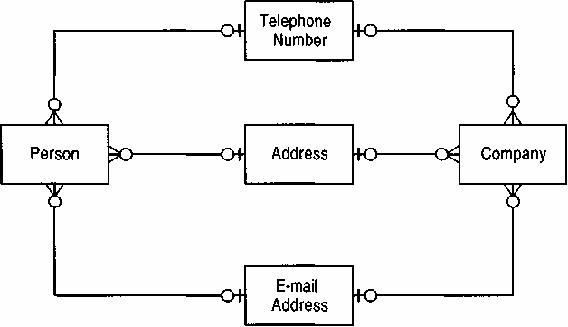

图 2.1 地址簿的初始模型。

Figure 2.1 Initial model of an address book.

该模型展现了个人和组织相似的责任。

This model shows the similar responsibilities of person and organization.

我更倾向于使用“方”这个词。在图 2.2 中，我将“方”定义为个人或组织的超类型。这样，我就可以拥有公司内部各部门，甚至是非正式团队的地址和电话号码。

The term I prefer is party. In Figure 2.2 I define a party as the supertype of a person or organization. This allows me to have addresses and phone numbers for departments within companies, or even informal teams.

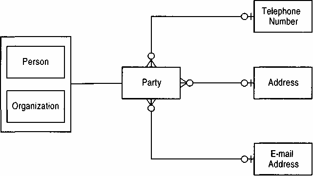

图 2.2 图 2.1 使用政党进行概括。

Figure 2.2 Figure 2.1 generalized using party.

在许多情况下，如果使用“个人”或“组织”，则应使用“一方”。

Party should be used in many situations where person or organization is used.

令人惊讶的是，很多事情都与政党而非个人或组织相关。你会收发信件给个人和组织；我会向个人和组织付款；组织和个人都会开展活动、拥有银行账户、缴纳税款。我认为，这些例子足以证明这种抽象概念的价值。

It is surprising how many things relate to party rather than to person or organization. You receive and send letters to both people and organizational units; I make payments to people and organizations; both organizations and people carry out actions, have bank accounts, file taxes. These examples are enough, I think, to make the abstraction worthwhile.

例如，在英国国家医疗服务体系中，相关方包括：汤姆·凯恩斯医生、圣玛丽医院肾脏科团队、圣玛丽医院、帕克赛德地区卫生局和皇家内科医师学会。

Example In the UK National Health Service, the following would be parties: Dr. Tom Cairns, the renal unit team at St. Mary's Hospital, St. Mary's Hospital, Parkside District Health Authority, and the Royal College of Physicians.

#### 2.2 组织层级

#### 2.2 Organization Hierarchies

我们考虑一家典型的跨国公司：Aroma Coffee Makers, Inc. (ACM)。它由多个运营单元组成，这些运营单元又分为若干区域，区域再分为若干事业部，事业部又分为若干销售办事处。我们可以用图 2.3 来模拟这种简单的组织结构。然而，我并不完全满意这个模型。如果组织结构发生变化，例如为了形成更扁平化的结构而取消区域划分，那么我们就必须修改模型。图 2.4 提供了一个更简单的模型，也更容易修改。图 2.4 中所示的递归关系存在一个问题，那就是它允许事业部成为销售办事处的一部分。我们可以通过定义与层级对应的子类型，并对这些子类型施加约束来解决这个问题。如果组织层级发生变化，我们将修改这些子类型和规则。通常，修改规则比修改模型结构更容易，所以我更倾向于图 2.4 而不是图 2.3。

Let us consider a generic multinational: Aroma Coffee Makers, Inc. (ACM). It has operating units, which are divided into regions, which are divided into divisions which are divided into sales offices. We can model this simple structure using Figure 2.3. This is not a model that I would feel content with, however. If the organization changes, say regions are taken out to provide a flatter structure, then we must alter the model. Figure 2.4 provides a simpler model—one that is easier to change. The danger with the recursive relationship shown in Figure 2.4 is that it allows a division to be part of a sales office. We can deal with this by defining subtypes to correspond with the levels and by putting constraints on these subtypes. Should the organizational hierarchy change, we would alter these subtypes and rules. Usually it is easier to change a rule than to change the model structure, so I prefer Figure 2.4 over Figure 2.3.

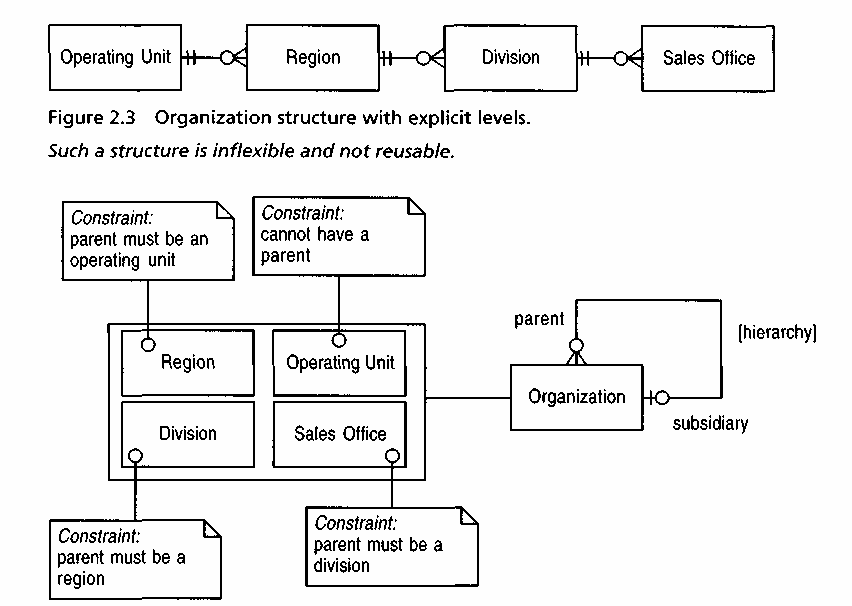

图 2.4 具有层级关系的组织超类型。

Figure 2.4 Organization supertype with hierarchic relationship.

层级关联提供了最大的灵活性。由于层级关系而产生的约束必须 作为子类型的规则添加。

The hierarchic association provides the most flexibility. Constraints due to levels have to be added as rules on the subtypes.

层级结构提供了一定的通用性，但也存在一些局限性，例如它仅支持单一的组织层级。假设ACM公司将其主要咖啡机产品线的售后服务团队与销售办事处关联起来。这些团队采用双重汇报结构：他们既向销售团队汇报，也向各产品系列的售后服务部门汇报，而售后服务部门又向产品类型支持部门汇报。因此，位于波士顿的2176型高容量卡布奇诺咖啡机（每分钟50杯）的售后服务团队，既向波士顿销售办事处汇报，也向2170系列售后服务中心汇报，而2170系列售后服务中心又向高容量意大利咖啡部门汇报，高容量意大利咖啡部门向高容量咖啡产品售后服务部门汇报，高容量咖啡产品售后服务部门最终向咖啡产品售后服务部门汇报。（以上并非虚构！）面对这种情况，我们可以添加第二个层级结构，如图2.5所示。 （还需要更多规则，类似于图 2.4 中的规则，但我将这些规则的添加留给读者作为练习。）目前这种方法效果很好，但随着层级结构的增多，结构将变得笨拙。

The hierarchic structure provides a certain amount of generality but has some limitations, including the fact that it only supports a single organizational hierarchy. Assume that ACM attaches service teams for its major lines of coffee makers to its sales offices. These teams have a dual reporting structure: They report to the sales team as well as the service departments for each product family, which in turn report to product type support units. Thus the service team for the 2176 high-volume cappuccino maker in Boston (50 cappuccinos a minute) reports to the Boston sales office but also to the 2170 family service center, which reports to the high-volume Italian coffee division, which reports to the high-volume coffee products service division, which reports to coffee products service division. (I'm not making this up entirely!) Faced with this situation we can add a second hierarchy, as shown in Figure 2.5. (More rules would be required, similar to those in Figure 2.4, but I will leave the addition of those as an exercise for the reader.) As it stands this approach works well, but as more hierarchies appear the structure will become unwieldy.

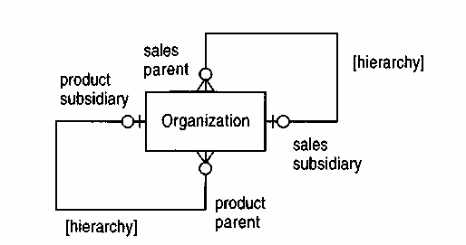

图 2.5 两种组织层级。

Figure 2.5 Two organizational hierarchies.

组织结构的子类型未显示。如果层级过多，很快就会 变得难以管理。

Subtypes of the organization are not shown. If there are many hierarchies, this will soon get out of hand.

#### 2.3 组织结构

#### 2.3 Organization Structure

如果模型看起来包含多个层级，我们可以使用类型化关系，如图 2.6 所示。我们将层级关联转换为类型，并通过使用组织结构类型的不同实例来区分不同的层级。这可以处理上述场景，其中包含组织结构类型的两个实例：销售组织和服务组织。只需添加更多组织结构类型即可添加其他层级。同样，这种抽象方法在适度增加复杂性的情况下为我们提供了更大的灵活性。如果只有两个层级，则不值得这样做，但如果有多个层级，则非常值得。另请注意，组织结构具有时间段；这使我们能够记录组织结构随时间的变化。此外，请注意，我没有将组织结构类型建模为属性——正如我们稍后将看到的，这对于类型属性来说是一个非常重要的因素。

If it looks like the model will have several hierarchies, we can use a typed relationship, as shown in Figure 2.6. We turn the hierarchic associations into a type and differentiate the hierarchies by using varied instances of the organization structure type. This would handle the above scenario with two instances of the organization structure type: sales organization and service organization. Additional hierarchies could be added merely by adding more organization structure types. Again, this abstraction gives us more flexibility for a modest increase in complexity. For just two hierarchies it would not be worth the effort, but for several it would be. Note also that the organization structure has a time period; this allows us to record changes in the organization structure over time. Note further that I have not modeled the organization structure type as an attribute—a very important factor with type attributes, as we will see later.

例如，位于波士顿的2176型大容量卡布奇诺咖啡机服务团队向波士顿销售办事处汇报工作。我们可以将其建模为一个组织结构模型，其中上级是波士顿销售办事处，下级是波士顿2176型服务团队，组织结构类型为直线管理。

Example The service team for the 2176 high-volume cappuccino maker in Boston reports to the Boston sales office. We would model this as an organization structure whose parent is the Boston sales office, subsidiary is the Boston 2176 service team, and organization structure type is line management.

例如，位于波士顿的 2176 型大容量卡布奇诺咖啡机服务团队也隶属于产品支持架构中的 2170 型系列服务中心。我们可以将其建模为一个独立的组织结构，其上级为 2170 型系列服务中心，下级为波士顿 2176 型服务团队，组织结构类型为产品支持。

Example The service team for the 2176 high-volume cappuccino maker in Boston also reports to the 2170 family service center in the product support structure. We would model this as a separate organization structure whose parent is the 2170 family service center, subsidiary is the Boston 2176 service team, and organization structure type is product support.

简化对象结构会更加强调规则。这些规则的形式为：“如果我们有一个组织结构，其类型为销售组织，其子组织为事业部，那么其父组织必定是区域。” 请注意，这些规则是通过引用组织的属性来表达的。

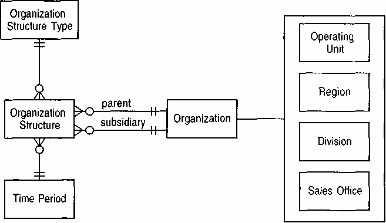

图 2.6 使用类型化关系。

Figure 2.6 Using a typed relationship.

组织间的每种关系都由组织结构类型定义。 如果关系众多，这种方式比显式关联更有效。

Each relationship between organizations is defined by an organization structure type. It is better than explicit associations if there are many relationships.

这意味着规则应该基于组织结构制定。然而，这也意味着，如果通过添加新的组织结构类型来扩展系统，就需要修改组织结构中的规则。此外，随着组织结构类型数量的增加，规则会变得非常繁琐。

structure, which implies that the rules should be on the organization structure. However, this means that extending the system by adding a new organization structure type would require changing the rules in the organization structure. Furthermore, the rules would get very unwieldy as the number of organization structure types increases.

规则可以放在组织结构类型上，如图 2.7 所示。特定组织结构类型的所有规则都保存在一个地方，并且很容易添加新的组织结构类型。

The rules can be placed instead on the organization structure type, as shown in Figure 2.7. All the rules for a particular organization structure type are held in one place, and it is easy to add new organization structure types.

然而，如果我们很少更改组织结构类型，却频繁添加新的组织子类型，那么图 2.7 就无法很好地发挥作用。在这种情况下，每次添加组织子类型都会导致规则变更。更好的做法是将规则放在组织子类型上。这里的要点是尽量减少模型变更。因此，我们应该将规则放置在最易变动的区域，并确保这些规则不会影响模型的其他部分。

Figure 2.7 does not work well, however, if we change the organization structure types rarely but add new subtypes of organization frequently. In that case each addition of a subtype of organization would cause rule changes. It is better to place the rules on the subtypes of the organization. The general point here is to minimize the model changes that occur. Thus we should place the rules in the most volatile area in such a way that need not touch other parts of the model.

**建模原理**

**Modeling Principle**

*设计一个模型，使得模型最频繁的修改只会导致最少类型的数据发生变化。*

*Design a model so that the most frequent modification of the model causes changes to the least number of types.*

#### 2.4 问责制

#### 2.4 Accountability

图 2.7 本质上展示了一个组织根据既定规则在一段时间内与另一个组织建立关系。每当对组织做出任何陈述时，都值得考虑以下问题：

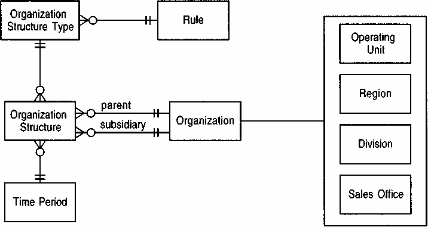

图 2.7 向图 2.6 添加规则。

Figure 2.7 Adding a rule to Figure 2.6.

该规则强制执行一些限制，例如销售办事处必须向分公司汇报。

The rule enforces constraints such as sales offices reporting to divisions.

同样的道理也适用于人。在这种情况下，我会问：“人们能否根据既定规则，在一段时间内与组织或其他人员建立关系？”答案当然是肯定的，因此我可以而且应该将图 2.7 中的概念抽象化，应用于某个主体。我将这种新的抽象概念命名为“责任”，如图 2.8 所示。

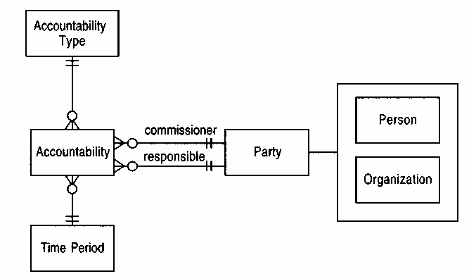

图 2.8 问责制。

Figure 2.8 Accountability.

使用第三方机构可以确保问责制涵盖广泛的各方责任， 包括管理、雇佣和合同。

Using a party allows accountability to cover a wide range of interparty responsibilities, including management, employment, and contracts.

例如，约翰·史密斯在ACM公司工作。这可以通过建立问责制模型来体现，其中ACM公司是委托人，约翰·史密斯是责任方，问责类型是雇佣关系。

Example John Smith works for ACM. This can be modeled by an accountability whose commissioner is ACM, responsible party is John Smith, and accountability type is employment.

例如，约翰·史密斯是波士顿 2176 服务团队的经理。这可以建模为一种问责制，其类型为经理，约翰·史密斯对波士顿 2176 服务团队负责。

Example John Smith is the manager of the Boston 2176 service team. This can be modeled as an accountability whose type is manager, with John Smith responsible to the Boston 2176 service team.

例如，马克·瑟兹是皇家内科医师学会的成员。这可以建模为一种问责制，其类型为专业注册，马克·瑟兹对皇家内科医师学会负责。

Example Mark Thursz is a member of the Royal College of Physicians. This can be modeled as an accountability whose type is professional registration, with Mark Thursz responsible to the Royal College of Physicians.

例如，约翰·史密斯同意马克·瑟兹为其进行内窥镜检查。这可以建模为一种问责制，其类型为患者同意，马克·瑟兹对约翰·史密斯负责。

Example John Smith gives his consent to Mark Thursz to perform an endoscopy. This can be modeled as an accountability whose type is patient consent, with Mark Thursz responsible to John Smith.

例如，圣玛丽医院与帕克赛德地区卫生局签订了一份合同，在1996/97年度开展内窥镜检查。这可以建模为一项责任，其类型为内窥镜服务，圣玛丽医院对帕克赛德负责。责任期限为1996年1月1日至1997年12月31日。责任的子类型可以提供更多信息，例如合同涵盖哪些手术以及在合同期内应完成多少例手术。

Example St. Mary's Hospital has a contract with Parkside District Health Authority to perform endoscopies in 1996/97. This can be modeled as an accountability whose type is endoscopy services, with St. Mary's Hospital responsible to Parkside. The time period on the accountability would be January 1, 1996, to December 31, 1997. A subtype of accountability could provide additional information, such as which operations were covered and how many should be performed during the contract's duration.

**建模原理**

**Modeling Principle**

*在为具有超类型的类型定义特性时，请考虑将特性放在超类型上是否有意义。*

*Whenever defining features for a type that has a supertype, consider whether placing the features on the supertype makes sense.*

正如示例所示，从组织结构抽象到问责制，可以引入一系列其他情况，这些情况都可以被该模型捕捉。然而，模型的复杂性并未增加。基本模型的结构与图 2.7 相同；唯一的区别在于用“参与方”代替了“组织”。

As the examples indicate, abstracting from organization structure to accountability introduces a wide range of additional situations that can be captured by the model. The complexity of the model has not increased, however. The basic model has the same structure as Figure 2.7; the only change is that of using party instead of organization.

#### 2.5 问责知识水平

#### 2.5 Accountability Knowledge Level

然而，问题在于，问责类型远多于组织结构类型，这增加了复杂性。因此，定义问责类型的规则也会变得更加复杂。

Complexity has been introduced, however, in that there are many more accountability types than there would be organization structure types. The rules for defining accountability types would thus become more complex.

引入知识层可以管理这种复杂性。知识层将模型分为两个部分：操作层和知识层。操作层包括责任主体、参与方及其相互关系。知识层包括责任类型、参与方类型及其相互关系，如图 2.9 所示。

This complexity can be managed by introducing a knowledge level. Using a knowledge level splits the model into two sections: the operational and knowledge levels. The operational level consists of accountability, party, and their interrelationships. The knowledge level consists of accountability type, party type, and their interrelationships, as shown in Figure 2.9.

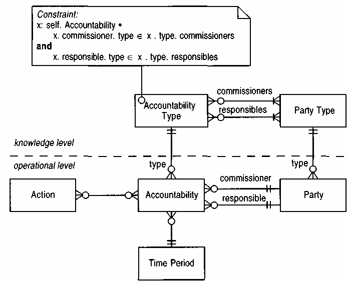

图 2.9 知识和操作层面的问责制。

Figure 2.9 Knowledge and operational levels of accountability.

知识层对象定义了操作层 对象的法律配置。责任关系只能在符合相应责任类型和参与方类型的各方之间建立。

The knowledge level objects define the legal configurations of operational level objects. Accountabilities can only be created between parties according to corresponding accountability types and party types.

问责制（实际参与方之间的联系）受到问责类型和参与方类型之间联系的制约。

accountability (links between actual parties) are constrained by the links between accountability type and party type.

例如，区域会被细分为若干部门。这种划分是通过一种问责制的区域结构来实现的，其中专员是区域，负责人是部门。

Example Regions are subdivided into divisions. This is handled by an accountability type of regional structure whose commissioners are regions and responsibles are divisions.

例如，患者同意被定义为一种问责类型，其委托人是患者，责任人是医生。

Example Patient consent is defined as an accountability type whose commissioners are patients and responsibles are doctors.

注意，映射到政党类型取代了对政党的子类型化。这是 Odell [3] 所说的“强类型”的一个例子，当映射定义了子类型时就会出现强类型。政党类型与其子类型紧密相关，因为子类型区域的类型必须与政党类型区域相同。从概念上讲，您可以将政党类型的实例视为与政党的子类型相同的对象，尽管这在主流编程语言中无法直接实现。因此，政党类型是政党的强类型。通常，我们只需要映射或子类型化中的一个即可。

Note how mapping to the party type replaces subtyping of the party. This is an example of what Odell [3] refers to as a power type, which occurs when a mapping defines subtypes. The party type is closely linked to the subtypes of party in that the subtype region must have its type as the party type region. Conceptually you can consider the instance of the party type to be the same object as the subtype of party, although this cannot be directly implemented in mainstream programming languages. The party type is then a power type of party. Often we need only one of either the mapping or the subtyping.

然而，如果子类型具有特定行为，且幂类型具有自身特征，则既需要子类型，也需要到幂类型的映射。（Odell 对此情况有特殊的符号表示法[3]。）

However, if the subtypes have specific behavior and the power type has its own features, then both subtypes and mapping to the power type are needed. (Odell has a special notation for this case [3].)

知识层和运营层之间的这种对应关系虽然相似但不完全相同，因为母公司和子公司之间的映射在知识层是多值的，而在运营层则是单值的。这是因为运营层记录的是实际的责任主体，而知识层记录的是责任类型的允许主体类型。这种利用多值知识映射来表示单值运营映射的允许类型的模式很常见。

This reflection between the knowledge and operational levels is similar but not identical, in that the parent and subsidiary mappings are multivalued at the knowledge level but single-valued at the operational level. This is because the operational level records the actual party for the accountability, while the knowledge level records the permissible party types for the accountability type. This use of a multivalued knowledge mapping to show permissible types for a single-valued operational mapping is a common pattern.

知识层和操作层是模型中常见的特征，尽管两者之间的区别通常并未明确指出。我之所以明确区分这两个层级，是因为我发现这有助于我在建模时理清思路。本书中有很多关于操作层和知识层的示例，尤其是在第三章。

Knowledge and operational levels are a common feature of models, although the difference between the levels is often not made explicitly. I make the divisions explicit because I find this helps to clarify my thinking when modeling. There are lots of examples of operational and knowledge levels in this book, particularly in Chapter 3.

**建模原理**

**Modeling Principle**

*将模型明确划分为操作层和知识层。*

*Explicitly divide a model into operational and knowledge levels.*

许多数据建模人员使用“元模型”一词来描述知识层。我对这种术语并不完全认同。元模型也可以定义建模技术。因此，元模型包含类型、关联、子类型和操作等概念（例如 Rational Software 的统一方法 [ I ] 的元模型）。知识层实际上并不属于这一范畴，因为它没有描述操作层的符号。因此，我仅使用“元模型”一词来描述描述模型语言（符号语义）的模型。

A lot of data modelers use the term meta-model to describe the knowledge level. I am not entirely comfortable with this terminology. Meta-model can also define the modeling technique. Thus a meta-model includes concepts such as type, association, subtyping, and operation (such as the meta-models of Rational Software's Unified Method [ I ] ) . The knowledge level does not really fall into that category because it does not describe the notation for the operational level. I thus only use the term meta-model to describe a model that describes the language (semantics of notation) for a model.1

问责制代表着相当深奥的抽象概念，就像攀登高峰一样，我们应该在出现高原反应之前停下来评估自身状况。尽管对象模型结构非常简单，但大量知识却隐藏在知识层实例中。因此，要使其有效运作，仅仅实现对象模型是不够的；知识层也必须实例化。实例化知识层实际上就是配置系统，这是一种受限的、因而也更简单的编程形式。然而，它仍然是编程，所以您应该考虑如何对其进行测试。

Accountability represents some pretty heady abstraction and as in any climb we should stop and take stock before altitude sickness sets in. Although we have a very simple structure in the object model, a lot of knowledge is buried in the instances of the knowledge level. Thus to make this work it is not enough to implement the object model; the knowledge level must also be instantiated. Instantiating the knowledge level is effectively configuring the system, which is a constrained, and thus simpler, form of programming. It is still programming, however, so you should consider how you are going to test it.

丰富的知识层次也会影响系统间的通信。如果两个系统要进行通信，它们不仅必须共享对象模型，还必须拥有相同的知识对象（或者至少知识层次之间存在某种等价性，如第 5.4 节所述）。最终，一切都归结于此。

当然，如果我定义了一个图表，展示了责任类型和参与方类型的实例，那么知识层级就充当了该图表的元模型。当责任类型错综复杂时，这种图表会非常有用。

Of course, if I defined a diagram that showed instances of accountability type and party type, then the knowledge level would act as the meta-model for that diagram. This kind of diagram can be useful if there is a com plicated web of accountability types.

归根结底，如果问责类型数量众多，是使用图 2.9 的结构更简便，还是在图 2.5 的基础上，为每种问责类型添加一个关联关系更简便？问题的复杂性无法避免；我们只能思考，在兼顾类型结构和知识对象的前提下，哪种模型更为简洁。

与其他任何关系类型一样，我们需要谨慎，避免将其视为涵盖双方之间所有关系的万能灵药。例如，亲生父母就不适合作为责任类型的一个例子，因为双方都不对彼此负责，也没有固有的时间期限；但法定监护人则符合这一条件。

We need to be careful, as with any typed relationship, that this does not become a catch-all for every relationship between two parties. For example, biological parent would not fit as an instance of an accountability type because neither party is responsible to the other, nor is there an inherent time period; legal guardian would fit, however.

#### 2.6 政党类型概括

#### 2.6 Party Type Generalizations

该模型目前的功能已经相当强大，但一些有用的变体可以进一步增强其灵活性。这些变体适用于任何采用知识/操作分离的模型。

The model as it stands is quite powerful, but some useful variations will add even more flexibility. These variations are useful with any model that uses a knowledge/operational split.

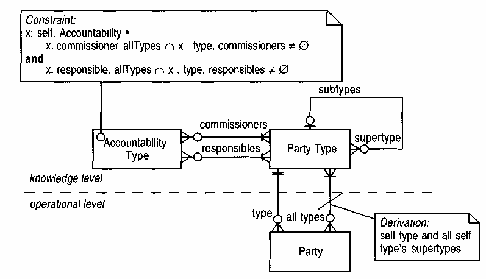

图 2.10 允许政党类型拥有子类型和超类型。

Figure 2.10 Allowing party types to have sub- and supertypes.

对政党类型进行概括，可以更容易地定义知识水平。

Adding generalization to party types makes it easier to define the knowledge level.

对参与方类型的泛化方式与对类型的泛化方式类似。泛化会导致对问责类型的约束发生变化，从而同时考虑参与方的类型（来自类型映射）和超类型（来自所有类型映射）。

图 2.10 展示了参与方类型的单一继承层次结构。通过允许超类型映射为多值，可以支持多重继承。此外，图 2.10 仅支持单一分类。这意味着，如果 Edwards 医生既是全科医生又是儿科医生，我们只能通过创建一个特殊的“全科医生/儿科医生”参与方类型来记录这一点，并将全科医生和儿科医生都作为其超类型。多重分类允许在参与方类型的泛化结构之外，为参与方赋予多个参与方类型。这可以通过允许参与方的类型映射为多值来实现。

Figure 2.10 provides a single inheritance hierarchy on party type. Multiple inheritance can be supported by allowing the supertype mapping to be multivalued. In addition, Figure 2.10 only supports single classification. This means that if Dr. Edwards is both a GP and a pediatrician, we can record that only by creating a special GP/pediatrician party type, with both GP and pediatrician as supertypes. Multiple classification allows party to be given multiple party types outside of the generalization structure of party type. This can be done by allowing the type mapping on party to be multivalued.

关于知识层面和操作层面之间相互关系的许多讨论，与建模元模型中对象和类型之间的关系类似。

Much of the discussion about the interrelationships between the knowledge level and operational level is similar to the relationships between object and type in a modeling meta-model.

#### 2.7 层级问责制

#### 2.7 Hierarchic Accountability

问责制所提供的灵活结构，需要付出更多努力来强制执行某些类型的问责制约束。例如，图 2.3 所示的组织结构定义了一系列严格的层级：运营单元划分为区域，区域划分为事业部，事业部划分为销售办事处。虽然可以定义区域结构的问责制类型，但我们如何才能强制执行图 2.3 中所示的严格规则呢？

The flexible structure that accountabilities provide requires more effort to enforce the constraints of some accountability types. For example, the organization structure shown in Figure 2.3 defines a strict series of levels: operating units are divided into regions, that are divided into divisions that are divided into sales offices. It is possible to define an accountability type of regional structure, but how can we enforce the strict rules of Figure 2.3?

第一个问题是，图 2.3 描述的是一个层级结构。然而，现有的问责模型并没有强制执行这种层级结构的规则。这个问题可以通过提供一个带有附加约束的问责类型子类型来解决，如图 2.11 所示。该约束与问责类型的常规约束共同作用，以强制执行操作层级结构的层级性。类似的问责类型子类型也可用于强制执行有向无环图结构。

The first issue is that Figure 2.3 describes a hierarchic structure. The accountability models do not have a rule to enforce such a hierarchy. This can be addressed by providing a subtype of accountability type with an additional constraint, as shown in Figure 2.11. This constraint acts with the usual constraint on accountability types to enforce the hierarchic nature of the operational level structure. A similar accountability type subtype can be used to enforce a directed acyclic graph structure.

利用图 2.11，我们可以通过一系列责任类型来支持图 2.3 所示的案例。例如，责任类型“区域结构级别 1”包含对运营单位负责的区域，“区域结构级别 2”包含对区域负责的部门，依此类推。这种方法虽然可行，但略显笨拙。另一种方法是使用分级责任类型，如图 2.12 所示。在这种情况下，只有一个区域结构责任类型。级别映射将对应于参与方类型列表——运营单位、区域、部门和销售办事处。该模型使得添加新的分级责任类型以及修改需要的级别结构更加容易。层级责任类型捕捉了构成层级结构的各方的责任。

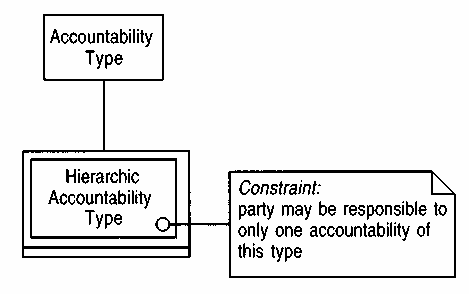

图 2.11 层级责任类型。

Figure 2.11 Hierarchic accountability type.

新增的限制意味着，受此类问责制约束的各方必须 形成一个层级结构。

The added constraint means that the parties linked by accountabilities of this type must form a hierarchy.

层级式问责制体现了固定顺序的各方类型的责任。区域结构问责制则兼具层级性和层次性。

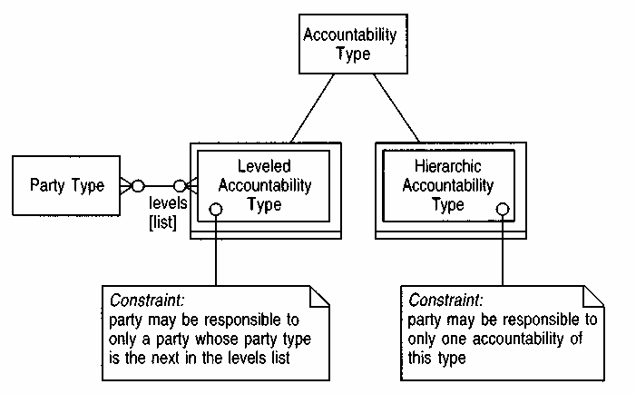

图 2.12 分级问责制类型。

Figure 2.12 Leveled accountability type.

分级责任制支持固定层级，例如销售办事处、部门、区域。

Leveled accountabilities supports fixed levels such as sales office, division, region.

子类型上的约束与责任类型上定义的约束共同作用，遵循契约式设计原则[4]。对于分级责任类型，该约束包含了超类型的约束，实际上使得委托人和负责人之间的映射变得多余。这种思路引出了如图 2.13 所示的模型。值得注意的是，图 2.12 并没有错。分级责任类型是责任类型的一个完全合适的子类型，因为责任类型的约束对分级责任类型仍然有效。委托人和负责人之间的映射也仍然有效，尽管它们源自于层级映射。我倾向于采用图 2.12。分级责任类型并非总是必需的，而且可以很容易地添加而不会违反模型。图 2.12 的另一个优点是使知识/运营关系更加明确。

The constraints applied on the subtypes act with the constraint defined on accountability type, following the principles of design by contract [4]. In the case of the leveled accountability type, the constraint subsumes that of the supertype, and indeed makes the commissioners and responsibles mappings superfluous. This thinking leads to a model along the lines of Figure 2.13. It is important to note that Figure 2.12 is not incorrect. Leveled accountability type is a perfectly good subtype of accountability type because the constraint on accountability type will still hold for leveled accountability type. The commissioners and responsibles mappings will also continue to hold, although they would be derived from the levels mapping. I would be inclined to stick with Figure 2.12. The leveled accountability type is not always needed, and can easily be added without violating the model. Figure 2.12 also has the advantage of making the knowledge/operational relationship more explicit.

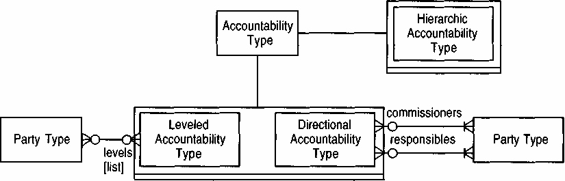

图 2.13 重新平衡问责类型的子类型。

Figure 2.13 Rebalancing the subtypes of accountability type. A

更好的组织问责层级结构的方式。

better way of organizing the accountability type hierarchy.

#### 2.8 操作范围

#### 2.8 Operating Scopes

问责制本身提供了一种描述各方之间关系的有效方式。问责制的类型描述了他们之间的关系。然而，通常还有其他细节可以更深入地阐释问责制的含义。例如，一位医生可能受雇于伦敦东南部，担任肝脏外科医生，并在1997年实施了20例肝移植手术。又如，一家医院的糖尿病护理团队可能受红盾健康管理组织（Red Shield HMD）委托，为马萨诸塞州西部地区的胰岛素依赖型糖尿病患者提供护理服务。

Accountability, as it stands, provides a valuable way of describing how parties relate to each other. The type of accountability describes what kind of relationship they have. There are usually other details, however, that describe more of the meaning of accountability. Consider a doctor who might be employed as a liver surgeon to carry out 20 liver transplants for southeast London in 1997. A diabetic care team at a hospital might be asked to care for insulin-dependent diabetes patients in western Massachusetts for the Red Shield HMD (Health Management Organization).

如图 2.14 所示，这些细节构成了问责的运作范围。每个运作范围都界定了责任方承担的部分责任后果。抽象地列举运作范围的所有属性是困难的。因此，我们可以看到，问责具有若干运作范围，每个运作范围都是描述其具体特征的子类型。

Such details are the operating scopes of accountability, as shown in Figure 2.14. Each operating scope defines some part of consequences of accountability on the responsible party. It is difficult to enumerate the attributes of an operating scope in the abstract. Thus we see that accountability has a number of operating scopes, each of which is some subtype that describes the actual characteristics.

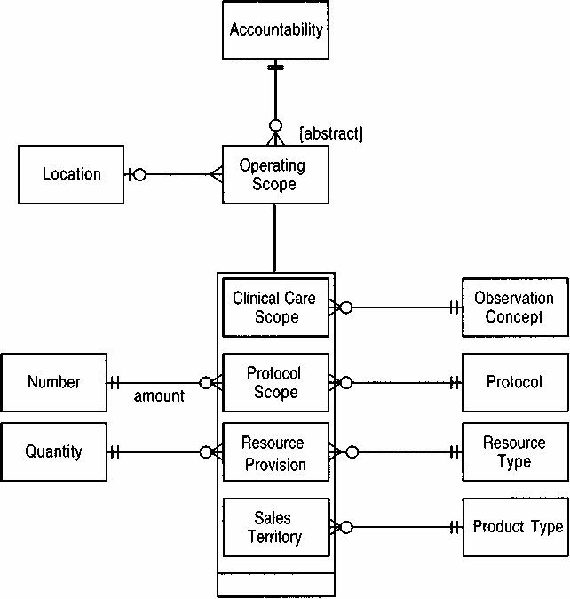

图 2.14 操作范围。

Figure 2.14 Operating scope.

运营范围界定了在建立责任时所承担的职责 。它们可以用于职位描述。

Operating scopes define the responsibilities that are taken on when an accountability is created. They can be used for job descriptions.

例如，一位负责每年在伦敦东南部进行 20 例肝移植手术的肝脏外科医生，其雇佣责任范围协议包含 20 例手术、肝移植手术协议以及伦敦东南部地区。

Example A liver surgeon who is responsible for 20 liver transplants a year in southeast London has a protocol scope on employment accountability with amount of 20, protocol of liver transplant, and location of southeast London.

例如，一个糖尿病护理团队对红盾保险公司负有责任。该责任涵盖的临床护理范围是针对胰岛素依赖型糖尿病，服务地点位于马萨诸塞州西部。

Example A diabetic care team has accountability with Red Shield. This accountability would have a clinical care scope whose observation concept is insulin-dependent diabetes and location is western Massachusetts.

例如， ACM与印尼咖啡出口商（ICE）签订了一份合同，约定在一年内向其出口3000吨爪哇咖啡和2000吨苏门答腊咖啡。该合同规定了ACM和ICE之间的责任，期限为一年，并包含两项资源条款：每年3000吨爪哇咖啡和每年2000吨苏门答腊咖啡。

Example ACM has a contract with Indonesian Coffee Exporters (ICE) for 3000 tons of Java and 2000 tons of Sumatra over the course of a year. This is described by accountability between ACM and ICE with a year's time period and two resource provisions: 3000 tons/ year of Java and 2000 tons/year of Sumatra.

例如，约翰·史密斯是ACM公司1100和2170系列大容量咖啡机的销售商。他在新英格兰地区销售1100和2170两种型号，在纽约地区销售2170型号。他受雇于ACM公司，负责新英格兰地区1100型号、新英格兰地区2170型号和纽约地区2170型号的销售工作。

Example John Smith sells the 1100 and 2170 families of high-volume coffee maker for ACM. He sells both the 1100 and 2170 in New England and sells the 2170 in New York. He has employment accountability to ACM with sales territories for 1100 in New England, 2170 in New England, and 2170 in New York.

在为特定组织使用操作范围时，您需要识别现有的操作范围类型及其属性。虽然很难抽象地概括操作范围，但位置是一个常见因素。如果操作范围的子类型很多，它们可能会形成自己的继承层次结构。在特别复杂的情况下，您可能会看到在知识层级放置操作范围类型 2，以表明哪些问责类型可以拥有哪些操作范围类型。

When using operating scopes for a particular organization, you need to identify the kinds of operating scopes that exist and the properties for them. It is very difficult to generalize about operating scopes in the abstract, but location is a common factor. The subtypes of operating scope may form an inheritance hierarchy of their own if there are many of them. In particularly complex cases you might see an operating scope type2 placed on the knowledge level to show which accountability types can have which operating scope types.

#### 2.9 帖子

#### 2.9 Post

通常情况下，一个人的工作范围——包括其职责和许多责任——会事先在岗位描述中明确界定。当一个人离职时，接替者可能会继承全部职责。这些职责与岗位挂钩，而非与个人挂钩。

Often the operating scopes of a person—their responsibilities, including many of their accountabilities—are defined in advance as that person's job description. When a person leaves a job, the replacement may inherit a full set of responsibilities. These responsibilities are tied to the job rather than the person.

我们可以通过引入“岗位”这一第三方子类型来处理这种情况，如图 2.15 所示。任何与工作本身相关的、无论由谁担任的职责都与岗位相关联。一个人担任岗位，就意味着他/她对岗位负有责任。也就是说，一个人在其任职期间内，必须履行岗位的各项职责。

We can deal with this situation by introducing the post as a third subtype of party, as shown in Figure 2.15. Any responsibilities that are constant to the job, whoever occupies it, are attached to the post. A person fills a post by having an accountability to the post. The notion is that a person is responsible for the responsibilities of the post for the period of time that they are appointed to the post.

例如，保罗·史密斯是高产量产品开发团队的负责人。我们可以将其描述为设立一个高产量产品开发团队负责人的职位。该职位对高产量产品开发团队（一方）负有管理责任。保罗·史密斯对该职位负有单独的责任（任命类型）。

Example Paul Smith is the head of the high-volume product development team. We can describe this by having a post for the head of the high-volume product development team. This has a management accountability with the high-volume product development team (a party). Paul Smith has a separate accountability (of type appointment) to this post.

例如，某医院的移植外科医生岗位职责要求每年完成50例肾移植和20例肝移植手术。该岗位需对医院和相关规程负责，完成50例肾移植和20例肝移植手术。

Example The transplant surgeon post at a hospital has in its job description the requirement to do 50 renal and 20 liver transplants in a year. This post has an accountability with the hospital and protocol scopes for 50 renal transplants and 20 liver transplants.

不应频繁使用帖子。帖子会增加操作层面的复杂性，因为它引入了额外的间接层级。仅在必要时才使用帖子。

2 在这种情况下，操作范围类型的实例必须与操作范围的子类型相匹配。因此，操作范围类型是操作范围的幂类型[3]。

2 In this case the instances of operating scope type must match the subtypes of operating scope. Operating scope type is thus a power type [3] of operating scope.

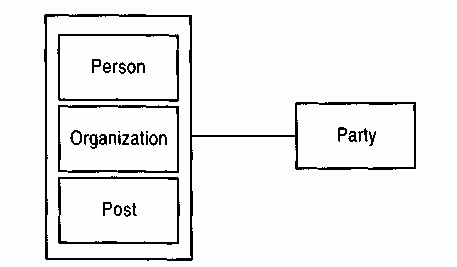

图 2.15 后。

Figure 2.15 Post.

当职责和范围由职位本身界定，且不 随职位持有者变更而改变时， 便使用职位这一概念。职位任命本身就是一种职责。

Posts are used when accountabilities and scopes are defined by the post and do not change when the holder of the post changes. Appointments to posts are accountabilities.

当岗位职责较为固定且人员更迭频繁时，岗位就显得尤为重要。而如果所有职责都能由一人承担，那么岗位就不是必需的。

#### 参考

#### References

[figure not shown]

### 第三章 观察与测量

### Chapter 3. Observations and Measurements

许多计算机系统会记录现实世界中物体的信息。这些信息以记录、属性、对象以及其他各种表示形式进入计算机系统。通常的做法是将信息记录为对象的属性。例如，我的体重是185磅，这一事实会被记录在“人”这一类型的属性中。本章将探讨这种方法的不足之处，并提出更完善的方法。

Many computer systems record information about objects in the real world. This information finds its way into computer systems as records, attributes, objects, and various other representations. The typical route is to record a piece of information as an attribute to an object. For example, the fact that I weigh 185 pounds would be recorded in an attribute of a person type. This chapter examines how this approach fails and suggests more sophisticated approaches.

我们首先讨论数量（3.1）——一种将数字与其关联的单位结合起来的类型。通过结合数字和单位，我们可以更精确地对世界进行建模。将数量及其单位建模为对象后，我们还可以使用转换比率（3.2）来描述如何转换数量。数量模式可以通过使用复合单位（3.3）来扩展，复合单位用其组成部分显式地表示复杂的单位。几乎所有计算机系统都需要数量；货币值应始终使用这种模式来表示。

We begin by discussing quantity (3.1)—a type that combines a number with the unit that is associated with it. By combining numbers and units, we are able to model the world more exactly. With quantities and their units modeled as objects, we can also describe how to convert quantities with a conversion ratio (3.2). The quantity pattern can be extended by using compound units (3.3), which represent complex units explicitly in terms of their components. Quantities are required for almost all computer systems; monetary values should always be represented using this pattern.

数量可以用作对象的属性，用于记录有关对象的信息。然而，当属性数量非常庞大，导致类型过于臃肿时，这种方法就会失效。在这种情况下，可以使用测量（3.4）将测量值视为独立的对象。当需要保存有关单个测量值的信息时，这种模式也很有用。本章将开始介绍操作层和知识层（参见2.5节）的应用。

Quantities can be used as attributes of objects to record information about them. This approach begins to break down, however, when there is a very large number of attributes that can bloat the type with attributes and operations. In these situations measurement (3.4) can be used to treat measurements as objects in their own right. This pattern is also useful when you need to keep information about individual measurements. Here we begin to see the use of operational and knowledge levels (see Section 2.5) in this chapter.

测量使我们能够记录定量信息。观察（3.5）将这种模式扩展到定性信息，从而允许在知识层面上对观察概念（3.6）进行细分。记录观察方案（3.7）通常也至关重要，以便临床医生更好地解读观察结果，并确定观察的准确性和敏感性。

Measurements allow us to record quantitative information. Observation (3.5) extends this pattern to deal with qualitative information and thus allows subtyping observation concepts (3.6) in the knowledge level. It is also often essential to record the protocol (3.7) for an observation so that clinicians can better interpret the observation as well as determine the accuracy and sensitivity of the observation.

一些小的模式可以扩展观察范围。观察发生的时间与记录时间之间的差异可以通过双重时间记录法（3.8）来捕捉。通常，记录已被证明不正确的观察结果非常重要；这就需要对观察结果进行舍弃（3.9）。观察中最棘手的问题在于如何处理确定性，因为记录关于对象的假设通常很重要。主动观察、假设和预测的细分（3.10）是解决这个问题的一种方法。

A number of small patterns extend observation. The difference between the time an observation occurred and when it is recorded can be captured with a dual time record (3.8). Often it is important to keep a record of observations that have been found to be incorrect; this requires a rejected observation (3.9). The biggest headache with observation is dealing with certainty, for it is often important to record hypotheses about objects. The subtyping of active observation, hypothesis, and projection (3.10) is one way of dealing with this problem.

许多关于观察结果的陈述都是通过诊断过程得出的。我们根据其他观察结果推断出新的观察结果。关联观察（3.11）可用于记录证据观察结果，以及用于诊断的知识。

Many statements about observations are made using a process of diagnosis. We infer observations based on other observations. Associated observation (3.11) can be used to record the evidence observations, plus the knowledge that was used for the diagnosis.

上述模式是结构性的，用于记录我们的观察结果。为了理解它们的工作原理，有必要考虑观察过程（3.12），该过程可以用基于事件的技术进行建模。

The preceding patterns are structural and are used to make records of our observations. To understand how they work, it is useful to consider the process of observation (3.12), which can be modeled with an event-based technique.

很少有哪个行业像医学一样对测量和观察有着如此复杂的要求。本章的模型源自英国国家医疗服务体系（NHS）的“宇宙”（Cosmos）项目[3]，该项目旨在从临床角度对医疗保健进行建模。在这个项目中，由医生、护士和分析师组成的联合团队共同致力于解决一个出了名的难题。我们在此不赘述“宇宙”模型的具体细节，感兴趣的读者可以参考完整的模型[1]。本文中的理念可以移植到其他领域：第四章将探讨如何将其应用于公司金融领域。

Few professions have such complex demands on measurements and observations as medicine. The models in this chapter come from an intense effort in modeling health care from a clinical perspective—the Cosmos project [3] of the UK National Health Service. In this project a joint team of doctors, nurses, and analysts worked together on a notoriously difficult domain. We do not include a pure description of the Cosmos model here. Those interested should refer to the complete model [1]. The ideas here can be transplanted to other areas: Chapter 4 discusses how this was done for corporate finance.

关键概念：数量、单位、测量、观察、观察概念、现象类型、关联函数、被拒绝的观察、假设。

Key Concepts Quantity, Unit, Measurement, Observation, Observation Concept, Phenomenon Type, Associative Function, Rejected Observation, Hypothesis.

#### 3.1 数量

#### 3.1 Quantity

在当前的计算机系统中，记录测量值最简单、最常用的方法是在专门设计的测量字段中记录一个数字，例如图 3.1 所示的格式。这种方法的一个问题是，用数字来表示人的身高并不合适。说我的身高是 6，或者我的体重是 185，这到底是什么意思？为了理解这些数字的含义，我们需要单位。一种方法是在关联名称中引入单位（例如，体重单位为磅）。单位可以明确数字的含义，但这种表示方式仍然显得笨拙。这种方法的另一个问题是，记录者必须使用正确的单位。如果有人告诉我他们的体重是 80 公斤，我应该记录什么？理想情况下，一份好的记录，尤其是在医学领域，应该准确地记录测量值——不多也不少。然而，即使是确定性的单位转换，也无法完全做到这一点。

The simplest and most common way of recording measurements in current computer systems is to record a number in a field designed for a particular measurement, such as the arrangement shown in Figure 3.1. One problem with this method is that using a number to represent a person's height is not very appropriate. What does it mean to say that my height is 6, or that my weight is 185? To make sense of the number, we need units. One way of doing this is to introduce a unit into the name of the association (for example, weight in pounds). The unit clarifies the meaning of the number, but the representation remains awkward. Another problem with this technique is that the recorder must use the correct units for the information. If someone tells me their weight is 80 kilograms, what am I to record? Ideally a good record, especially in medicine, records exactly what was measured—no more, no less. A conversion, however deterministic, does not follow that faithfully.

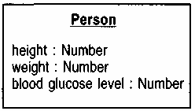

图 3.1 数字属性。

Figure 3.1 Number attribute.

这种方法没有指定单位。

This approach does not specify the units.

在此背景下，数量是一个非常有用的概念。图 3.2 展示了一种结合了数字和单位的对象类型，例如 6 英尺或 180 磅。数量包含相应的算术和比较运算。例如，加法运算允许像加数字一样轻松地将数量相加，但会检查单位，以避免将 34 英寸加到 68 公斤上。数量是一个“完整值”[2]，用户界面可以解释并显示它（简单的打印操作即可显示数字和单位）。这样，数量很快就能像整数或日期一样，成为一种实用且应用广泛的属性。

In this context a very useful concept is that of quantity. Figure 3.2 shows an object type that combines number and units, for example, 6 feet or 180 pounds. Quantity includes appropriate arithmetical and comparative operations. For example, an addition operation allows quantities to be added together as easily as numbers but checks the units so that 34 inches are not added to 68 kilograms. Quantity is a "whole value" [2] that the user interface can interpret and display (a simple print operation can show the number and the unit). In this way quantity soon becomes as useful and as widely used an attribute as integer or date.

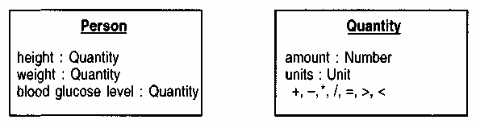

图 3.2 使用数量作为属性的测量。

Figure 3.2 Measurements as attributes using quantity.

凡需使用单位的地方，都应使用数量。

Quantity should always be used where units are required.

例如，我们可以将 185 磅的重量表示为数量 185，单位为磅。

Example We can represent a weight of 185 pounds as a quantity with amount of 185 and unit of pounds.

货币价值也应该以数量的形式表示（本书中我使用“货币”一词），并以某种货币作为单位。使用数量，您可以轻松处理多种货币，而不是局限于单一货币（要是我的个人理财程序也能做到这一点就好了！）。货币对象还可以控制金额的表示方式。如果使用浮点数来表示货币价值，金融系统中经常会出现舍入问题；货币数量可以强制使用定点数来表示金额属性。

Monetary values should also be represented as quantities (I use the term money in this book), using a currency as the unit. With quantities you can easily deal with multiple currencies, rather than being tied to a single currency (if only my personal finance program did that!). Money objects can also control the representation of the amount. Often rounding problems occur in financial systems if floating point numbers are used to represent monetary values; monetary quantities can enforce the use of fixed point numbers for the amount attribute.

例如， 80 美元可以用数量 80 和单位美元来表示。

Example $80 would be represented as a quantity with amount of 80 and units of US dollars.

数量的使用是面向对象分析的一个重要特征。许多建模方法区分属性和关联。关联将模型中的类型连接起来，而属性则根据某种属性类型包含特定的值。问题是，是什么使某个东西成为属性而不是关联？通常，属性是大多数软件环境中典型的内置类型（例如整数、实数、字符串、日期等等）。像数量这样的类型并不符合这种在属性和关联之间进行选择的方式。一些建模者认为应该用关联来建模数量（因为它不是典型的内置类型），而另一些建模者则建议使用属性（因为它是一个自包含的、广泛使用的类型）。在概念建模中，具体采用哪种方式并不重要，重要的是要寻找并使用像数量这样的类型。由于我不区分属性和映射，所以我不参与这场争论。（我之所以强调这一点，是因为我发现像数量这样的类型在我看到的大多数模型中都明显缺失。）

The use of quantity is an important feature of object-oriented analysis. Many modeling approaches make a distinction between attributes and associations. Associations link types in the model, and attributes contain some value according to some attribute type. The question is, what makes something an attribute rather than an association? Usually attributes are the typical built-in types of most software environments (integer, real, string, date, and so on). Types such as quantity do not fit into this way of choosing between attribute and association. Some modelers say quantity should be modeled with an association (because it is not a typical built-in type), while other modelers recommend an attribute (because it is a self-contained, widely used type). In conceptual modeling it doesn't really matter which way you do it, the important thing is that you look for and use types such as quantity. Since I don't distinguish between attributes and mappings, I don't get into this argument. (I'm laboring this point because I find types such as quantity conspicuously absent from most of the models I see.)

**建模原理**

**Modeling Principle**

*当多个属性与可能在多种类型中使用的行为相互作用时，将这些属性合并成一个新的基本类型。*

*When multiple attributes interact with behavior that might be used in several types, combine the attributes into a new fundamental type.*

#### 3.2 转化率

#### 3.2 Conversion Ratio

我们可以充分利用模型中显式表示的单位。单位的首要作用是允许我们将数量从一种单位转换为另一种单位。如图 3.3 所示，我们可以使用单位之间的转换比率对象，然后为数量赋予一个操作 `convertTo(Unit)`，该操作可以返回给定单位下的新数量。此操作会检查转换比率，以确定是否可以从接收对象的数量推导出目标数量。

We can make good use of units represented explicitly in the model. The first service that units can perform is to allow us to convert quantities from one unit to another. As shown in Figure 3.3 we can use conversion ratio objects between units and then give quantity an operation, convertTo (Unit), which can return a new quantity in the given unit. This operation looks at the conversion ratios to see if a path can be traced from the receiving object's quantity to the desired quantity.

例如，我们可以通过定义英尺到英寸的转换比率（数字为 12）来在英寸和英尺之间进行转换。

Example We can convert between inches and feet by defining a conversion ratio from feet to inches with the number 12.

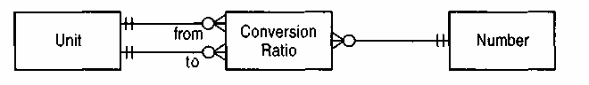

图 3.3 将换算比率添加到单位中。

Figure 3.3 Adding conversion ratios to units.

例如，我们可以通过定义英寸到毫米的转换比率 25.4 来实现英寸和毫米之间的转换。然后，我们可以将此比率与英尺到英寸的转换比率结合起来，从而实现英尺到毫米的转换。

Example We can convert between inches and millimeters by defining a conversion ratio from inches to millimeters with the number 25.4. We can then combine this ratio with the conversion ratio from feet to inches to convert from feet to millimeters.

转换比率可以处理大多数转换，但并非所有转换。例如，摄氏度到华氏度的转换需要比简单的乘法运算更复杂的计算。在这种情况下，需要使用针对特定实例的方法（参见 6.6 节）。

Conversion ratios can handle most but not all kinds of conversion. A conversion from Celsius to Fahrenheit requires a little more than simple multiplication. In this case an individual instance method (see Section 6.6) is required.

如果有很多不同的单位需要转换，我们可以考虑记录单位的量纲。例如，力的量纲是 [MLT2]，对于非国际单位制 (SI) 单位，我们也需要一个标量。有了量纲和标量，我们就可以自动计算转换比率，虽然设置起来需要一些工作。

If we have a lot of different units to convert, we can consider holding the dimensions of a unit. For example, force has dimensions of [MLT2], and we also need a scalar for units that are not S.I. units. With the dimensions and the scalar, we can compute conversion ratios automatically, although it is a bit of work to set it up.

请注意，由于一个月的天数不是恒定的，因此日期和月份之间的时间转换并不准确。

Be aware that time does not convert properly between days and months because the number of days in a month is not constant.

如果转化过程中有多个备选路径，我们可以在测试用例中利用它们。测试应该检查转化在两个方向上是否都能正常工作。

If we have several alternative paths in conversion, we can make use of them in our test cases. The tests should check that the conversions work in both directions.

对于以货币为单位的货币价值而言，其兑换比率并非随时间保持不变。我们可以通过赋予兑换比率属性来指示其适用时间，从而解决这个问题。

For monetary values, whose units are currencies, the conversion ratios are not constant over time. We can deal with this problem by giving the conversion ratios attributes to indicate their time of applicability.

在单位换算时，我们可以使用换算比率（如本文所述）或场景法（如第 9.4 节所述）。如果换算频繁变化，且我需要了解多组一致的换算结果，我会使用场景法。否则，更简单的换算比率模型更为合适。

When converting between units, we can use either conversion ratios, as described here, or scenarios, as described in Section 9.4. I use scenarios if the conversions change frequently and I need to know about many sets of consistent conversions. Otherwise, the simpler conversion ratio is the better model.

#### 3.3 复合单元

#### 3.3 Compound Units

单位可以是原子单位或复合单位。复合单位是由原子单位组合而成的，例如平方英尺或米每秒。复杂的单位换算运算可以利用原子单位的换算比率来转换复合单位。复合单位需要记住所使用的原子单位及其幂。图 3.4 是一个简单的复合单位转换模型示例。请记住，幂可以是正数也可以是负数。

Units can be atomic or compound. A compound unit is a combination of atomic units, such as feet2 or meters per second. A sophisticated conversion operation can use conversion ratios on atomic units to convert compound units. The compound units need to remember which atomic units are used and their powers. Figure 3.4 is an example of a straightforward model that can convert compound units. Remember that the power can be positive or negative.

该模型的一个变体利用包来表示映射关系。与通常的集合不同，包允许我们在映射中多次使用同一个对象，如图 3.5 所示。当关系只有一个数值属性时，包尤其有用。

A variation on this model takes advantage of representing mappings with bags. Unlike the usual sets, bags allow us to use an object more than once in a mapping, as shown in Figure 3.5. Bags are particularly useful when we have a relationship that has a single numeric attribute.

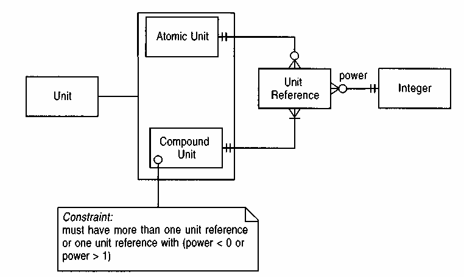

图 3.4 复合单元。

Figure 3.4 Compound units.

该模型可用于研究加速度及类似现象。

This model can be used for acceleration and similar phenomena.

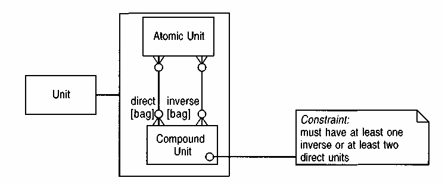

图 3.5 使用包装袋的复合单元。

Figure 3.5 Compound units using bags. This

该模型比图 3.4 更紧凑。

model is more compact than Figure 3.4.

例如，重力加速度可以用一个数值为 9.81 的量来表示，该量是一个复合单位，其直接单位为米，反单位为秒和秒。

Example The acceleration due to gravity can be expressed as a quantity with number 9.81 and a compound unit with direct units of meter and inverse units of seconds and seconds.

图 3.4 和图 3.5 之间的差异并不大。我略微偏爱图 3.5，因为它避免了单位引用——这种引用方式用途不大。对于复合单元的大多数用户来说，选择哪种模型并不重要。只有那些需要将复合单元分解为原子单元的用户才会用到这些模型，而大多数用户只需要一些打印表示。显然，如果我们的方法不允许在映射中使用包，我们就必须使用图 3.4。

The difference between Figures 3.4 and 3.5 is not great. I have a mild preference for Figure 3.5 because it avoids unit reference—a type that does not do much. The choice between these models does not matter to most clients of a compound unit. Only clients that need to break the compound unit down into atomic units are involved, and most of the type's clients would only need some printing representation. Obviously we must use Figure 3.4 if our method does not allow bags in mappings.

#### 3.4 测量

#### 3.4 Measurement

将数量建模为属性可能适用于单个医院科室，该科室每次住院就诊仅收集几十项测量数据。然而，当我们放眼整个医学领域时，会发现一个人可能需要进行数千项测量。如果为每项测量都定义一个属性，则意味着一个人可能需要进行数千次操作——这将导致界面过于复杂，难以处理。一种解决方案是将所有可测量的指标（身高、体重、血糖水平等）视为对象，并引入对象类型“现象类型”，如图 3.6 所示。这样，一个人将拥有多项测量数据，每项测量数据都将一个数量值分配给一个特定的现象类型。现在，每个人只需一个属性即可记录所有测量数据，而处理测量数据的复杂性将转移到查询数千个测量值和现象类型的实例上。我们还可以向测量数据添加更多属性，以记录诸如测量者、测量时间、测量地点等信息。

Modeling quantities as attributes may be useful for a single hospital department that collects a couple of dozen measurements for each in-patient visit. However, when we look across all areas of medicine, we find thousands of potential measurements that could be made on one person. Denning an attribute for each measurement would mean that one person could have thousands of operations—an untenably complex interface. One solution is to consider all the various things that can be measured (height, weight, blood glucose level, and so on) as objects and to introduce the object type phenomenon type, as shown in Figure 3.6. A person would then have many measurements, each assigning a quantity to a specific phenomenon type. The person would now have only one attribute for all measurements, and the complexity of dealing with the measurements would be shifted to querying thousands of instances of measurement and phenomenon type. We could now add further attributes to the measurement to record such things as who did it, when it was done, where it was done, and so on.

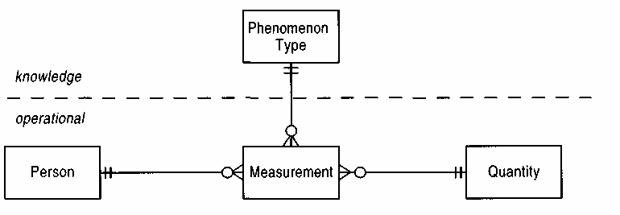

图 3.6 介绍测量和现象类型。

Figure 3.6 Introducing measurement and phenomenon type.

如果大量的测量选项会使模型过于 复杂，那么这种模型就很有用。现象类型是我们已知可以测量的事物。这种知识属于 模型的知识层级。

This model is useful if a large number of possible measurements would make person too complex. The phenomenon types are things we know we can measure. Such knowledge is at the knowledge level of the model.

例如，约翰·史密斯身高 6 英尺，这可以用一个测量来表示，其中人是约翰·史密斯，现象类型是身高，数量是 6 英尺。

Example John Smith is 6 feet tall, which can be represented by a measurement whose person is John Smith, phenomenon type is height, and quantity is 6 feet.

例如，约翰·史密斯的峰值呼气流速（肺部呼出的空气量和速度）为每分钟 180 升。这可以表示为一个测量值，测量对象为约翰·史密斯，现象类型为峰值呼气流速，数值为每分钟 180 升。

Example John Smith has a peak expiratory flow rate (how much air can be blown out of the lungs, how fast) of 180 liters per minute. This can be represented as a measurement whose person is John Smith, phenomenon type is peak expiratory flow rate, and quantity is 180 liters per minute.

例如，一块混凝土样品的强度用每平方英寸4000磅的力表示。这里，人被替换成一块混凝土样品，其测量结果的现象类型是强度，数量是每平方英寸4000磅。

Example A sample of concrete has a strength indicated by a force of 4000 pounds per square inch. Here the person is replaced by a concrete sample with a measurement whose phenomenon type is strength and quantity is 4000 pounds per square inch.

该模型具有一个简单的划分，在后续分析中被证明非常有用。基于此模型，测量是在系统日常运行过程中产生的。然而，现象类型的创建频率要低得多，因为它们代表了关于要测量什么的知识。因此，我们构思了双层模型：操作层由测量组成，知识层由现象类型组成（另见第 2.5 节）。虽然在这个简单的例子中，这两个层级似乎并不重要，但随着我们更深入地探索建模，我们将看到思考这两个层级非常有用。（尽管图 3.6 显示了划分线，但我们在后续的大多数图中都省略了它；不过，我们有一个惯例，即把知识概念绘制在图的顶部。）

This model has a simple division that was found to be very useful in later analysis. Measurements are created as part of the day-to-day operation of a system based on this model. Phenomenon types, however, are created on a much more infrequent basis because they represent the knowledge of what things to measure. The two-level model was thus conceived: the operational level consists of the measurement, and the knowledge level consists of the phenomenon type (see also Section 2.5). Although it does not seem important in this simple example, we will see that thinking about these two levels is useful as we explore modeling more deeply. (Although Figure 3.6 shows the dividing line, we have left it out of most of the following figures; however, we have a convention of drawing knowledge concepts toward the top of the figure.)

**建模原理**

**Modeling Principle**

*操作层面包含那些每天都在变化的概念。它们的配置受到变化频率低得多的知识层面的制约。*

*The operational level has those concepts that change on a day-to-day basis. Their configuration is constrained by a knowledge level that changes much less frequently.*

**建模原理**

**Modeling Principle**

*如果一个类型有许多非常相似的关联/属性/连接，则将所有这些关联都创建为一个新类型的对象。创建一个知识级别类型来区分它们。*

*If a type has many, manysimilar assoc/at/ons, make all of these associations objects of a new type. Create a knowledge level type to differentiate between them.*

我们可以选择将计量单位添加到现象类型中，并使用数字而非数量进行测量。但我更倾向于在测量中保留数量，这样我可以轻松地支持同一现象类型下的多个单位。现象类型中的一组单位可用于检查输入测量值的单位，并为用户提供单位列表以供选择。

We could choose to add the unit of measurement to the phenomenon type and use numbers instead of quantities for the measurement. I prefer to keep quantities on the measurement so that I can easily support multiple units for a phenomenon type. A set of units on a phenomenon type can be used to check the unit of an entered measurement and to provide a list for users to choose from.

#### 3.5 观察

#### 3.5 Observation

正如我们可以对患者做出许多定量描述一样，也有许多重要的定性描述，例如性别、血型以及是否患有糖尿病。由于可能性范围太广，我们不能用属性来描述这些定性信息，因此，类似于测量概念的结构就很有用。

Just as there are many quantitative statements we can make about a patient, there are also many important qualitative statements, such as gender, blood group, and whether or not they have diabetes. We cannot use attributes for these statements because there is such a large range of possibilities, so a construct similar to that for measurement is useful.

考虑记录一个人的性别这一问题，性别只有两个可能的值：男性和女性。我们可以把性别看作是我们正在测量的对象，而男性和女性则是它的两个值，就像任何正数都是一个人身高的有效值一样。由此，我们可以设计一种新的观察类型——类别观察，它类似于测量，但关注的是类别而非数量，如图 3.7 所示。我们还可以设计另一种新的观察类型，作为测量和定性观察的超类型。

Consider the problem of recording a person's gender, which has two possible values: male and female. We can think of gender as being what we are measuring, and male and female are two values for it, just as any positive number is a meaningful value for the height of a person. We can then devise a new type, category observation, which is similar to measurement but has a category instead of quantity, as shown in Figure 3.7. We can also devise another new type of observation that acts as a supertype to a measurement and a qualitative observation.

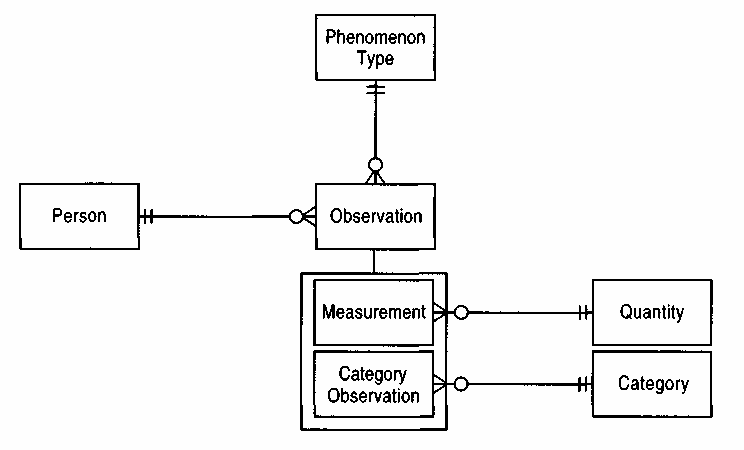

图 3.7 观察结果和类别观察结果。

Figure 3.7 Observations and category observations.

该模型支持定性测量，例如 A 型血。

This model supports qualitative measurements, such as blood group A.

根据图 3.7，我们可以说性别是现象类型的一个实例，而男性和女性是类别的实例。要记录某人是男性，我们创建一个观察记录，其类别为男性，现象类型为性别。

Using Figure 3.7, we can say that gender is the instance of phenomenon type, and male and female are instances of category. To record that a person is male, we create an observation with a category of male and a phenomenon type of gender.

现在我们需要考虑如何记录某些类别只能用于特定的现象类型。例如，“高”、“中等”和“矮”可能是身高这一现象类型的类别，而 A、B、A/B 和 O 可能是血型这一现象类型的类别。这可以通过建立类别与现象类型之间的关系来实现。那么，有趣的问题是类别到现象类型的映射的基数。我们可以问，血型中使用的对象 A 是否可能与多个现象类型相关联？答案当然是肯定的：我们使用 Child-Pugh 评分来评估肝功能，该评分分为 A（良好）、B（中等）和 C（差）三个等级。这就引出了一个问题：我们所说的 A 究竟是什么意思？如果我们仅仅是指由字符“A”组成的字符串，那么这种映射就是多值的，类别与现象类型无关。只有通过定性观察引入某种现象类型时，类别的含义才能明确。另一种方法是将映射设为单值映射，其中类别仅在现象类型的上下文中定义；也就是说，它不是 A，而是血型 A。

We now have to consider how we can record that certain categories can be used only for certain phenomenon types. Tall, Average, and Short might be categories for the phenomenon type height, while A, B, A/B, and O might be categories for the phenomenon type blood group. This could be done by providing a relationship between category and phenomenon type. The interesting question then is the cardinality of the mapping from category to phenomenon type. We might ask, does the object A used in blood group potentially link to more than one phenomenon type? One answer is, of course it does: We grade liver function on the Childs-Pugh scale, which has values A (reasonable), B (moderate), and C (poor). This raises the question of what we mean by A. If we mean merely the string consisting of the character 'A,' then the mapping is multivalued and the category is independent of the phenomenon type. The category's meaning is only clear when a phenomenon type is brought in through a qualitative observation. The alternative is to make the mapping single-valued, where the category is only defined within the context of the phenomenon type; that is, it is not A but blood group A.

这和我们有什么区别呢？单值情况允许我们记录关于类别的有用信息，例如A在肝功能方面优于B，而血型则不存在这种排序。

What difference is this to us? The single-valued case allows us to record useful information about the categories, such as A is better than B with respect to liver function, while no such ordering exists for blood groups.

我对临床流程的初步调查揭示了一个常见的步骤：患者前来就诊，收集患者病情的相关证据，然后由临床医生进行评估。例如，患者可能主诉口渴、体重减轻和尿频（多尿）。这可能导致临床医生诊断为糖尿病。记录这一诊断时，有两点需要注意。首先，仅仅记录患者患有糖尿病是不够的；临床医生还必须明确记录做出此诊断所依据的证据。其次，临床医生并非凭空做出这种推断。随机的证据不能随意组合，推断也并非随意进行。临床医生必须依靠临床知识。

My initial investigations of the clinical process revealed a common sequence: The patient comes to the facility, evidence is collected about the patient's condition, and a clinician makes an assessment. For example, a patient might come in complaining of excessive thirst, weight loss, and frequent urination (polyuria). This would lead a clinician to diagnose diabetes. A couple of things are important about recording this diagnosis. First, it is not sufficient simply to note that the patient has diabetes; the clinician must also explicitly record the evidence used to come up with this diagnosis. Second, the clinician does not make this kind of deduction out of thin air. Random evidence is not assembled into random deductions. The clinician must rely on clinical knowledge.

考虑将此过程融入我们目前已有的模型中。假设患者体重下降。我们可以将其描述为一种“体重变化”现象，并关联了“增加”、“减少”和“稳定”三个类别。类似地，糖尿病也是一种现象，并关联了“存在”和“不存在”两个类别。显然，我们可以通过在观察结果上建立合适的递归关系来记录观察结果之间的联系，如图 3.8 所示。这样，我们就可以记录糖尿病的观察结果与其证据之间的联系。我们还需要记录体重下降与糖尿病之间联系的临床知识。使用图 3.7 所示的模型，我们将难以记录这种联系。“体重变化”现象和“减少”类别只有在进行观察时才会关联。我们需要一种方法来表达即使没有任何观察结果也可能存在的体重下降，并将其置于知识层面。将类别到现象类型的映射设为单值映射即可实现这一点。（3.11 节将对此进行更深入的讨论。）

Consider placing this process in the model we have so far. The patient is suffering from weight loss. We can capture this by saying that there is a phenomenon type of change in weight, with linked categories of gain, loss, and steady. Similarly there is a phenomenon type of diabetes with categories of present and absent. Clearly we can record the link between the observations by placing a suitable recursive relationship on observation, as shown in Figure 3.8. We can thus record the link between the observation of diabetes and its evidence. We also need to record the clinical knowledge of the link between weight loss and diabetes. Using the model shown in Figure 3.7, we would have difficulty recording this link. The phenomenon type of change in weight and the category of loss are only linked when an observation is made. We need a way to say that weight loss, which can exist without any observations, is at the knowledge level. Making the mapping from category to phenomenon type single-valued provides the way. (Section 3.11 discusses this further.)

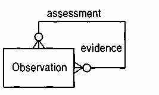

图 3.8 记录证据和评估的递归关系。

Figure 3.8 Recursive relationship to record evidence and assessment.

这是将类别到现象类型的映射改为单值映射的有力证据。它将类别提升到知识层级，并将其更名为现象，如图 3.9 所示。现象定义了某些现象类型的可能值。

This was the compelling evidence for making the mapping from category to phenomenon type single-valued. It moved category to the knowledge level and renamed it phenomenon, as shown in Figure 3.9. Phenomena define the possible values for some phenomenon type.

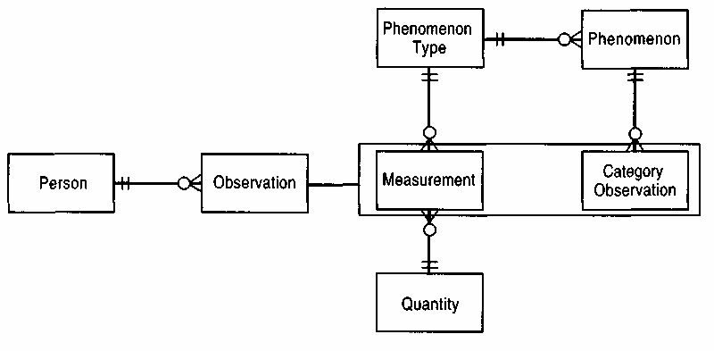

图 3.9 知识水平中的现象（以前称为类别）。

Figure 3.9 Phenomenon (formerly category) in the knowledge level.

将定性陈述（例如血型 A）置于知识层面，就可以 在规则中使用它们。

Placing qualitative statements (such as blood group A) in the knowledge level allows them to be used in rules.

例如，一个人的血型是A型这一事实，可以通过对具有A型血特征的人进行类别观察来表明。A型血特征与血型类型这一特征相关联。

Example The fact that a person is blood group A is indicated by a category observation of a person whose phenomenon is blood group A. The blood group A phenomenon is linked to the phenomenon type of blood group.

例如，我们可以将汽车机油油位过低建模为汽车的一个类别观测值。现象类型为机油油位，可能的状态包括过满、正常和过低。该观测值将汽车与机油油位过低这一现象联系起来。

Example We can model a low oil level in a car as a category observation of the car. The phenomenon type is oil level with possible phenomena of over-full, OK, and low. The observation links the car to the low phenomenon.

图 3.9 中的模型适用于具有多个现象类型的类别观察。但许多观察仅涉及存在或不存在的陈述，而非一系列值。疾病就是很好的例子：糖尿病要么存在，要么不存在。我们可以使用图 3.9 来描述“糖尿病不存在”和“糖尿病存在”这两种现象。明确记录糖尿病不存在的情况固然重要，但记录体重没有减轻的情况也可能很有意义。（如果患者出现糖尿病症状但体重没有减轻，则表明并非患有糖尿病。这并不意味着体重正在增加或保持稳定，仅仅意味着体重没有减轻。）实际上，我们可以记录任何现象的不存在情况，尤其可以排除假设性诊断。因此，图 3.10 所示的模型允许任何类别观察具有存在和不存在两种状态。观察概念被添加为现象的超类型。这样做是为了允许糖尿病作为一个观察概念，而无需将其附加到任何现象类型。

The model in Figure 3.9 works well for category observations with several values for a phenomenon type. But many observations involve merely a statement of absence or presence rather than a range of values. Diseases are good examples of these: Diabetes is either present or absent. We could use Figure 3.9 with the phenomena diabetes absent and diabetes present. This ability to explicitly record the absence of diabetes is important, but it may also be sensible to record absence of weight loss. (If a patient comes in with symptoms of diabetes but has not been losing weight, then that would contra-indicate diabetes. This does not imply that the weight is increasing or steady, merely that it is not decreasing.) Indeed we can record the absence of any phenomenon, particularly to eliminate hypothetical diagnoses. Thus the model shown in Figure 3.10 allows any category observation to have presence and absence. Observation concept is added as a supertype of phenomenon. This is done to allow diabetes to be an observation concept without attaching it to some phenomenon type.

例如，我们记录了约翰·史密斯患有糖尿病的事实，方法是将约翰·史密斯的存在观察与糖尿病观察概念联系起来。

Example We record the fact that John Smith has diabetes by a presence observation of John Smith linked to the observation concept diabetes.

例如，我们用隧道本身（而非人）作为观察对象，并定义一个“混凝土剥落”的观察概念，来表示隧道中混凝土的剥落（劣化）。此外，我们还需要在观察结果中添加一个特征，以指示剥落发生在隧道的哪个位置。（对于某些观察概念，医学观察可能还需要解剖学位置信息。）

Example We represent spalling (deteriorating) concrete in a tunnel by an observation with the tunnel instead of the person, and an observation concept of spalling concrete. We also need a feature on the observation to indicate where in the tunnel the spalling occurs. (Medical observations may also need an anatomical location for some observation concepts.)

#### 3.6 亚型观察概念

#### 3.6 Subtyping Observation Concepts

图 3.10 引入了一种超类型关系，它允许对观察概念进行概括。这在医学领域非常常见，并且很有价值，因为观察可以在任何概括程度上进行。如果观察到某个亚型的存在，则所有超类型也都被认为存在。然而，如果观察到某个亚型的缺失，则既不意味着超类型的存在，也不意味着超类型的缺失。观察到缺失并不意味着所有亚型也都缺失。因此，存在性沿着超类型层级向上传播，而缺失性则向下传播。

Figure 3.10 introduces a supertype relationship that allows generalization of observation concepts. This is quite common in medicine and is valuable because observations can be made at any level of generality. If an observation is made of the presence of the subtype, then all supertypes are also considered to be present. However, if an observation is made of the absence of a subtype, then that implies neither presence nor absence of supertypes. Observation of absence does imply all subtypes are also absent. Thus presence is propagated up the supertype hierarchy, while absence is propagated downward.

例如，糖尿病是一个观察概念，分为两种亚型：I 型糖尿病和 II 型糖尿病。观察到约翰·史密斯患有 I 型糖尿病，意味着约翰·史密斯也患有糖尿病。

Example Diabetes is an observation concept with two subtypes: type I diabetes and type II diabetes. An observation that type I diabetes is present for John Smith implies that diabetes is also present for John Smith.

例如， A型血被称为多态性血型，因为它可以细分为A1和A2亚型。其他血型则不具有多态性。

Example Blood group A is called polymorphic because it can be subtyped to A1 and A2. The other blood groups are not polymorphic.

#### 3.7 协议

#### 3.7 Protocol

记录观察结果的一个重要知识概念是操作规程——即进行观察的方法。我们可以通过将体温计放入口腔、腋窝或直肠来测量人体的体温。通常，这些方法得到的温度读数可以认为是相同的；然而，记录我们使用的方法至关重要。了解获得异常观察结果的技术往往可以解释该结果。因此，在医疗保健领域，记录用于记录观察结果的测试方法是一种公认的做法。

An important knowledge concept for recording observations is the protocol— the method by which the observations were made. We can measure a person's body temperature by placing a thermometer in the mouth, armpit, or rectum. Usually the temperature readings these techniques yield can be considered the same; nonetheless, it is vital to record which approach we used. A strange observation can often be explained by understanding the technique that was used to reach it. Thus in health care it is accepted practice to always record what tests are used to record observations.

协议的价值之一在于它可以用来确定测量的准确性和灵敏度。这些信息可以被记录下来。

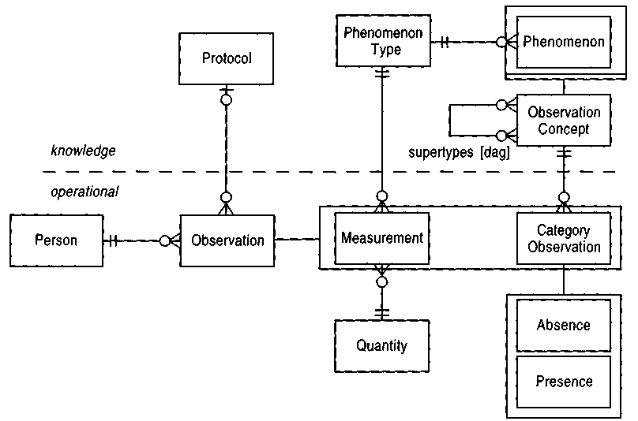

图 3.10 观察概念的缺失与存在。

Figure 3.10 Absence and presence of observation concepts.

某种现象的缺失与它的存在同样重要。

The absence of a phenomenon can be as valuable as finding a presence.

测量本身固然重要，但通常情况下，测量结果取决于观测所采用的协议。严格遵守协议能更方便地获取这些信息。

#### 3.8 双人计时赛记录

#### 3.8 Dual Time Record

观测结果通常具有一定的有效期限。有效期限的结束标志着该观测结果不再适用。该有效期限与进行观测的时间不同。因此，每个观测结果都有两条时间记录（可以是时间段，也可以是单个时间点）：一条记录观测结果的适用时间，另一条记录观测结果的记录时间，如图 3.11 所示。

Observations often have a limited time period during which they can be applied. The end of the time period indicates when the observation is no longer applicable. This time period is different than the time at which the observation is made. Thus there are two time records (which may be periods or single time points) for each observation: one to record when the observation is applicable and the second when it is recorded, as shown in Figure 3.11.

例如，在1997年5月1日的一次就诊中，约翰·史密斯告诉他的医生，他六个月前曾出现胸痛，持续了一周。医生将此记录为对“胸痛”这一观察概念的观察结果。适用时间记录的时间段为1996年11月1日至1996年11月。记录时间为1997年5月1日。（请注意，此处若能以某种方式记录大致时间点将很有帮助。）

Example At a consultation on May 1, 1997, John Smith tells his doctor that he had chest pain six months ago that lasted for a week. The doctor records this as an observation of the presence of the observation concept chest pain. The applicability time record is a time period starting at November 1, 1996 and ending at Novembers, 1996. The recording time is the timepoint May 1,1997. (Note that some way of recording approximate timepoints would be valuable here.)

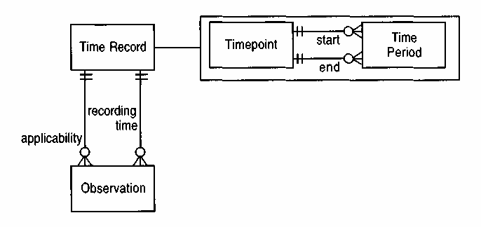

图 3.11 双时间记录观测。

Figure 3.11 Dual time record for observation.

时间记录既可以记录时间段，也可以记录单个时间点。大多数事件的 发生时间和记录时间是分开的。

A time record allows both periods and single points to be recorded. Most events have a separate occurring and recording time.

#### 3.9 被拒绝的观测值

#### 3.9 Rejected Observation

我们在进行观察时难免会犯错。然而，对于医疗记录而言，我们不能随意删除错误信息。治疗方案可能基于这些错误，而且通常存在法律限制。为了应对这种情况，我们可以将已被证实为不实的观察结果归类为“已驳回的观察结果”，如图 3.12 所示。（请注意，这与曾经正确但现在不再正确的观察结果有所不同，例如已愈合的骨折。已愈合的骨折永远不会被驳回，但其适用时间记录会被赋予一个结束日期。）被驳回的观察结果必须与其驳回的原始观察结果关联起来。

Inevitably we make mistakes when making observations. In the case of medical records, however, we cannot just erase them. Treatments may have been based on these mistakes, and there are usually legal restrictions. To handle this consideration, we can classify observations as rejected observations when it is found that they were and are untrue, as shown in Figure 3.12. (Note the difference between this and an observation that was true but is no longer true, such as a healed broken arm. A healed broken arm is never rejected, but its applicability time record is given an end date.) Rejected observations must be linked to the observation that rejects them.

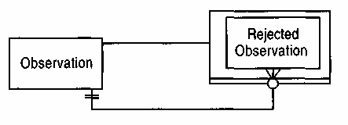

图 3.12 被拒绝的观测值。

Figure 3.12 Rejected observations.

如果需要完整的审计跟踪，则不能删除观察记录。

Observations cannot be deleted if a full audit trail is needed.

例如，约翰·史密斯的血液检查结果显示平均红细胞体积较大。这可能是由恶性贫血或酗酒引起的。约翰·史密斯告诉医生他很少喝酒。这表明他可能患有恶性贫血，因此需要进行进一步的检查和治疗。六个月后，发现约翰·史密斯酗酒严重。这一信息表明，应该用酗酒的发现来否定恶性贫血的诊断。必须保留之前否定的恶性贫血的诊断，以解释随后进行的治疗。

Example John Smith has a blood test that indicates a large mean corpuscular volume. This can be due to either pernicious anemia or alcohol abuse. John Smith informs the doctor that he drinks very little alcohol. This indicates the presence of pernicious anemia, which leads to further tests and treatment. Six months later it is discovered that John Smith drinks heavily. This information indicates that the observation of pernicious anemia should be rejected by an observation of alcohol abuse. The rejected observation of pernicious anemia must be retained to explain the treatment that ensued.

#### 3.10 主动观察、假设和预测

#### 3.10 Active Observation, Hypothesis, and Projection

在记录观察结果时，会给出不同程度的置信度。例如，临床医生可能会遇到一位表现出所有典型糖尿病症状的患者。医生记录说她认为该患者可能患有糖尿病，但在进行检测之前无法确定，而且在许多疾病中，即使进行检测也无法提供百分之百的确定性。记录这类信息的一种方法是为观察结果赋予概率，但这种方法不够清晰，也不够自然。另一种方法是使用两种分类：主动观察和假设，如图 3.13 所示。二者的区别很微妙：主动观察是指临床医生“积极采纳”的观察结果，并可能以此作为治疗依据。而假设则更有可能导致进一步的检查。

As observations are recorded, many levels of assurance are given. A clinician might be faced with a patient showing all the classic symptoms of diabetes. The clinician records that she thinks the patient probably has diabetes, but she cannot be certain until a test is done, and in many diseases even a test does not provide 100 percent certainty. One approach to recording this kind of information is to assign probabilities to observations, but this method is unclear and does not seem natural. The alternative is to use two classifications: active observation and hypothesis, as shown in Figure 3.13. The distinction is subtle: An active observation is one that the clinician "runs with," probably using it as a basis for treatment. A hypothesis more likely leads to further tests.

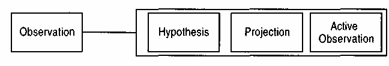

图 3.13 主动观察、假设和预测。

Figure 3.13 Active observation, hypothesis, and projection.

例如，一位患者出现口渴、体重减轻和多尿等症状，提示可能患有糖尿病。然而，仅凭这些症状，临床医生会假设患者患有糖尿病，并要求进行空腹血糖检测。该检测结果将决定是否证实或排除糖尿病的假设。

Example A patient with observations of the presence of thirst, weight loss, and poly-uria indicates diabetes. With just these symptoms, however, a clinician makes a hypothesis of diabetes and orders a measurement of the fasting blood glucose. The result of this test indicates whether to confirm the hypothesis or reject it.

主动观察和假设这两种亚型都代表对患者当前状态的观察。预测则是临床医生认为未来可能发生的情况。临床医生通常会根据未来可能出现的情况来制定治疗方案。如果预测正确，则会记录下来，并附上一次主动观察。

Both subtypes, active observation and hypothesis, represent observations of the current state of the patient. Projections are observations that the clinician thinks might occur in the future. Often clinicians decide on treatments by considering future conditions that may occur. If the prediction is true, it is recorded with an additional active observation.

例如，如果患者患有风湿热或继发性风湿性瓣膜病，则存在发生心内膜炎的风险。此风险会被记录为心内膜炎预测值。治疗方案将基于此预测值制定。

Example If a patient has rheumatic fever, or consequent rheumatic valve disease, there is a risk of endocarditis. This risk is recorded as a projection of endocarditis. Treatments will then be based on this projection.

在“宇宙”项目中，观察结果的确定性是讨论最多的领域之一。团队和质量保证小组在这个领域投入的时间和精力，比模型的其他任何部分都多。最终模型反映了临床医生对最自然情况的看法。传统的概率赋值方法或许对科幻爱好者来说合情合理，但显然对临床医生来说却难以理解（他们可能会问诸如“0.8 和 0.7 之间的差异意味着什么？”之类的问题）。通过积极观察和假设，最终的概念更加清晰，尽管选择使用哪种分类方法也更具挑战性。最终，只有参与该项目的经验丰富的临床医生团队才能几乎凭直觉就此做出有效的决策。团队中的专业分析师只能指出一些形式上的推论。

The certainty of observations was one area of much discussion in the Cosmos project. More changes were made in this area and more time was spent by both the team and quality assurance panel than any other part of the model. The final model reflects the clinicians' views of what was the most natural. The classic approach of assigning probabilities might make sense to science fiction aficionados, but it clearly did not to clinicians (who could predict asking questions such as "What am I to make of the difference between 0.8 and 0.7?"). With active observation and hypothesis, the final concept is more clear, although the choice of which classification to use is more problematic. In the end only the group of experienced clinicians connected with the project could make a useful decision on this area in an almost instinctive way. The professional analyst in the team could only point out some formal consequences.

#### 3.11 相关观察

#### 3.11 Associated Observation

此时，我们可以探讨如何记录诊断背后的证据链。基本思路是允许观察结果彼此关联（例如，患者的口渴表明患者患有糖尿病），也允许观察概念彼此关联（例如，口渴表明患有糖尿病）。由此可见，知识层面和操作层面互为反映，如图 3.14 所示。这些反映通过关联关系连接起来，这些关联关系展示了知识概念如何应用于操作层面。在本例中，关联关系不仅存在于观察结果和观察概念之间，也存在于证据结论的关联关系之间。因此，当我们说患者的口渴表明患者患有糖尿病时，我们利用了口渴和糖尿病之间的普遍关联，并且应该明确记录我们正在利用这种关联。图 3.14 展示了我们如何创建类型，不仅用于存储观察结果和观察概念，还用于存储操作层面（关联观察）和知识层面（关联函数）的关联类型。

At this point we can look at ways to record the chain of evidence behind a diagnosis. The basic idea is to allow observations to be linked to each other (the patient's thirst indicated the patient's diabetes) and observation concepts to be so linked (thirst indicates diabetes). Thus we see that the knowledge and operational levels are reflections of each other, as shown in Figure 3.14. These reflections are linked by associations that show how knowledge concepts are applied to the operational level. In this case the links occur not only between the observation and the observation concept but also between the evidence conclusion links. Thus when we say the patient's thirst indicates that the patient has diabetes, we are making use of, and should explicitly record that we are making use of, the general connection between thirst and diabetes. Figure 3.14 shows how we make types to hold not just observations and observation concepts but also types for the links at the operational (associated observation) and the knowledge (associative function) level.

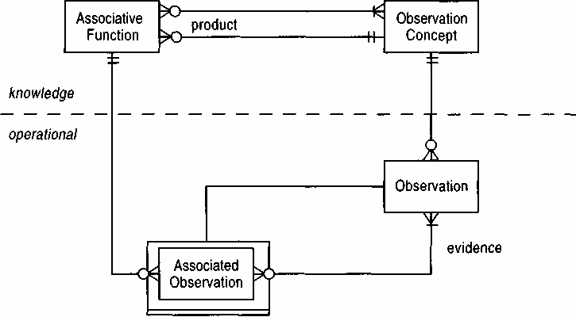

图 3.14 观测结果之间的联系。

Figure 3.14 Links between observations.

患者的实际证据链在操作层面进行记录。知识 层面则描述可能存在的证据链。

Actual evidence chains for a patient are recorded at the operational level. The knowledge level describes what chains are possible.

例如，一位临床医生观察到患者出现体重减轻、口渴和多尿症状，并基于这些观察结果，做出关于糖尿病的相关观察（和假设）。该相关观察与一个关联函数相关联，该函数的自变量是观察概念——体重减轻、口渴和多尿——其乘积是糖尿病。

Example A clinician observes weight loss, thirst, and polyuria in a patient and makes an associated observation (and hypothesis) of diabetes based on the evidence observations. The associated observation is linked to an associative function whose arguments are the observation concepts—weight loss, thirst, and polyuria—and whose product is diabetes.

例如，如果我的车无法启动且车灯不亮，那么这两个现象都表明电池没电了。汽车无法启动、车灯不亮和电池没电都是通过关联函数联系在一起的观察概念。

Example If my car does not start and the lights do not work, then both of these observations are evidence for the associated observation of a dead battery. Car not starting, lights not working, and dead battery are all observation concepts linked by an associative function.

需要注意的是，知识层面和操作层面并非完全互为镜像。关联观察是观察的一种子类型，但关联函数并非观察概念的子类型。将关联观察视为观察的一种子类型似乎很自然，因为在操作层面，会进行一次特定的观察并辅以证据支持。而在知识层面，则会记录包含论证和结论的规则。一个观察概念可能对应多个关联函数，而它本身就是这些关联函数的结果，但一次特定的观察却只有一组观察作为证据。

Note that the knowledge and operational levels are not complete mirror images of each other. Associated observation is a subtype of observation, but associative function is not a subtype of observation concept. It seemed natural to make associated observation a subtype of observation since, at the operational level, one particular observation is made with supporting evidence. At the knowledge level, the rule with arguments and conclusion is recorded. One observation concept may have several associative functions for which it is the result, but a particular observation has only one set of observations as evidence.

#### 3.12 观察过程

#### 3.12 Process of Observation

本章重点讨论了观察的静态要素：什么是观察或测量，以及如何以通用方式记录观察结果，以支持临床医生进行分析。值得注意的是，在建模过程中，我们发现可以构建一个通用的静态模型，但行为部分则更多地依赖于各个科室。当然，静态模型蕴含着大量的行为。行为的存在是为了产生观察结果，并提供各种方法来理解这些观察结果与其他观察结果之间的关联。然而，我们无法推断的是典型科室进行的观察顺序。临床医生通常会遵循一定的观察路径。科室政策可能是根据更高级别的流程记录这一路径（参见第8章）。设计一个所有临床医生都能使用的通用流程是困难的，几乎是不可能的。

This chapter has concentrated on the static elements of observation: what an observation or measurement is and how we can record it in a generic way to support the analysis that clinicians need to perform on it. It is significant that in modeling we found that we could conceive of a general static model, but the behavioral part was much more dependent on individual departments. Of course, a static model implies a great deal of behavior. Behaviors exist to create observations and to provide various ways of navigating associations to understand how those observations fit with other observations. The behavior we cannot imply, however, is the sequence of observations that a typical department makes. Often a clinician has some path of observations that can be taken. Departmental policy may be to record this path in terms of higher-level protocols (see Chapter 8). It is difficult, and almost certainly impossible, to design a general process that all clinicians could use.

然而，我们可以大致概述一下观察过程。首先，如图 3.15 所示，我们来看一下新的观察结果如何引发进一步的观察。临床医生在进行观察时，会考虑其他相关观察的可能性。他们运用已知的关联函数，列出可能与触发观察相关的观察概念。然后，他们可以根据需要提出进一步的观察。

It is possible, however, to sketch an outline of the process involved in making observations. I begin by looking at how making a new observation can trigger further observations, as shown in Figure 3.15. Whenever clinicians make observations, they consider the possibility of other associated observations. They use the associative functions they know to come up with a list of possible observation concepts that might be associated with the triggering observations. They can then propose further observations as needed.

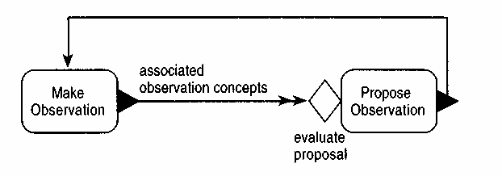

图 3.15 进行观察会引发进一步的观察。

Figure 3.15 Making an observation triggers further observations.

根据知识水平，可以提出进一步的观察意见。

Further observations are suggested by the knowledge level.

在图 3.15 中，并发触发规则被标记为“关联观察概念”。在事件图中，触发规则有两个用途。首先，它们表示因果关系。当我们考虑业务流程时，这通常就足够了，但随着我们深入研究，我们会发现第二个用途。任何操作都有输入和输出。连接两个操作的触发器必须描述如何从触发操作的输出到达被触发操作的输入。在许多情况下，这很简单，因为它们是同一个对象（例如图 3.15 中从“提出观察”到“执行观察”的触发器）。然而，它们也可能变得相当复杂，例如在查找关联观察概念时。

In Figure 3.15 the concurrent trigger rule is labeled "associated observation concepts." In event diagrams, trigger rules have two purposes. First, they show cause and effect. When we are considering business processes, this is usually enough, but as we delve deeper we see a second purpose. Any operation has input and output. The trigger that connects two operations must describe how to get from the output of the triggering operation to the input of the triggered operation. In many cases this is trivial, as they are the same object (as in the trigger from propose observation to make observation shown in Figure 3.15). However they can get quite complex, as in finding associated observation concepts.

当触发规则更复杂时，我们可以用另一个事件图来表示它。图 3.16 和 3.17 展示了关联观察概念触发的实现方式。首先，我们找到所有输入包含初始观察的观察概念的关联函数。然后，我们计算每个关联函数的值。对于每个结果为真的关联函数，我们计算其乘积并将其加到结果中。由于这些事件图描述的是触发规则查询，因此所有操作都必须是访问器操作，从而不能改变任何对象的可观察状态。

When we have a more complex trigger rule, we can represent the trigger rule with another event diagram. Figures 3.16 and 3.17 do this for the associated observation concepts trigger. We begin by finding all the associative functions whose input includes the initial observation's observation concept. We then evaluate each of these associative functions. For each one that evaluates to true, we find the product and add it to the answer. Since these event diagrams describe a trigger rule query, all the operations must be accessors and hence must not change the observable state of any object.

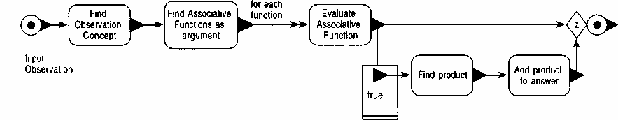

图 3.16 事件图，用于描述查找关联观测值的查询。

Figure 3.16 Event diagram to describe the query for finding associated observations.

这位于图 3.15 的并发触发或图 3.18 的操作中。

This lies on the concurrent trigger of Figure 3.15 or in the operation of Figure 3. 18.

当触发规则查询很复杂时，也可以将查询表示为一个独立的操作，如图 3.18 所示。两种方法都是正确的。

When the trigger rule query is complex, you can also represent the query as an operation in its own right, as shown in Figure 3.18. Either method is correct.

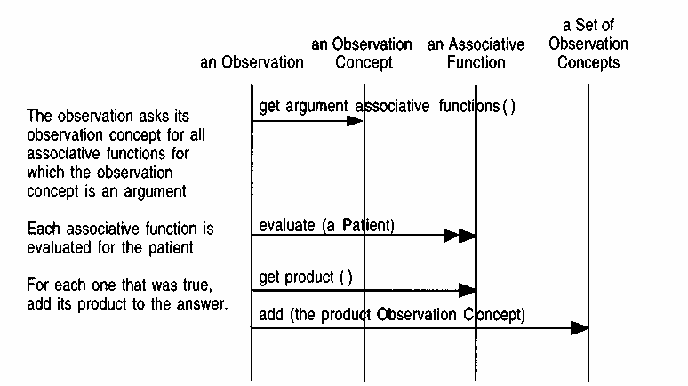

图 3.17 用于查找观察所隐含的可能观察概念的交互图。

Figure 3.17 An interaction diagram for finding the possible observation concepts implied by an observation.

该交互图支持图 3.16。

This interaction diagram supports Figure 3.16.

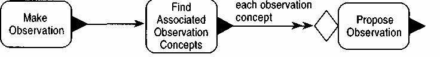

图 3.18 将查询显式地表示为一个操作。

Figure 3.18 Notating the query explicitly as an operation.

这与图 3.15 等效。您可以将查询显示为操作，也可以将 其视为触发器的一部分，以简洁性换取紧凑性。

This is equivalent to Figure 3.15. You can either show queries as operations or consider them part of the trigger, trading simplicity for compactness.

即使在查询之后，在提出观察方案之前，仍然存在一个控制条件（评估提议）。查询会根据关联函数提出可能的观察概念。这一步骤很容易由决策支持系统中的软件完成。控制条件代表了额外的步骤，即判断所建议的观察概念是否值得检验。我们认为无法对这一过程进行正式建模，这意味着这一步骤超出了软件的处理范围，只能由临床医生自行判断。

Even after the query, there is a control condition (evaluate proposal) before an observation is proposed. The query suggests possible observation concepts to look for based on the associative functions. This step could easily be done by software in a decision support system. The control condition represents the extra step of deciding whether the suggested observation concept is worth testing for. We did not feel we could formally model this process, implying that this step is beyond software and can only be done in the clinician's head.

图 3.19 包含了由预测和主动观察产生的其他触发因素。这些触发因素用于提出干预建议，其工作方式与前文所述类似。我们建议的干预措施在提出前会由临床医生进行评估。这进一步强调了这样一个事实：虽然任何观察都可能导致进一步的观察，但只有主动观察或预测（而非假设）才能最终促成干预。（干预是指旨在或可能导致患者状态改变的行为。）触发查询的工作方式与知识层级类似，但涉及启动函数，这些函数将在 8.7 节中简要讨论。

Figure 3.19 includes additional triggers that arise from projections and active observations. The triggers to propose intervention work in a similar way to the previous case. We suggest interventions that are eval uated by the clinician before they are proposed. This reinforces the fact that although any observation can lead to further observations being made, only active observations or projections (not hypotheses) lead to interventions. (An intervention is an action which either intends or risks a change in state of the patient.) The trigger queries work in a similar way with the knowledge level but involve start functions, which are discussed briefly in Section 8.7.

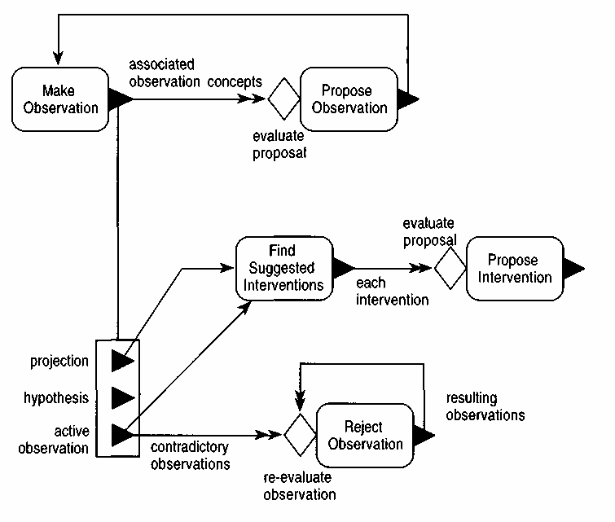

图3.19 观测数据处理过程的事件图。

Figure 3.19 Event diagram for the process of working with observations. This

图 3.15 扩展了干预和拒绝的类似触发因素。

extends Figure 3.15 with similar triggers for interventions and rejections.

图 3.19 中的最后一个触发条件展示了活跃观测结果的出现如何与其他观测结果相矛盾，从而导致这些观测结果被拒绝。这同样可能涉及关联函数，但这次我们寻找的是矛盾。一旦某个观测结果（可能是假设）被拒绝，那么之前受该观测结果支持的后续观测结果就必须重新考虑。

The final trigger on Figure 3.19 shows how the appearance of an active observation can contradict other observations and thus lead to those observations being rejected. Again this can involve associative functions, but this time we are looking for a contradiction. Once an observation (which may be a hypothesis) is rejected, further observations which were supported by this observation must be reconsidered.

这些模式的产生过程，其有趣之处在于抽象概念的发现方式。尽管本文讨论的最终结果通常是结构性的，但行为建模在理解这些概念的运作机制中发挥了核心作用。临床医生亲自进行建模这一事实也至关重要。观察的抽象是这些模式的核心；它将体征、症状和诊断联系起来，而临床医生长期以来一直认为这三者截然不同。只有通过建模过程，临床医生才能提取出这种抽象概念。如果软件工程师提出这样的抽象概念，我怀疑他们是否能够说服临床医生相信其有效性。这种怀疑不无道理，因为软件工程师永远不可能拥有如此深厚的医学知识。最佳的概念模型是由领域专家构建的，而他们往往也是最佳的概念建模者。

One of the interesting things about the work that produced these patterns is the way the abstractions were found. Although the final results discussed here are usually structural, behavioral modeling played a central role in understanding how the concepts worked. The fact that clinicians did the modeling themselves was also crucial. The abstraction of observation is central to these patterns; it ties together signs, symptoms, and diagnoses, which clinicians have long considered to be very different. It was only by going through the modeling process that clinicians could pull out the abstraction. If software engineers had come up with such an abstraction, I doubt if they could ever convince clinicians that it was valid. And there would be good reason to be doubtful, since software engineers can never have that deep knowledge of medicine. The best conceptual models are built by domain experts, and they are often the best conceptual modelers.

#### 参考

#### References

1. Cairns, T.、A. Casey、M. Fowler、M. Thursz 和 H. Timimi。《Cosmos 临床过程模型》。英国国家医疗服务体系信息管理中心，地址：15 Frederick Rd, Birmingham, B15 1JD, England。报告 ECBS20A 和 ECBS20B <http://www.sm.ic.ac.uk/medicine/cpm>，1992 年。
2. Cairns, T., A. Casey, M. Fowler, M. Thursz, and H. Timimi. The Cosmos Clinical Process Model. National Health Service, Information Management Centre, 15 Frederick Rd, Birmingham, B15 1JD, England. Report ECBS20A & ECBS20B <http://www.sm.ic.ac.uk/medicine/cpm>, 1992.
3. Cunningham, W.“信息完整性的 CHECKS 模式语言”，载于《程序设计模式语言》。JO Coplien 和 DC Schmidt 编。雷丁，马萨诸塞州：Addison-Wesley，1995 年，第 145-155 页。
4. Cunningham, W. "The CHECKS Pattern Language of Information Integrity," In Pattern Languages of Program Design. J.O. Coplien, and D.C. Schmidt, ed. Reading, MA: Addison-Wesley, 1995, pp. 145-155.
5. Thursz, M.、M. Fowler、T. Cairns、M. Thick 和 G. Gold。“临床系统设计”，载于 IEEE 第六届计算机辅助医疗系统国际研讨会论文集，1993 年。
6. Thursz, M., M. Fowler, T. Cairns, M. Thick, and G. Gold. "Clinical Systems Design," In Proceedings of IEEE 6th International Symposium on Computer Based Medical Systems, 1993.

### 第四章 公司财务观察

### Chapter 4. Observations for Corporate Finance

要充分理解本章内容，您需要先阅读第3章。

To fully understand this chapter, you will need to read Chapter 3 first.

在大型企业中，识别高层问题很容易，但找出这些问题的根本原因却更加棘手。这类企业会产生海量信息，任何试图分析这些信息的人都可能被淹没其中。

In large corporations it is easy to identify high-level problems, but finding out the root causes of these problems is more tricky. Such corporations generate a deluge of information that can quickly drown anyone trying to analyze it.

例如，衡量公司业绩的主要指标之一是其最终收入。如果收入出现显著下滑，则需要进行分析以找出原因。对 Aroma Coffee Makers (ACM) 的分析表明，尽管其成本仍然合理，但设备销售收入却有所下降。这种情况在其东北地区尤为明显。进一步分析发现，其 1100 款高销量咖啡机系列的实际收入远低于预期，尤其是在政府部门。以上分析主要基于数字，但更深入的分析可能更侧重于定性而非定量。业绩不佳的原因可能是销售薪酬方案不合理、政府预算削减、夏季高温，或是该地区竞争对手实力强劲。

For example, one of the principal measures of a company's performance is its final revenue. If the revenue shows a notable dip, then some analysis needs to be done to find out why. Such an analysis for Aroma Coffee Makers (ACM) showed that their equipment sales income was reduced, although their costs were still reasonable. This was most noticeable in their Northeast region. Looking further showed that their 1100 high-volume coffee maker family was well below its planned income, particularly in the government sector. Much of this is analysis of numbers, but further analysis may be more qualitative than quantitative. Perhaps this poor performance is due to a weak sales compensation plan, or government budget cuts, or a very hot summer, or strong competitor presence in the area.

这一切与临床医生在调查患者症状时所进行的诊断过程非常相似。我们从明显的症状出发，根据我们在该领域的知识，追溯可能的原因。我们希望找到根本原因，然后进行治疗。基于对类似过程的这种宏观理解，我们或许可以假设，可以将临床模型应用于公司金融领域。

All of this is much the same diagnostic process that is done by clinicians when investigating a patient's symptoms. From the obvious symptom we track back through likely causes, guided by our knowledge of the field. We hope to identify the root causes and then treat them. From this broad view of similar processes, we might hypothesize that we can apply the clinical models to corporate finance.

第三章描述了如何在医疗保健领域对患者进行定性和定量描述。在该章结尾，我简要提及该模型可以应用于其他领域，例如分析公司财务。本章将探讨如何将其应用于其他领域。

Chapter 3 gives a description of how qualitative and quantitative statements can be made about patients in a health care context. At the end of that chapter, I briefly mentioned that that model can be applied to other contexts, such as analyzing corporate finances. This chapter looks at how this can be

57 已完成。该模型运行良好，但需要进行一些修改。幸运的是，描述这些修改的模式都是对现有模型的扩展，而不是对其的更改。

57 done. The model works very well, but some modifications are required. Fortunately the patterns that describe these modifications are all extensions of the existing model rather than changes to it.

第一种模式用描述所分析企业细分领域的某种方式来代替人。该企业细分领域（4.1）描述了企业中沿一系列维度定义的部分。每个维度代表一种对企业进行层级划分的方式，例如地理位置、产品范围或市场。企业细分领域是这些维度的组合，这是多维数据库广泛采用的一种技术。

The first pattern replaces the person with some way of describing the segment of the enterprise under analysis. This enterprise segment (4.1) describes a part of the enterprise defined along a series of dimensions. Each dimension represents some way of hierarchically breaking down the enterprise, such as location, product range, or market. The enterprise segment is a combination of these dimensions, a technique widely used by multidimensional databases.

测量协议 (4.2) 模式描述了如何使用模型类型的实例公式，从其他测量值计算出测量值。第 3 章讨论了每种测量值如何衡量一种现象类型；本章将讨论测量协议如何定义为特定现象类型创建测量值的方法。我们涵盖三种测量协议：因果测量协议 (4.2.2) 描述了如何将不同的现象类型组合起来计算另一种现象类型（例如，销售收入是销售量与平均价格的乘积）。比较测量协议 (4.2.2) 描述了单个现象类型如何在不同的状态类型 (4.2.3) 之间变化（例如，实际销售收入与计划销售收入的偏差）。维度组合 (4.2.5) 使用企业细分模式中定义的维度来计算汇总值（例如，通过将各个州的数值相加来计算东北地区的销售收入）。每种测量协议子类型都使用多态性来确定其值。

The measurement protocol (4.2) pattern describes how measurements can be calculated from other measurements using formulas that are instances of model types. Chapter 3 discusses how each measurement measures a phenomenon type; here we discuss how the measurement protocol defines ways of creating measurements for a particular phenomenon type. We cover three varieties of measurement protocols: Causal measurement protocols (4.2.2) describe how different phenomenon types are combined to calculate another (sales revenue is the product of units sold and average price). Comparative measurement protocols (4.2.2) describe how a single phenomenon type can vary between status types (4.2.3) (actual versus plan deviation of sales revenue). Dimension combinations (4.2.5) use the dimensions defined in the enterprise segment pattern to calculate summary values (calculate northeast sales revenue by totaling the values for individual states). Each of these subtypes of measurement protocol uses polymorphism to determine its value.

我们常常用定性现象来描述定量现象类型。在这种情况下，我们可以通过将现象与该现象类型的值范围关联起来来定义它们。首先，我们需要一个范围（4.3），它允许我们描述两个量之间的范围以及我们希望对该范围进行的各种操作。然后，我们可以通过两种方式定义具有范围的现象（4.4）：一是使用具有范围属性的现象（4.4.1）向现象添加范围；二是使用范围函数（4.4.2）。

Often we use qualitative phenomena to describe quantitative phenomenon types. In this case we can define the phenomena by linking them to a range of values for the phenomenon type. First we need a range (4.3), which allows us to describe a range between two quantities and various operations we want to do with the range. We can then define a phenomenon with range (4.4) either by adding a range to the phenomenon using a phenomenon with range attribute (4.4.1) or by using a range function (4.4.2).

我们可以将本章探讨的模式与第三章的模式结合起来，分析企业的财务数据。4.5节展示了如何利用这些模式来识别大型企业问题的根源。

We can combine the patterns examined in this chapter with those of Chapter 3 to analyze a business' financial data. Section 4.5 shows how we can use these patterns to identify the causes of problems in large corporations.

本章中的模型基于一家大型制造公司团队的研究成果。该团队探索了将医疗保健模型应用于公司财务，并发现它是一个非常有用的基础。本章中的模型原型是用 C++ 编写的。

The models in this chapter are based on work done by a team from a large manufacturing company. This team explored using a health care model for corporate finance and found it to be a very useful foundation. The models in this chapter were prototyped using C++.

关键概念：企业细分、维度、测量协议、状态类型

Key Concepts Enterprise Segment, Dimension, Measurement Protocol, Status Type

#### 4.1 企业部门

#### 4.1 Enterprise Segment

因此，我们需要修改从程序到患者的映射关系，使其指向其他类型。我在第三章关于映射关系的讨论中略微提及了这个问题，所以实际上它并不像乍看起来那么棘手。第三章所依据的原始 Cosmos 模型[1]实际上并没有将观察结果与个体联系起来。实际上，这种联系指向的是一种称为“护理对象”的类型。“护理对象”本身是对患者和人群的概括。人群是指一群人，用于对人群进行观察，这对于公共卫生尤为重要。

Thus we have to alter the mapping from procedure to patient to point to some other type. This is an issue that I skimmed over in the discussion of mapping in Chapter 3, so actually it is not such a problem as it may first appear. The original Cosmos model [1], on which Chapter 3 is based, does not actually link from observation to person. In reality the link is to a type called object of care. Object of care is itself a generalization of patient and population. A population is a group of people and is used to allow observations to be made of groups of people, which is particularly important for public health.

对于公司财务，我们需要一种新的关注对象子类型，我们称之为企业部门，如图 4.1 所示。企业部门是公司的一部分，是以非常特殊的方式定义的部分。

For corporate finance we need a new subtype of object of care, which we call enterprise segment, as shown in Figure 4.1. An enterprise segment is a part of a company, a part defined in a very particular way.

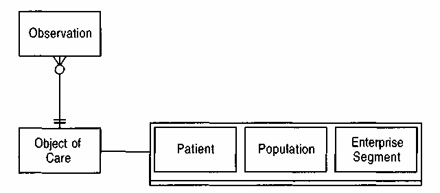

图 4.1 护理对象及其亚型。

Figure 4.1 Object of care and its subtypes.

第三章中的病人是可以观察的一种护理对象。

The patient of Chapter 3 is one kind of object of care that can be observed.

当我们观察一个企业时，可以根据多种标准将其划分为不同的部分。例如，可以根据组织单元、地理位置、产品、产品销售的行业等进行划分。每种划分方法都可以相对独立地进行，并且都可以用层级结构来表示。例如，一家跨国公司可以先按市场（美国）划分，然后按地区（东北部）划分，最后按区域（新罕布什尔州）划分。这些独立的层级结构都是企业的一个维度。新罕布什尔州和东北部是地理维度中不同层级的元素。企业的一个组成部分是各个维度元素的组合，每个维度对应一个元素。因此，ACM 的东北部、11-10 区和政府部门可以定义为一个企业组成部分，其地理维度包含东北部，产品维度包含 11-10 区，行业维度包含政府部门，如图 4.2 所示。这种分析方法通常被称为星型模式[4]，常用于多维数据库[2]。

When we look at an enterprise, we can see that we can divide it into parts according to several criteria. It may be divided due to organizational unit, to geographical location, by product, by the industry sector that the product is being sold into, and so on. Each of these methods of division can be carried out more or less independently. Each can also be expressed as a hierarchy. For example, a multinational company can be divided first by market (USA), then by region (Northeast), then by area (New Hampshire). Each of these independent hierarchies is a dimension of the enterprise. New Hampshire and Northeast are elements at different levels in the geographical dimension. An enterprise segment is a combination of dimension elements, one for each dimension of the enterprise. Thus the part of ACM that is northeast, 11-10, government can be defined as the enterprise segment with dimension elements of northeast on the geographical dimension, 11-10 on the product dimension, and government on the industry dimension, as shown in Figure 4.2. This approach to analysis, often referred to as a star schema [4], is com monly used in multidimensional databases [2].

定义了企业细分之后，我们可以构建各种类型之间关系的模型，如图 4.3 所示。我们可以将维度元素链接成层次结构。可以定义多个维度元素层次结构。请注意，父级关联的层次结构约束是必要的，因为仅凭基数无法强制建立层次结构（尽管基数可能允许循环）。企业细分必须包含来自每个层次结构的元素，如企业细分中的三个关联所示。维度元素的约束确保所有层次结构都属于同一维度。该模型能够很好地处理这种情况，但它也存在一些缺点。首先，维度和维度级别的概念没有得到正确定义，尽管它们可以推导出来。其次，添加新维度会导致模型发生变化。

With this enterprise segment defined, we can form a model of the relationships between the various types, as shown in Figure 4.3. We can link dimension elements together into hierarchies. Many hierarchies of dimension elements can be defined. Note how the hierarchies constraint on the parent association is necessary because the cardinalities alone do not enforce a hierarchy (although they might allow cycles). The enterprise segment must have one element from each of these hierarchies, as indicated by the three associations from the enterprise segment. The constraint on the dimension element ensures that the hierarchies are all within the same dimension. The model will handle the situation quite well, but it has a couple of disadvantages. First, the concepts of dimension and dimension level are not properly defined, although they can be derived. Second, adding a new dimension will cause a model change.

图 4.4 所示的模型使用显式维度类型。每个维度都包含一个维度元素层次结构。企业段需要与每个维度中的一个维度元素建立链接。我们可以使用键值映射（参见 15.2 节）来实现这一点。结合基数，该映射表明，对于每个键（维度）实例，都存在且仅存在一个维度元素。

The model shown in Figure 4.4 uses an explicit dimension type. Each dimension holds a hierarchy of dimension elements. The enterprise segment then needs to have one link to a dimension element in each dimension. We can do this by using the keyed mapping (see Section 15.2). When combined with cardinality this mapping states that for each instance of the key (dimension) there is one and only one dimension element.

例如，我们可以定义“11-10，东北政府企业”细分市场，并将其与维度元素“11-10”、“东北”和“政府”关联起来。“11-10”属于产品维度，“东北”属于地域维度，“政府”属于行业维度。

Example We can define the 11-10, Northeast government enterprise segment, linking it to the dimension elements 11-10, Northeast, and government. 11-10 is in the product dimension. Northeast is in the location dimension, and government is in the industry dimension.

请注意，每个层级结构都需要一个顶层，但这并不一定代表一个已命名的元素。一种常见的约定是将顶层标记为“全部”，表示任何引用它的段在该维度上都没有细分。另一种约定是允许与维度元素的映射是可选的；在这种情况下，“nil”表示树的顶层。尽管顶层元素略显人为，但前一种方法更加一致。

Note that each hierarchy needs a top, and this does not necessarily show a named thing. A common convention is to label the top "all," showing that any segment that references it does not have any breakdowns along that dimension. Another convention would be to let the mapping to the dimension element be optional; then "nil" would indicate the top of the tree. The former approach is more consistent, despite this slightly artificial top element.

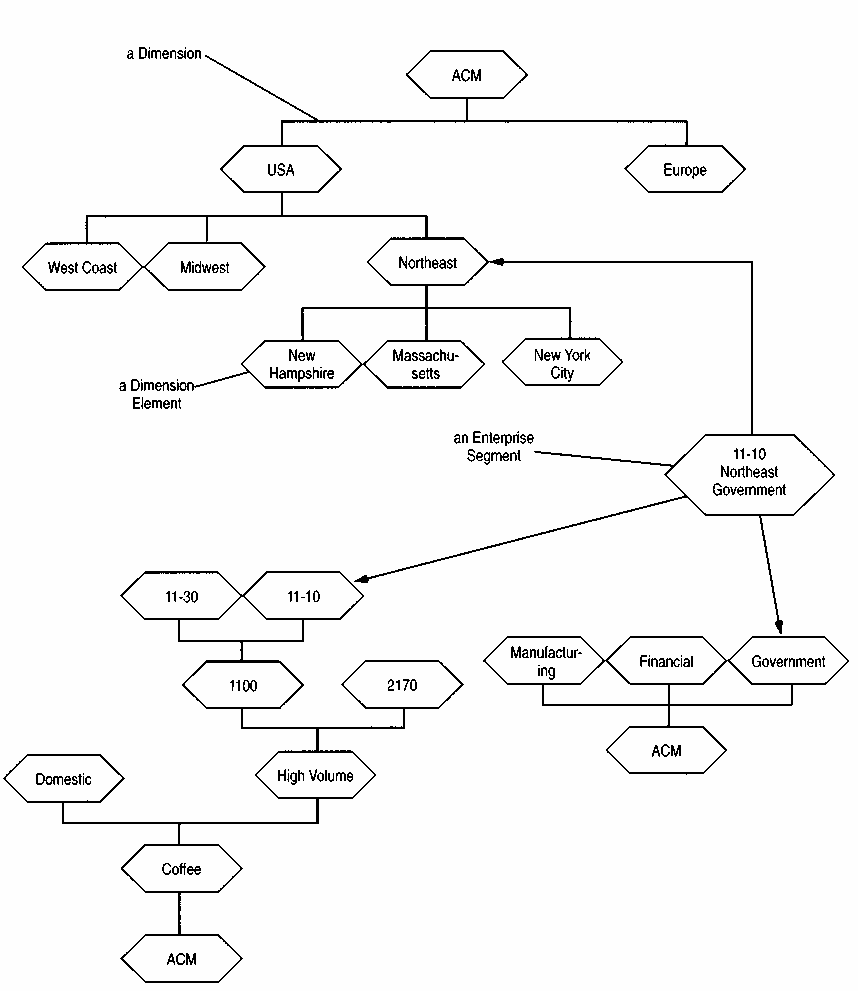

图 4.2 企业细分如何与维度中的要素相联系。

Figure 4.2 How enterprise segments link to elements in dimensions.

一个企业部门是由各个维度中的要素组合而成的。

One enterprise segment is a combination of elements from each dimension.

例如，如果我们添加一个渠道维度，那么企业细分市场“11-10 东北政府”就会链接到渠道层级结构的顶层维度元素。我们将这个维度元素称为“全部”。

Example If we add a channel dimension, then the enterprise segment 11-10 Northeast government has a link to the top dimension element of the channel hierarchy. We call this dimension element all.

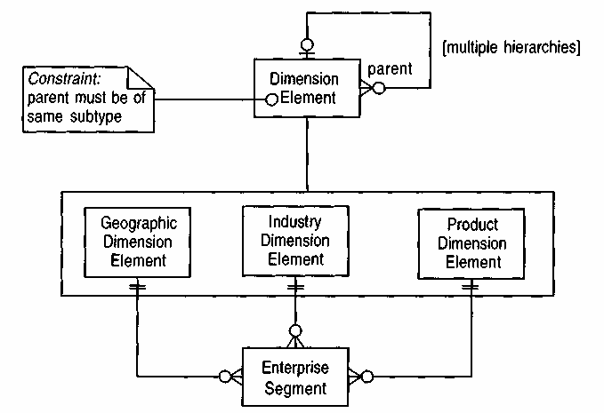

图 4.3 用维度元素定义企业细分。

Figure 4.3 Defining enterprise segments with dimension elements.

使用此模型时，每当添加一个维度时，都需要添加一个新的子类型。

Using this model requires adding a new subtype whenever a dimension is added.

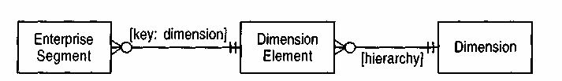

图 4.4 使用维度和维度 元素定义企业细分。

Figure 4.4 Defining enterprise segments by using dimensions and dimension elements.

这种模型允许我们在不改变模型本身的情况下增加新的尺寸，而且 体积也更小。

This model allows us to add new dimensions without changing the model. It is also more compact.

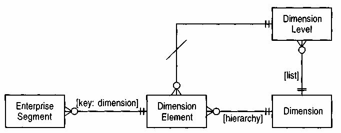

图 4.5 向图 4.4 添加维度级别。维度级别

Figure 4.5 Adding dimension levels to Figure 4.4. Dimension levels

允许我们给维度的每个层级命名。

allow us to name each level of a dimension.

例如，在 ACM 示例中，“位置”维度包含一系列维度级别：市场、区域和地区。新罕布什尔州在层级结构中定义，其父级为“东北地区”，“东北地区”的父级为“美国”，“美国”的父级为“全部”。由于新罕布什尔州位于三级之下，因此其维度级别为列表中的第三个级别：地区。

Example In the ACM example the location dimension has a list of dimension levels: market, region, and area. New Hampshire is defined in the hierarchy with parent Northeast, whose parent is USA, whose parent is all. Since it is three levels down. New Hampshire's dimension level is the third in the list: area.

##### 4.1.1 定义尺寸

我们如何定义维度？最简单的定义是，维度是指大型组织可以通过某种组织结构进行划分的方式。然而，这通常并非最令人满意的定义。根据具体情况，组织的划分方式有很多种。此外，某些维度未必适用于特定的组织系统。图 4.2 中的模型包含了 ACM 销售所在行业的划分，但这并不一定代表 ACM 内部的组织结构。

How can we define dimensions? The simplest definition is that they are the ways in which a large organization can be broken down via some organizational structure. However, that is not generally the most satisfactory definition. An organization can be broken down in many ways, depending on the situation. In addition, some dimensions are not necessarily appropriate to an organization system. The model in Figure 4.2 includes a breakdown by industry to which ACM sells, but this need not represent an organization structure within ACM.

我们可以通过查看层次结构的底层，并探究底层维度所分类的内容，来找到更好的维度定义方法。例如，ACM 专注于咖啡机的销售或租赁。我们可以根据售出的咖啡机型号、销售区域以及销售行业来对这一维度进行分类。这些维度来源于对这一核心事件的分类，即星型模式的事实表 [4]。

We can find a better way to define dimensions by looking at the bottom of the hierarchy and asking what is being classified by the dimensions there. In the example we can see that ACM is focusing on the sale or rental of a coffee machine. We can classify this dimension according to which machine was sold, which sales area sold it, and which industry it was sold into. The dimensions come from the classification of this focal event, which is the fact table of a star schema [4].

在确定此类分析中使用的维度时，首先需要了解核心事件是什么。然后，我们可以考察如何对该核心事件进行分类。从图 4.2 可以看出，核心事件涉及一个产品，该产品包含一个产品系列，该产品系列又包含一个产品组，该产品组又包含一种饮料。在销售维度上，我们可以看到区域、地区和市场。

In determining the dimensions to use in this kind of analysis, first we need to understand what the focal event is. We can then look at the ways in which this focal event can be classified. From Figure 4.2 we see the focal event involves a product that has a product family, which has a product group, which has a beverage. On the sales dimension we see area, region, and market.

这些维度和层级应由业务分析师定义；图 4.6 展示了一种有效的定义方法。如图 4.6 所示，这种结构可能会变得相当复杂。各个维度并非完全独立。例如，请注意价格范围维度与产品维度的交叉点。这表明，任何产品在产品维度和价格范围维度上都对应一个特定的父级。图 4.5 的模型需要进行修改以正确考虑这一点，但这样做是否值得值得商榷，因为它确实会使模型变得复杂一些。这个问题可以通过维度创建过程来解决。

These dimensions and levels should be defined by business analysts; Figure 4.6 shows a good way to do this. As Figure 4.6 indicates this structure can become quite complex. The dimensions are not necessarily completely independent. For example, note how the price range dimension intersects the product dimension. This indicates that any product will have one particular parent along the product and price range dimensions. The model of Figure 4.5 would need to be modified to take this into account properly, although it is questionable whether it is worth undertaking this since it does complicate the model somewhat. This issue could be handled by the dimension creation process.

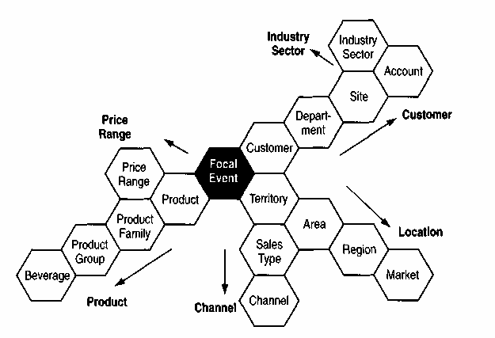

图 4.6 蒂拉克图显示了一组典型的维度和级别。

Figure 4.6 A Tilak chart showing a typical set of dimensions and levels.

如果任何层级的分支不超过六个，那么这张图就很有用。但 实际上，这种情况很少发生。

This is a useful diagram providing we do not have more than six branches from any level. In practice we rarely do.

这些维度无需细化到最低层级。在这种情况下，分析到单个销售人员的区域或单个客户可能既无意义，甚至不可能。此时，维度只需细化到底层事件即可。了解较低层级仍然很有用，这既有利于未来的发展，也有助于理解较高层级的基础。

The dimensions need not be measurable to the lowest level. In this case it might not be worthwhile, or even possible, to analyze down to an individual salesperson's territory or to an individual customer. In this case the dimensions are elaborated part of the way down to the underlying event. It is still useful to understand what the lower levels are, both for future development and to see the foundations of the higher levels.

对客户领域进行全面分析需要为该客户领域构建业务模型。这包括一个结构模型，用于严格定义各个维度。每个维度都应代表结构模型中的一条层级路径。此过程的细节超出了本章的范围。为了便于讨论，我们假设维度已经确定。

A full analysis of the customer's domain would involve producing a business model for the customer's area. This would include a structural model, which would be used to rigorously define the dimensions. Each dimension should represent a hierarchical path along the structural model. The details of this process are beyond the scope of this chapter. For the sake of discussion we will assume the dimensions have been determined.

分析系统的用户可以显式定义维度，也可以从企业数据库中获取。对于后者，每个维度都需要一个构建器操作来告知系统如何查询企业数据库。这样，系统就可以随着时间的推移向维度中添加节点。

The dimensions can be defined explicitly by the user of the analysis system. Otherwise, they can be determined from corporate databases. For the latter, each dimension needs a builder operation to tell it how to query corporate databases. This allows the system to add nodes to the dimension over time.

##### 4.1.2 维度和企业细分的属性

关于维度的一个重要规则是，较低层级维度的测量值可以正确地合并到较高层级。因此，如果我们想查看东北地区的销售收入，我们可以将东北地区所有子区域的销售额相加。

An important rule about dimensions is that the measurements for dimensions at lower levels can be properly combined into the higher level. Thus if we want to look at sales revenue for the Northeast, we can do this by adding together the values for sales for all subregions of the Northeast region.

任何已定义的尺寸都必须支持此属性。通常尺寸通过相加的方式组合，但也存在一些例外情况（参见 4.2.5 节）。

Any dimensions that are defined must support this property. Usually dimensions are combined through addition, but there are some exceptions (see Section 4.2.5).

除了通过业务结构定义的维度之外，时间也是一个常见的维度。时间维度通过将底层事件分类到特定的时间段来体现。如果这些时间段是月份，那么我们可以讨论诸如“1994 年 3 月（11-10，东北地区）的收入”之类的数据。这意味着存在一个 1994 年 3 月的维度元素，它是 1994 年维度元素的子元素。只要数据仅包含当月的数据（而非年初至今的数据），时间维度就满足上述的组合性属性。我们可以轻松地根据当月数据计算年初至今的数据，但通常无法通过沿维度进行组合来实现。

Along with dimensions defined through business structures, another common dimension is time. Time is treated as a dimension by classifying the underlying event into a time period. If these periods are months then we can talk about such figures as revenue for (11-10, Northeast, March 1994). This implies a dimension element for March 1994 that would be a child of the dimension element for 1994. The time dimension satisfies the combinability property discussed above, providing the figures are only for that month (and not year-to-date figures). We can easily calculate year-to-dates from month-only figures but typically not by combining along a dimension.

企业段与更基础的类型有一个共同的有趣特性：所有企业段在概念上都存在。我们无法在概念上“创造”数字 5、数量 5 美元或日期 1/1/2314。这些概念都存在于我们的思维中，但可能需要在计算机中创建为对象。企业段也具有这一特性。一旦所有维度及其维度元素都已指定，那么所有企业段在概念上就存在，即使它们可能并未被创建为软件对象。

Enterprise segments share an interesting property with more fundamental types: All enterprise segments conceptually exist. There is no notion of conceptually creating the number 5, the quantity $5, or the date 1/1/2314. These things all exist in our minds but may need to be created as objects in the computer. Enterprise segments share this property. Once all dimensions have been specified with their dimension elements, then all enterprise segments conceptually exist, although they may not be created as software objects.

这一共同属性引出了一个问题：企业细分是否应被视为基本类型（参见A.1.5节）。如果是，则它不应映射到任何非基本对象。维度元素和观察（继承自护理对象）均为非基本类型。虽然后者可以排除，但前者是企业细分定义的一部分，因此不能排除。保留企业细分到观察的映射也很有意义，因为一个非常常见的需求是查找给定企业细分的所有观察。综上所述，尽管企业细分具有普遍的概念存在性，但它们似乎并非基本类型。

This shared property raises the question of whether an enterprise segment should be treated as a fundamental type (see Section A.1.5). If so, it should not have any mappings to nonfundamental objects. A dimension element and an observation (inherited from an object of care) are both non -fundamental. Although the latter could be excluded, the former is part of the definition of enterprise segment and thus cannot be excluded. There is also a lot of sense in holding the mapping from an enterprise segment to an observation since a very common request is to find all observations for a given enterprise segment. In balance it seems that enterprise segments are not fundamental, despite this property of universal conceptual existence.

将企业段视为非基础组件确实会对接口产生影响。创建操作实际上是一个查找或创建操作。它首先检查所需的企业段实例是否存在；如果存在，则返回该实例；如果不存在，则创建该实例。（或者您可以将其理解为没有创建操作，而只有查找操作，该操作会在需要时静默创建实例。）

Treating enterprise segments as nonfundamental does have an effect on the interface. The create operation is really a find-or-create. It first looks to see if the required instance of the enterprise segment exists; if so it returns it, if not it creates it. (Or you can think of it as not having a create operation but only a find operation, which creates silently when it needs to.)

#### 4.2 测量方案

#### 4.2 Measurement Protocol

我们一直在讨论的企业分析会用到大量的测量数据。这些数据并非手动输入；通常情况下，它们要么是从众多数据库之一中加载，要么是根据其他测量数据计算得出。我们需要记住如何进行这些测量，也就是我们用来创建测量的协议。图 4.7 展示了测量和协议的总体框架，其中大部分内容与第三章类似。

The corporate analysis we have been discussing uses a lot of measurements. These measurements are not entered by hand; usually they are either loaded from one of many databases or calculated from other measurements. We need to remember how we can make these measurements, that is, the protocol we use to create the measurement. Figure 4.7 shows a general outline of measurement and protocols, much of it similar to that of Chapter 3.

图 4.7 展示了两种测量协议。源测量协议指的是对某个企业数据库的查询。通常情况下，对象在逻辑上知道它正在访问哪个数据库，尽管实际的命令位于另一个层。用户需要决定访问哪个数据库。计算测量协议则表示对域中已有的测量数据进行计算。

Two kinds of measurement protocol are shown in Figure 4.7. Source measurement protocols refer to queries against some corporate database. Typically an object knows logically which database it is accessing, although the actual commands are in another layer. The user should decide which data base is accessed. A calculated measurement protocol represents a calculation done on measurements already present in this domain.

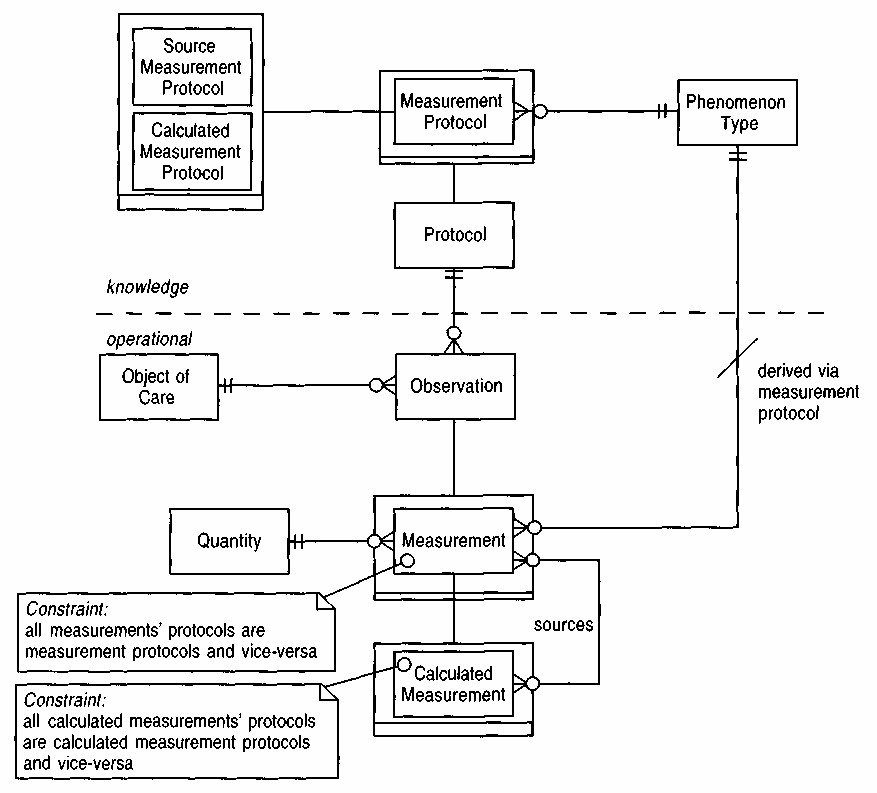

图 4.7 测量和测量协议。

Figure 4.7 Measurement and measurement protocols.

源测量数据来自数据库，计算测量数据使用 公式。

Source measurements are from a database, and calculated measurements use formulas.

该模型的一个重要特点——也反映了其临床背景——是任何现象类型都可以有多种测量方案来确定其数值。这一点可能会让一些读者感到奇怪。如果一种测量方法可以用多种方式计算，那它的意义何在？如果存在多个公式，那它肯定属于不同的现象类型。首先也是最显而易见的一点是，同一现象类型可以同时拥有计算方法和原始测量方案。我们可以在不同的时间使用不同的方案。此外，也可以存在多个原始测量方案；具体使用哪一个取决于系统的可用性。有些数据库比其他数据库更可靠，但可用性永远无法做到完美。

An important point about this model—a reflection of its clinical background—is that any phenomenon type can have several measurement protocols to determine its value. This point may strike some readers as odd. What is the point of a measurement that we can calculate in more than one way? If there is more than one formula, surely it is a different phenomenon type. The first and most obvious point is that the phenomenon type can have both calculations and source protocols. We can use different protocols at different times. There can also be multiple source protocols; which one we use depends on system availability. Some databases are more reliable than others, but availability can never be perfect.

同样，用户可以考虑使用不同的计算方法来得出同一种现象。用户选择哪种计算方法可能取决于可用的数据来源，或者取决于用户对计算中某些细微之处的理解。库存价值就是一个很好的例子。通常，库存只在年末进行实物盘点，但其价值需要在其他时间进行估算。无论哪种情况，该价值都将以相同的方式用于后续的财务信息。

Similarly the user could consider using different calculations to produce the same phenomenon type. Which calculation the user chooses can depend on which sources are available or on the user's opinion about subtle points within the calculation. A good example of this is the value of inventory. Usually inventory is physically counted only at the end of the year, but its value needs to be estimated at other times. In either case the value is used in the same way for further financial information.

该模型的一些用户可能会选择指定用于计算数值的测量协议。然而，另一些用户可能只需要一种现象类型，而让系统自动确定如何获取该值。在后一种情况下，需要某种方法来对特定现象类型的测量协议进行优先级排序。这可以通过将现象类型到测量协议的映射关系构建成一个列表来实现。列表的首项定义了首选协议，依此类推。

Some users of this model may choose to specify which measurement protocol to use to come up with a value. Others, however, may just want a phenomenon type and leave it to the system to come up with how it gets it. In the latter case some way is needed to prioritize the measurement protocols for a phenomenon type. This can be done by making the mapping from phenomenon type to measurement protocol a list. The front of the list defines the preferred protocol and so on.

请注意计算测量值的存在，以及它与其源测量值的关联。这遵循一般规则：当计算结果被视为一个对象时，它应该知道是什么计算导致了它（协议），以及该协议的输入是什么（源）。

Note the presence of calculated measurement, with its link back to its source measurements. This follows the general rule that the result of a computation, when treated as an object, should know what computation caused it (the protocol) and what the inputs to this protocol were (the sources).

##### 4.2.1 保留计算

计算得到的测量协议包含其计算公式，如图 4.8 所示。这是一个单个实例方法的示例（参见第 6.6 节）。计算得到的测量协议的公式通常非常简单，因此我们可以使用一个简单的解释器 [3]，并将公式以电子表格的形式保存。

The calculated measurement protocols include the formulas by which they are calculated, as shown in Figure 4.8. This is an example of an individual instance method (see Section 6.6). The formulas for calculated measurement protocols are often very simple, so we can use a simple interpreter [3] and hold the formulas as spreadsheet-style formulas.

该模型的一个重要特征是参数的呈现方式。每个计算测量协议都有一个参数列表。该列表代表公式中组合的各种现象类型。请注意，映射关系是一个列表。为了使公式有意义，映射关系中的元素必须是可识别的。列表是实现这一点的有效方法。或者，也可以使用字符串作为键。

An important feature of the model is the way the arguments are presented. Each calculated measurement protocol has a list of arguments. This list represents those phenomenon types that are combined in the formula. Note that the mapping is a list. For the formula to make sense, the elements in the mapping must be identifiable. A list is a good way to do this. Alternatively they can be keyed by a string.

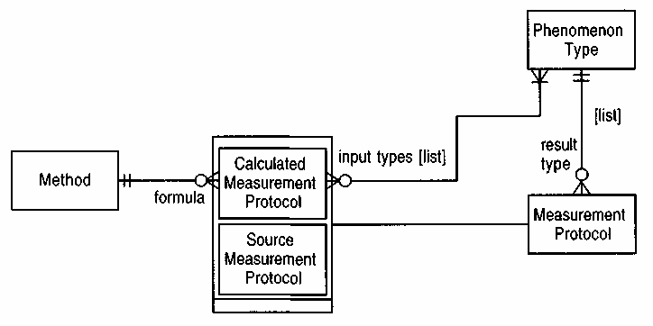

图 4.8 计算测量方案的方法。

Figure 4.8 Methods for calculated measurement protocols.

例如，销售收入是一种现象类型，其测量协议为因果计算。因果计算的参数是两个现象类型的列表——销售数量和平均价格。计算方法是公式 arg[1]*arg[2]。

Example Sales revenue is a phenomenon type with a causal calculation as its measurement protocol. The arguments to the causal calculation are a list of two phenomenon types—number of sales and average price. The method is the formula arg[1]*arg[2].

例如，身体质量指数（BMI）是医学上的一种现象类型。它通过体重和身高这两个参数进行因果计算。计算方法为：体重/身高²。

Example Body mass index is a phenomenon type in medicine. It has a causal calculation with arguments of weight and height. The method is the formula weight/height2.

##### 4.2.2 比较和因果测量方案

在企业财务应用中，衡量指标并非绝对值。用户通常不太关心收入是 x 美元这样的具体数字，他们更关心实际收入与计划收入之间的差异，或者今年的收入与去年的收入相比如何。

In a corporate finance application the measurements are not absolute values. The users are usually not too interested in a figure that says revenues are $x, rather they are interested in the difference between the actual and a planned figure or this year's revenues compared to last year's.

为了考虑这些比较性测量，我们需要描述可能出现的各种测量类型。典型的比较是实际值与先前值或计划值之间的比较。先前值可以通过查看适用时间参考（参见第 3.8 节）或查找具有先前时间维度的企业细分测量值来考虑。计划测量要求我们区分实际值和计划值，这对应于第 3.10 节中讨论的主动观测值和预测观测值。此外，预测观测值必须记录预测的来源计划，以便我们能够区分年度计划、季度预测等，如图 4.9 所示。

To consider these comparative measurements, we need to describe the various kinds of measurements that can appear. Typical comparisons are between an actual value and either a prior or a planned value. Prior values can be considered by either looking at the applicability time reference (see Section 3.8) or by looking for a measurement for the enterprise segment that has a prior time dimension. Planned measurements require us to make a distinction between actual or planned values, which correspond to the ac tive and projected observations discussed in Section 3.10. In addition, the projected observation must record what plan was the source for the projection, so that we can distinguish between annual plans, quarterly forecasts, and the like, as shown in Figure 4.9.

至此，两种计算方式之间的根本区别应该显而易见。一种是基于其他现象类型的值来确定某一现象类型的值。例如，我们可以通过将销售数量乘以平均价格来计算销售收入。这种计算方式被称为因果计算，因为它遵循原因。

At this point a fundamental distinction between two types of calculation should be apparent. One kind is determining a value for a phenomenon type based on values of other phenomenon types. For example, we can calculate sales revenue by multiplying the number of sales by the average price. This type of calculation is called a causal calculation because it follows the cause

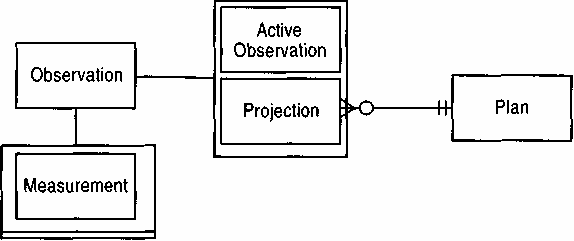

图 4.9 支持计划值和实际值的观测类型。

Figure 4.9 Kinds of observations to support planned and actual values.

以及效应分析。因果计算可以包含任意数量和任意关系的输入现象类型，并且计算公式可以是任意表达式。

and effect analysis. Causal calculations can have any number and any relationship of input phenomenon types, and the formulas by which they are computed can be any expression.

另一方面，比较计算则更具结构性。它们总是包含两个输入测量值，且这两个测量值必须属于同一现象类型。输出测量值的现象类型总是由计算公式和输入现象类型决定的。因此，如果我们考察的是销售数量的偏差，那么输入值就是销售数量这一现象类型，而输出值就是销售数量的偏差这一现象类型。这些计算的公式通常比较有限，例如绝对偏差 (xy) 或百分比偏差 ((xy)/y)。

Comparative calculations, on the other hand, are more structured. They always have two input measurements, which must be of the same phenomenon type. The output measurement's phenomenon type is always derived from the form of the calculation and the input phenomenon type. Thus if we are looking at the deviation of number of sales, then the inputs will be the phenomenon type number of sales and the output phenomenon type will be deviation for number of sales. The formulas for these calculations will generally be of a fairly limited set: such things as absolute deviation (x-y) or percentage deviation ((x-y)/y).

这两种计算类型之间的差异可以通过对计算测量协议进行子类型化来形式化，如图 4.10 所示。计算测量协议包含结构的关键元素。每个计算测量协议都有一个结果类型和若干输入类型。对于比较计算，它们仅限于两个参数，且这两个参数必须是同一现象类型。所有计算测量协议都有一个方法，该方法包含根据输入计算新值的公式。两个协议可以共享同一个方法，例如，所有用于确定所有现象类型绝对偏差的协议都共享方法 argl-arg2。事实上，这种情况非常常见，因此值得为此创建一个特殊的子类型，将方法与类型绑定。

The differences between these two types of calculations can be formalized by subtyping the calculated measurement protocol, as shown in Figure 4.10. The calculated measurement protocol carries the key elements of the structure. Each calculated measurement protocol has a single result type and a number of input types. For comparative calculations they are limited to two arguments, which must be the same phenomenon type. All calculated measurement protocols have a method that contains the formula by which a new value is calculated from the inputs. Two protocols can share a single method, for example the method argl-arg2 is shared between all the protocols that determine absolute deviation for all the phenomenon types. Indeed, this case is so common it is worth making a special subtype for it that fixes the method to the type.

##### 4.2.3 状态类型：定义计划状态和实际状态

由源测量协议或计算测量协议确定的测量值始终通过其测量协议进行计算。测量协议为测量提供了一种出厂方法[3].1 客户要求

Measurements determined by source or calculated measurement protocols are always calculated through their measurement protocol. The measurement protocol provides a factory method for the measurement [3].1 A client asks the

请注意，造成这种情况的原因是创建方法不同，而不是最终结果的类型不同。这是除了 Gamma eta/ [3J. 指出的原因之外，使用工厂方法的另一个原因。

Note that the reason for this is that the method of creation varies, rather than the type of the final result. This is another reason to use the factory method in addition to those indicated by Gamma eta/ [3J.

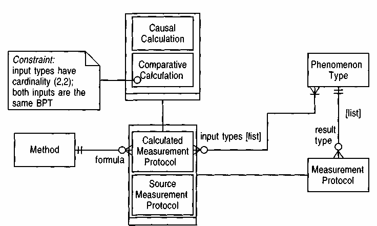

图 4.10 计算类型，如计算测量协议所示。

Figure 4.10 Types of calculation as shown by calculated measurement protocols.

因果计算将不同现象类型联系起来，比较计算则显示 同一现象类型在不同状态类型之间的差异。

Causal calculations link different phenomenon types, and comparative calculations show the difference in one phenomenon type between status types.

测量方案用于创建测量结果。客户需要告知测量方案其参考的护理对象。客户还需要告知方案该值是实际值还是计划值：计划值对应哪个计划，实际值对应哪个日期。

measurement protocol to create a measurement. The client needs to tell the measurement protocol what object of care it needs to reference. The client also needs to tell the protocol whether it is an actual or planned value: which plan for the planned value or which date for the actual value.

此时，图 4.9 所示的模型暴露出一个缺陷。我们无法以简单的方式提供协议所需的信息。图 4.9 确实提供了一种从现有测量中确定此信息的有效方法，但它没有提供一种便捷的单一方法来请求该信息。图 4.11 所示的模型可以克服这一缺陷，该模型将这些属性整合到一个状态类型中。抽象状态类型包含两个子类型。实际状态类型可能具有时间偏移。对于当前值，将没有偏移（或偏移量为零）。六个月前或一年前将具有相应的偏移量。计划状态类型具有相应的计划，就像预测一样。

At this point the model shown in Figure 4.9 shows a weakness. There is no simple way we can provide the information needed for the protocol. Figure 4.9 does provide a good way to determine this information from an exist ing measurement, but it does not provide a convenient single way to ask for the information. This can be overcome by the model shown in Figure 4.11, which puts these properties together into a single status type. Two subtypes exist of the abstract status type. Actual status types may have a time offset. For current values there will be no offset (or it can be zero). Six months or one year ago will have the appropriate offset. Planned status types have the appropriate plan, just like projections.

例如，一家公司评估四种财务数据：实际值、上年值、年度计划和最新季度预测。实际值属于“实际”状态类型，时间偏移量为零。上年值属于“实际”状态类型，时间偏移量为一年。年度计划属于“计划”状态类型，与年度计划关联。季度预测也属于“计划”状态类型，与最新季度预测关联。所有季度预测都是计划的实例。

Example A corporation assesses four kinds of financials: actual value, prior year, the annual plan, and the latest quarterly forecast. The actual would be an actual status type with time offset of zero. The prior year is an actual with time offset of one year. The annual plan is a planned status type linked to the annual plan. The quarterly forecast is also a planned status type linked to the latest quarterly forecast. All the quarterly forecasts are instances of the plan.

实际上，我们已经将我们所观察到的观察类型的信息从观察本身转移到了一个单独的类型中。这种类型可以枚举

Effectively we have moved the knowledge of what kind of observation we have from the observation itself to a separate type. This type can enumerate

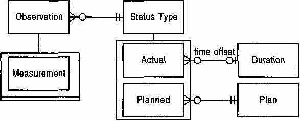

图 4.11 状态类型，作为图 4.9 的替代方案。

Figure 4.11 Status types as an alternative to Figure 4.9.

这种替代方法更容易指定所需的比较测量类型 （见图 4.12）。

This alternative makes it easier to specify the kind of comparative measurement required (see Figure 4.12).

所有可能的变异都独立于现有观测结果。类型存在于知识层面，因此我们可以计算新的测量值，但它并非必须存在于知识层面。我们应该注意到，这与图 4.9 中的模型并不矛盾。两种表达方式略有不同，但意思相同，而且两者都可以同时成立。

all possible variations independently of existing observations. The type resides at the knowledge level so we can calculate new measurements, but it need not be at the knowledge level. We should note that this is not inconsistent with the model in Figure 4.9. Both expressions say the same thing, in slightly different ways, and both could be supported at the same time.

现在，客户端只需指定测量协议的状态类型，即可获得创建测量所需的足够信息（假设该协议是因果协议）。比较计算需要两种状态类型，每个输入对应一种。一种解决方法是修改创建测量操作，使其对因果测量需要一种状态类型，对比较测量需要两种状态类型。另一种方法是允许使用比较状态类型，如图 4.12 所示。我更倾向于后一种方法，因为比较本身就是一个独立的对象，而且创建所有测量的接口都相同。

Now the client needs only to specify the status type for the measurement protocol to have enough information to create the measurement, assuming the protocol is a causal protocol. Comparative calculations need two status types, one for each input. One way of dealing with this is to vary the create measurement operation so that it requires one status type for causals and two for comparative measurements. Another method is to allow comparative status types, as shown in Figure 4.12. I prefer the latter method because the comparison is now an object in its own right, and the interface for creating all measurements is the same.

例如， ACM 管理层希望查看实际销售收入与计划销售收入的偏差。为了满足此需求，模型必须包含销售收入现象类型和销售收入偏差现象类型。销售收入偏差是通过比较计算得出的，计算方法为 arg[1] - arg[2]。该请求会创建一个销售收入偏差的观测值，其状态类型为比较型。该状态类型的数据项为计划数据，比较对象为实际数据。

Example ACM management wants to see the actual vs. planned deviation for sales revenue. To satisfy this request, the model must include a phenomenon type for sales revenue and a phenomenon type for sales revenue deviation. The sales revenue deviation is a comparative calculation with a method of arg[l] -arg[2].The request creates an observation of sales revenue deviation with a comparative status type. The status type will have datum of planned and comparator of actual.

##### 4.2.4 创建测量

现在我们知道了如何请求新的测量值，我们可以看看创建测量值的过程，如图 4.13 和 4.14 所示。该过程分为三个步骤：查找参数、执行公式以及使用结果值创建新的测量对象。

Now that we know how to ask for a new measurement, we can look at the process for creating a measurement, which is illustrated in Figures 4.13 and 4.14. The process has three steps: finding the arguments, executing a formula, and creating a new measurement object with the resulting value.

参数查找操作是多态的，取决于我们采用的是因果测量协议还是比较测量协议。如图 4.15 所示，因果协议需要找到所有相同状态类型的测量值。

The argument-finding operation is polymorphic depending on whether we have a causal or comparative measurement protocol. The causal protocol, shown in Figure 4.15, needs to find all measurements of the same status type

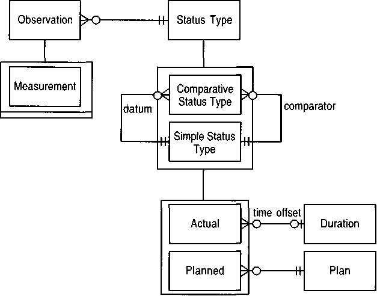

图 4.12 使用比较状态类型来简化比较 测量的规范。

Figure 4.12 Using comparative status types to ease the specification of comparative measurements.

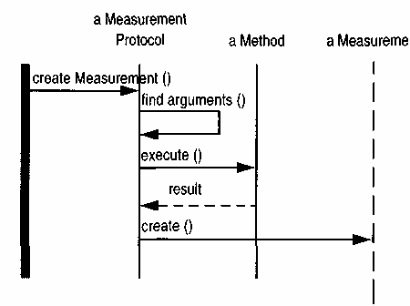

图 4.13 创建测量的交互图。

Figure 4.13 Interaction diagram for creating a measurement.

以及观察对象的现象类型与协议的输入类型相匹配。如图 4.16 所示，比较公式寻找两个测量值，它们的现象类型与输入类型相同，观察对象相同，并且它们的状态类型分别是协议的数据和比较对象。

and object of care whose phenomenon types match the input types of the protocol. The comparative formula, shown in Figure 4.16, looks for two measurements whose phenomenon type is that of the input type, who have the same object of care, and whose status types are the datum and comparator for the protocol.

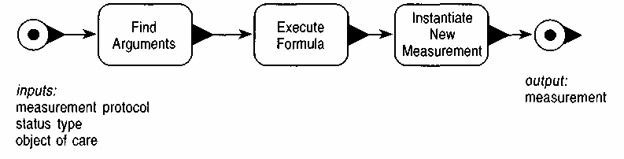

图 4.14 事件图，描述了创建测量的过程。

Figure 4.14 Event diagram that describes the process for creating a measurement.

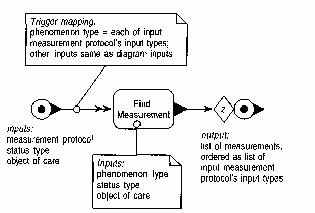

图 4.15 因果计算的查找参数操作。

Figure 4.15 The find arguments operation for a causal calculation.

此操作会找到每种参数类型的度量值，其他所有因素都保持 不变。

This operation finds a measurement for each argument type with all other factors the same.

找到参数后，我们可以将它们传递给公式，然后用结果值创建一个度量值。

When we have found the arguments, we can pass them on to the formula and then create a measurement with the resulting value.

##### 4.2.5 尺寸组合

第三种计算方法是对某一维度上的值进行组合。例如，上面提到的东北地区的销售收入计算方法是将东北地区所有子区域的销售额相加。更准确地说，对于指向东北地区的某个企业细分，其现象类型的度量值是通过查找所有指向东北维度元素子区域但其他维度元素相同的企业细分所对应的该现象类型的度量值来计算的。将这些值相加即可得到新的值。

A third kind of calculation is the combination of values along a dimension. The example mentioned above was that of calculating sales revenue for the Northeast by adding together the values for sales for all child regions of the Northeast region. More precisely, the measurement of a phenomenon type for an enterprise segment that refers to Northeast is calculated by finding all measurements of that phenomenon type attached to enterprise segments that refer to child regions of the Northeast dimension element but have the same dimension elements along the other dimensions. These values are added together for the new value.

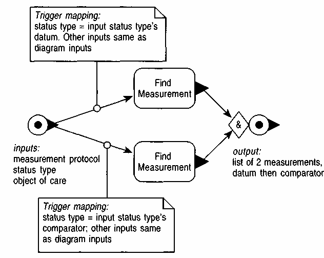

图 4.16 查找参数操作用于比较计算。

Figure 4.16 The find arguments operation for comparative calculations. This

该操作为比较状态类型的每个分支找到一个参数。

operation finds one argument for each leg of the comparative status type.

因此，我们可以添加如图 4.17 所示的维度组合协议。我们必须指定要组合的维度。该计算不需要任何输入类型（因为它始终与输出类型相同）。我们可以考虑将输入类型映射的基数降低到零，但我认为通过保持映射的强制性并添加约束，我们可以更好地保持逻辑清晰。创建度量遵循如图 4.14 所示的常规步骤，其中查找参数的操作再次进行了修改，如图 4.18 所示。计算方法的作用非常简单：它获取所有参数并将它们相加。通常使用加法进行组合，但并非总是如此。例如，平均价格这种现象类型不会在维度组合中相加；而是计算平均值。这些变化取决于现象类型，因此每种现象类型都需要一个组合方法。计算方法将组合方法应用于参数以确定结果。

We can thus add a dimension combination protocol as shown in Figure 4.17. We must specify the dimension that is being combined. The calculation does not need any input types (since it is always the same phenomenon type as the output type). We could consider reducing the input type mapping's cardinality to zero, but I think we can preserve the sense better by keeping the mapping mandatory and adding a constraint. Creating the measurement follows the usual steps shown in Figure 4.14, with the find arguments operation again being altered as in Figure 4.18. The role of the calculation method is very simple: It takes all the arguments and adds them together. Usually addition is used for combining, but not always. For example, the phenomenon type average price is not added in dimension combination; instead a mean is found. These variations depend on the phenomenon type, so each phenomenon type needs to have a combi nation method. The calculation method applies the combination method to the arguments to determine the result.

请注意，比较和维度组合协议可以自动生成。对于维度组合，可以为每种现象类型和维度的组合定义一个协议。对于比较计算，可以为每种现象类型和比较计算类型的组合定义一个协议。

Note that the comparative and dimension combination protocols can be automatically generated. For dimension combination, one protocol can be defined for each combination of phenomenon type and dimension. For comparative calculations, one protocol can be defined for each combination of phenomenon type and kind of comparative calculation.

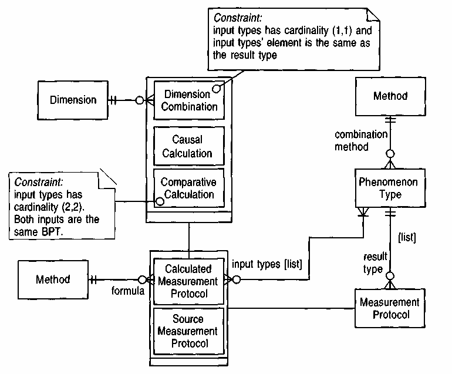

图 4.17 将维度组合添加到计算测量协议中。

Figure 4.17 Adding dimension combination to the calculated measurement protocols.

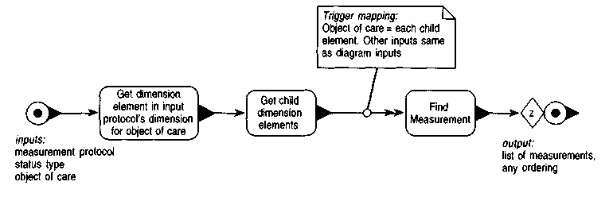

图 4.18 维度组合计算的查找参数操作。

Figure 4.18 The find arguments operation for dimension combination calculations.

此操作会找到每个子企业细分市场沿指定 维度的度量值。

This operation finds a measurement for each child enterprise segment along the indicated dimension.

计算测量在医疗保健领域同样有用。我们之所以在本章而非第三章讨论计算测量，主要是因为它们在我们公司金融领域的研究中被广泛应用。因此，它们可以说明将模型应用于不同领域会引发更多思考，而这些思考很可能会反过来应用于原领域。

Calculated measurements are just as useful in health care. We discuss cal culated measurements in this chapter, rather than in Chapter 3, primarily because they were used extensively in our work on corporate finance. Thus they are an illustration of how taking a model to a different domain causes more thought that may well feed back into the original domain.

#### 4.3 射程

#### 4.3 Range

到目前为止，我们已经探讨了如何利用计算得出和来源明确的指标来分析公司的财务业绩。指标衡量标准为我们提供了一种定量分析这些信息的方法。然而，为了理解海量数据，将指标分组通常很有帮助。例如，我们可以将绝对收入划分为若干区间，或者将所有低于基准值10%的比较指标标记为问题。

So far we have looked at how we can use measurements, both calculated and sourced, to investigate a company's financial performance. The measurement protocol pattern gives us a way of looking at this information quantitatively. To make sense of a forest of numbers, however, it is often useful to group measurements into categories. We might want to divide the absolute revenues into a number of bands, or we could highlight as problems all comparative measurements that are 10 percent below the datum.

第一步是描述测量范围，这也是本模式的主题。第二步是将这些范围与更广泛的观测系统联系起来，我们将在4.4节中讨论。

Our first step is to describe ranges of measurements, which is the subject of this pattern. The second step is to link these ranges into the broader system of observations, as we will discuss in Section 4.4.

我们经常需要存储一系列值。这些值可以是数字（例如 1..10）、日期（例如 1995 年 1 月 1 日.. 1995 年 5 月 5 日）、数量（例如 10..20 千克）甚至是字符串（例如 AAA..AGZ）。通常，我们会将范围定义在使用该范围的数据类型上，并为该数据类型分别设置上限值和下限值，如图 4.19 所示。

We often come across the need to hold a range of some values. The range can consist of numbers (such as 1..10), dates (such as 1/1/95..5/5/95), quantities (such as 10..20kg) or even strings (such as AAA..AGZ). Usually a range is placed on the type that is using it by giving that type separate mapping for an upper and lower value, as shown in Figure 4.19.

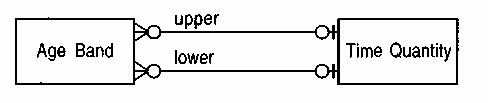

图 4.19 表示使用该类型的范围及其上限和下限。

Figure 4.19 Representing a range with upper and lower bounds on the type that uses it.

不建议对范围采用这种方法；请改用范围类型。

/ do not recommend this approach to ranges; use a range type instead.

这种方法的缺点在于，范围的概念远不止于上限值和下限值。我们可能想知道某个特定值是否在某个范围内，两个范围是否重叠，两个范围是否相邻，或者一组范围是否构成一个连续范围。这种行为需要为每个具有上限值和下限值的类型重复实现。解决方案是将范围本身作为一个对象，如图 4.20 所示。在这种情况下，所有与范围相关的功能都包含在范围对象内部，无需在其他使用范围的类型中重复实现。

The problem with this approach is that there is rather more to ranges than just an upper and lower value. We might want to know whether a particular value is within a range, whether two ranges overlap, whether two ranges abut, or whether a set of ranges form a continuous range. Such behavior would have to be copied for every type that has upper and lower values. The solution is to make the range an object in its own right, as shown in Figure 4.20. In this situation all responsibilities which are essentially about ranges are contained within the range, and do not need to be duplicated in those types that use ranges.

一般来说，任意两个量之间都可以形成一个范围。量本质上是一种定义了比较运算符（>、<、=、>、<）的类型。

In general a range can be formed between any two magnitudes. A magnitude, in essence, is a type that defines the comparative operators (>, <, =, >, <).

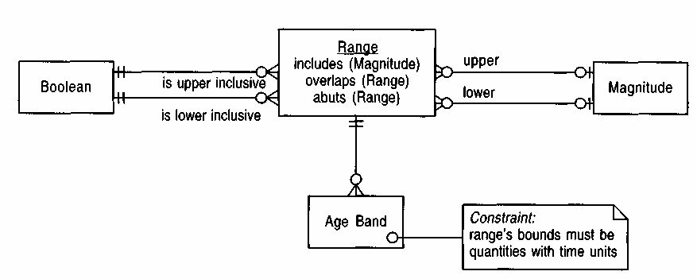

图 4.20 使用显式范围对象。

Figure 4.20 Using an explicit range object.

当需要设置上限值和下限值时，必须这样做。上限值和下限值的 映射是可选的，因此允许使用开放式范围，例如小于 6 个月。 布尔值用于区分小于 6 个月和小于等于 6 个 月的情况。

This should always be done when an upper and lower value are needed. Upper and lower mappings are optional, thus allowing open-ended ranges, such as less than 6 months. The Booleans are needed to differentiate less than 6 months from less than or equal to 6 months.

范围只需要定义其关键操作：包含、重叠和相邻。使用范围时，使用类型通常会指示其范围所需的量级类型。有几种方法可以对所需的量级类型进行建模。一种方法是声明子类型，例如我使用时间段（量级为时间点的范围）的方式。另一种方法是使用约束，如图 4.20 所示。第三种方法是使用类似参数化类的方法，其中整数范围由名为 range<Integer> 的类型定义。从概念上讲，所有这些建模技术都是等价的，因此我们可以选择任何我们认为最简单的方法。在实现中，我们需要更谨慎地选择，并且权衡取舍会因实现环境而异。概念模型的选择并不意味着对实现方式有任何影响。

The range needs only these operations to define its own key operations: includes, overlaps, and abuts. When a range is used, the using type usually indicates what kind of magnitudes it wants in its range. There are several ways of modeling which kind of magnitude is required. One way is to declare a subtype, such as I do with time period (a range whose magnitudes are time-points). Another way is to use a constraint, as in Figure 4.20. A third way is to use something along the lines of parameterized classes, where a range of integers is defined by a type called range<Integer>. Conceptually all of these modeling techniques are equivalent, so we can use whatever we find the easiest. In implementation we need to choose more carefully, and the trade-offs vary depending on the implementation environment. The choice of conceptual model does not imply anything about the implementation.

#### 4.4 具有范围的现象

#### 4.4 Phenomenon with Range

范围为我们提供了一种定义测量类别的方法。现在我们需要将它们与更广泛的观测和测量模型联系起来。为此，我们可以构建特定现象类型的现象。如果我们的现象类型是收入百分比偏差，那么我们可以构建收入问题现象，当收入百分比偏差小于-10%时，该现象就存在。这意味着，-12%的收入百分比偏差测量值也意味着存在收入问题这一类别的观测值（参见3.5节）。

Ranges give us a way to define categories of measurements. We now need to link them into the broader model of observation and measurement. To do this, we can form phenomena of certain phenomenon types. If our phenomenon type is revenue percentage deviation, we can form a phenomenon of revenue problem, which exists when our revenue percentage deviation is less than -10 percent. This implies that a measurement of-12 percent of revenue percentage deviation also implies a category observation (see Section 3.5) of revenue problem.

我们首先需要回答的问题是，这里存在一个还是两个观测值。根据图 3.9 所示的模型，观测值要么是测量值，要么是类别观测值，二者不可兼得。我们可以使用图 4.21 所示的模型，允许单个观测值同时具备这两种属性。模型的选择取决于我们是将概念过程视为首先进行测量，然后再单独观察收益问题（这意味着使用图 3.9），还是将测量和观察视为一个过程。对于此类简单情况，我合作过的领域专家更倾向于后者。

The first question we need to answer is whether there are one or two observations. According to the model shown in Figure 3.9, observations are either measurements or category observations, they cannot be both. We can allow a single observation to be both by using the model shown in Figure 4.21. The choice between the models depends on whether we consider the conceptual process as being first a measurement and then a separate step of observing the revenue problem (which implies using Figure 3.9), or whether we see the measurement and observation as one process. For simple cases such as these, the domain experts I have worked with preferred the latter.

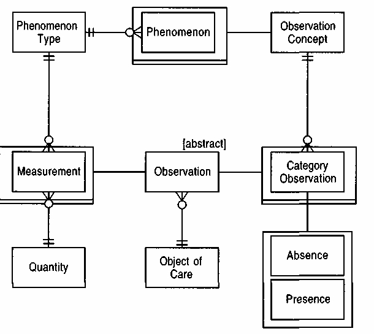

图 4.21 允许一个观察结果既是测量结果又是类别观察结果。

Figure 4.21 Allowing an observation to be both a measurement and a category observation.

该[摘要]声明暗示，一个观察结果必须至少是其子类型之一。

The [abstract] statement implies that an observation must be at least one of its subtypes.

既然我们已经有了明确的范围，那么让计算机自动将任何此类测量结果与相关现象联系起来似乎就顺理成章了。为此，我们需要一种方法来定义知识层级内的范围。

Since we have a well-defined range, it seems natural to let the computer automatically link any such measurement to the relevant phenomenon. To do this we need a way of defining the range within the knowledge level.

##### 4.4.1 具有范围属性的现象

最简单的方法是为现象添加一个范围，如图 4.22 和 4.23 所示。这样，当我们创建一个测量值时，就可以检查它是否落在该测量值所属现象类型的任何现象的范围内。我们需要考虑是否希望现象类型的范围互不重叠或完整。这两种情况都表明需要添加约束。

The simplest approach is to add a range to a phenomenon, as shown in Figures 4.22 and 4.23. Then when we create a measurement we can look to see if it falls in the range for any phenomenon of that measurement's phenomenon types. We do have to consider whether we want the range for a phenomenon type not to overlap or to be complete. Either of these conditions indicate the need for a constraint.

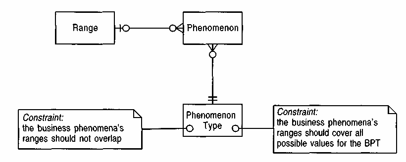

图 4.22 为现象添加范围。

Figure 4.22 Adding a range to a phenomenon.

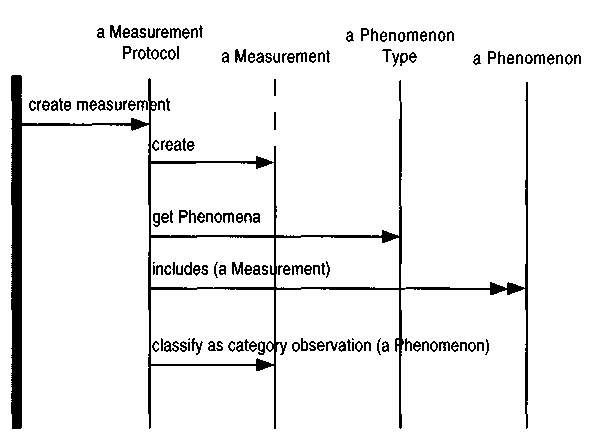

测量协议会生成测量结果。

The measurement protocol creates a measurement.

它询问其现象的类型。

It asks its phenomenon type for its phenomena.

它会询问每一种现象是否包含新的测量方法。

It asks each phenomenon if it includes the new measurement.

如果是这样，则将该测量结果归类为血压的类别观察。

If so, it classifies the measurement as a category observation of the BP.

图 4.23 创建测量和检查现象的交互 图 。

Figure 4.23 Interaction diagram for creating a measurement and checking the phenomena.

检验现象的责任 完全可以由测量对象承担。我 更倾向于协议，因为我认为协议更容易被修改。

The responsibility for checking the phenomena could be done equally well by the measurement object. I prefer the protocol, as I think that is a more likely place for overriding.

例如，收入百分比偏差分为四类：大于 5% 为良好，5% 至 -5% 为尚可，-5% 至 -10% 为警告，小于 -10% 为问题。这可以表示为收入百分比偏差 (RPD) 现象类型的四种情况。良好 RPD 现象的范围没有上限，下限为 5；尚可 RPD 现象的范围上限为 5，下限为 -5；警告 RPD 现象的范围上限为 -5，下限为 -10；问题 RPD 现象的范围上限为 -10，没有下限。重要的是要准确检查边界值，并将此信息包含在范围内；因此，我们需要问：5% 正好是良好 RPD 还是尚可 RPD？

Example Revenue percentage deviation is divided into four categories: greater than 5% is good, 5% to -5% is OK, -5% to -10% is warning, and less than -10% is a problem. This can be represented as four phenomena for the phenomenon type revenue percentage deviation (RPD). The phenomenon good RPD has a range with no upper bound and 5 lower bound, the phenomenon OK RPD has a range with upper bound 5 and lower bound -5, the phenomenon warning RPD has a range with upper bound -5 and lower bound -10, the phenomenon problem RPD has a range with upper bound -10 and no lower bound. It is important to check exactly what the boundaries are and include this information in the ranges; so we ask if exactly 5% is good RPD or OK RPD?

例如，体重指数（BMI）用于定义四个群体：正常（20-25 kg/m²）、超重（25-30 kg/m²）、肥胖（30-40 kg/m²）和病态肥胖（>40 kg/m²）。对于BMI这一现象类型，这可以表示为四种现象。超重现象的范围下限为25 kg/m²，上限为30 kg/m²。其他每种现象的范围也类似。

Example Body mass index is used to define four groups: normal 20-25 kg/m2, overweight 25-30 kg/m2, obese 30-40 kg/m2, morbid obese >40 kg/m2. This would be represented as four phenomena for the phenomenon type body mass index. The overweight phenomenon would have a range with lower bound 25 kg/m2 and upper bound 30 kg/m2. Each of the other phenomena would have similar ranges.

##### 4.4.2 范围函数

另一种方法是创建一个单独的范围函数作为关联函数的子类型，如图 4.24 和 4.25 所示。当不同的范围取决于观测概念所描述的上下文时，这种方法非常有用。该模型允许存在多个范围序列，具体取决于适用的观测概念。范围函数会像关联函数一样评估参数的某种表达式，但还会检查测量值是否落在某个现象类型的范围内。如果两者都为真，

An alternative approach is to create a separate range function as a subtype of associative function, as shown in Figures 4.24 and 4.25. This is useful when different ranges apply, depending on the context described by an observation concept. This model allows several series of ranges to be present, depending on which observation concepts apply. The range function evaluates some expression of the arguments, as in an associative function, but also checks whether the measurement falls in the range over a phenomenon type. If both are true,

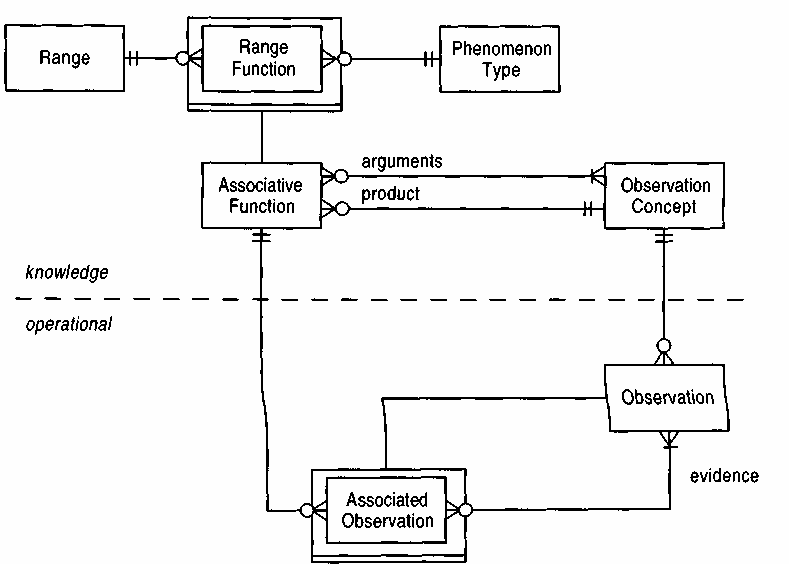

图 4.24 范围函数。

Figure 4.24 Range function.

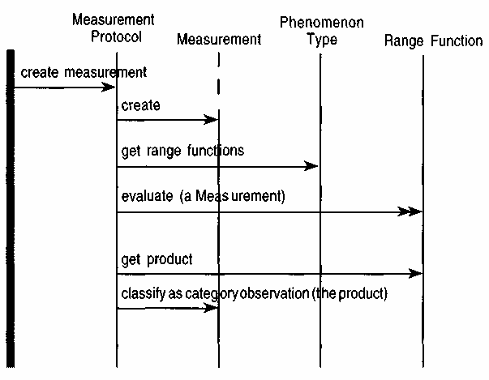

测量协议会生成测量结果。

The measurement protocol creates a measurement.

它询问其现象类型以确定其范围函数。

It asks its phenomenon type for its range functions.

它使用新的测量值评估每个范围函数。

It evaluates each range function with the new measurement.

如果评估结果为真，则找到范围函数的乘积，并将测量结果分类为该乘积的类别观测值。

If the evaluation returns true, it finds the range function's product and classifies the measurement as a category observation of that product.

图 4.25 创建 测量 和检查 范围功能。

Figure 4.25 Creating a measurement and checking range functions.

那么，产品观测概念就适用了。建立约束条件以确保对于任何给定的测量值只有一个量程函数成立，比直接将量程应用于现象要困难得多。

then the product observation concept applies. Developing constraints to ensure that only one range function will be true for any given measurement is considerably more difficult than when ranges are applied directly to phenomena.

例如，正常人β-HCG值范围会随着怀孕而升高。为了表示这一点，我们可以用两个范围函数来表示正常β-HCG值。一个函数的参数为怀孕状态，另一个函数的参数为非怀孕状态。这两个范围函数的现象类型均为β-HCG。

Example The normal range of a person's beta HCG increases with pregnancy. To represent this, we would have two range functions with the product normal beta HCG. One would have arguments of pregnancy and the other arguments of nonpregnancy. The phenomenon type on the range functions would be beta HCG.

这两种方法各有优点，也可以结合使用。直接关联现象无疑是最简便的方法，如果这种方法能够准确描述情况，就应该使用它。范围函数虽然更复杂，但可以表示更复杂的情况。因此，尽可能使用直接关联现象的方法，而只有在必须使用范围函数时才应该使用。如果情况比这里描述的模型所能处理的更加复杂，则应该向范围函数添加特征，可以直接添加，也可以通过子类型添加。

Both of these approaches have their merits, and it can be plausible to use them both together. Linking directly to the phenomenon is certainly the easiest way of doing it, and that is the one to use if it correctly describes the situation. Range functions are more complex but can represent more complicated situations. So you should use the direct link to phenomenon when you can and range functions when you must. If the situation gets more complex than the models described here can handle, you should add features to range function, either directly or by way of a subtype.

#### 4.5 使用所得框架

#### 4.5 Using the Resulting Framework

到目前为止，本章描述的模式都是对第三章介绍的模式的扩展。现在我们可以看看如何使用这些模型。

So far this chapter has described patterns that represented expansions of those introduced in Chapter 3. Now we can look at how we can use these models.

我们首先来看一下ACM的总收入。这项指标的企业级划分涵盖整个公司；也就是说，企业级划分的所有维度元素都位于维度层级的顶端。该指标通常不是绝对值，而是与某个计划或先前时间段的比较值。此外，如果存在问题，可以通过根据一系列现象进行突出显示来表明。分析师接下来会着手寻找由这些现象定义的问题观察结果。

We begin by looking for the total revenue for ACM. This would be a measurement whose enterprise segment is the whole company; that is, the enterprise segment's dimension elements are all at the top of the dimension hierarchies. The measurement normally would not be an absolute value; rather it would be a comparative value with some plan or prior time period. Furthermore, the fact that it is a problem might be indicated by highlighting it according to a ranged phenomenon. The analyst would then begin by looking for problem observations defined by phenomena.

为了确定问题出在设备销售收入上，我们需要回溯总收入的因果关系计算，即销售收入减去销售成本。请注意，因果关系计算仅指明了一种可能的分析路径，无论该指标是否以此方式确定。最终数据可能实际上来源于数据库。（由于数据质量不佳，其结果可能与公式计算结果不完全吻合。）

To identify that the problem is with equipment sales income, we need to roll back the causal calculation of total revenue as sales income minus sales cost. Note that the causal calculation indicates a possible path of analysis, whether or not the measurement was determined that way. It may be that this final figure was actually sourced from a database. (Due to dirty data, it may be that it doesn't exactly fit the result of the formula.)

下一步是使用维度组合协议。沿着位置维度观察，可以发现东北地区的偏差明显较高。现在我们可以重点关注在位置维度上指向东北维度元素，并且在所有其他维度上都位于顶部的企业细分。重复此过程两次，即可找到位置为东北、产品属于1100系列、行业为政府的企业细分。

The next step is to use dimension combination protocols. Looking along the location dimension shows that the Northeast segment had a noticeably higher deviation. We can now focus on the enterprise segment that points to the Northeast dimension element on the location dimension, and at the top for all other dimensions. Repeating this process two more times would lead us to the enterprise segment with location of Northeast, product of 1100 family, and industry sector of government.

这里存在一定的间接性。当涉及比较计算时，路径可能并非直接。总收入偏差可能并非通过销售收入偏差减去销售成本偏差来计算。更可能的情况是，分别计算实际销售收入和计划销售收入，然后将它们用于因果分析。对于绝对偏差，两种方法都适用，但对于百分比偏差则不然。是否存在相关规范将决定哪些计算方法适用，哪些不适用。

There is a certain amount of indirection here. When comparative calculations are involved, the route may not be direct. It may not be that the deviation in total revenue is calculated by subtracting the deviation in sales cost from the deviation in sales income. A more likely scenario is that the separate actual and planned sales revenues are calculated, and then these are used in the causal. With absolute deviation, either route will work, but this is not true for percentage deviation. The presence or absence of protocols will indicate what will and will not be appropriate calculations.

我们可以使用其他方法。与其先进行因果分析，再进行维度组合，不如先分解位置维度，然后进行因果分析，再分解其他维度。分析方法有很多种，这些方法不必与计算数据时所用的方法相同。

We can use alternative routes. Instead of first doing the causal, and then dimension combinations, we could break down on the location dimension, then use a causal, and then other dimension breakdowns. There are many possible paths for analysis, and these need not be the same as those used for calculating the figures.

我们可以使用第 3.11 节中描述的关联函数来描述定性陈述，例如“强大的竞争对手可能会导致销售额下降”。定性和定量观察通过分配范围现象联系起来。

We can describe qualitative statements, such as "a strong competitor may cause a decrease in sales," using the associative functions described in Section 3.11. Qualitative and quantitative observations are linked by assigning ranged phenomena.

应用程序可以使用多种技术来探索这种结构。当前的多维数据库倾向于用户进行即席探索，从而提供最大的灵活性。另一种方法是固定一条分解路径，该路径由一系列协议层级定义。这种技术已被证明能够快速有效地找到问题的根源。这些层级分析器可以很容易地基于此框架构建。其他方法则会使用代理深入结构内部，以突出显示有趣的测量结果。

Applications can use several techniques to explore this structure. Current multidimensional databases lean toward ad-hoc exploration by the user, which provides the maximum flexibility. Another alternative is to fix a decomposition path, defined by a hierarchy of protocols. This technique has been found to be effective in getting to the root of problems quickly. These hierarchical analyzers can easily be built on top of this framework. Other approaches would use agents to burrow in the structure to highlight interesting measurements.

本章体现了将医疗保健模型应用于公司金融的实际尝试。对医疗保健模型所做的扩展可以反过来应用到公司金融模型中。测量方案当然适用；企业细分模式可能对流行病学有用，尽管这方面尚待分析。我希望通过允许模式以这种方式迁移，能够涌现出越来越多有用的模式，如果我们更倾向于将模式封闭起来，这些模式可能永远不会出现。

This chapter reflects an actual attempt to take a model from health care and apply it to corporate finance. The extensions made to the health care model can be fed back into that model. Measurement protocols are certainly applicable; the enterprise segment pattern may be useful in epidemiology, although that is yet to be analyzed. By allowing patterns to migrate like this, I hope that more and more useful patterns will emerge, patterns that would never have appeared had we been more inclined to keep patterns shut up inside their home.

#### 参考

#### References

[figure not shown]

### 第五章 指称对象

### Chapter 5. Referring to Objects

面向对象编程的核心在于对象标识的概念。在面向对象计算机系统中，每个对象都有一个唯一的ID，用于保证任何对象都可以被直接访问。这种概念也影响着我们的概念思维。很少有对象方法使用主键和辅助键，而主键和辅助键在传统数据建模中扮演着重要角色。我们仍然需要某种方式来引用特定的对象：例如，我可能需要找到某个特定的人来寄送账单，或者医生可能需要将某个病人标记为患有糖尿病。对象系统为我们提供了强大的浏览功能，利用了概念对象之间的自然关系，但有时我们需要更明确的标识符。

Much of object orientation focuses on the idea of object identity. Within an OO computer system, each object has a unique ID, which is used as a guarantee that any object can be directly accessed. This notion affects our conceptual thinking, too. Few object methods use primary and secondary keys, which play a major role in traditional data modeling. We still need some way to refer to a particular object: For example, I might need to find a particular person to whom I need to send a bill, and a doctor may need to mark a patient as suffering from diabetes. Object systems provide us with powerful browsing capabilities that exploit the natural relationships between conceptual objects, but sometimes a more explicit identifier is required.

对象最简单的标识符是名称（5.1），它通常是一串字符，用于标识一个对象。但问题在于，名称并非在所有情况下都能保证指向特定的对象。因此，有时需要一种更为人为的标识符：在标识方案（5.2）的上下文中定义的标识符。

The simplest identifier for an object is a name (5.1), a sequence of characters that usually identifies an object. The problem is that names are not guaranteed to refer to a specific object in all circumstances. A more artificial creation may be required: an identifier within the context of an identification scheme (5.2).

当我们意识到对象并非总是像我们想象的那样定义明确且静止不动时，情况就变得更加复杂了。在计算机之外的现实世界中，我们很容易发现，我们原本认为是两个对象，实际上却是一个对象。对于这种情况，我们需要进行对象合并（5.3）。我们之后可能还需要再次拆分它们，因为我们也可能错误地进行合并。我们可以通过复制替换、取代或本质/外观合并来实现合并。有时，我们会遇到一些看似应该相同的独立对象，但我们无法完全确定，或者无法与其他相关人员达成一致。此时，我们只能说它们之间存在对象等价性（5.4）。

Matters are further complicated when we realize that objects are not always as well defined and static as we think they are. In the world outside computers, it is easy to find situations where what we thought was two objects is actually one. For such situations we need to do an object merge (5.3). We may also need to split them again later, since we can merge in error, too. We can do the merge by copy and replace, superseding, or essence/ appearance. Sometimes we have separate objects that perhaps ought to be the same, but we cannot be entirely sure, or we cannot reach an agreement with other people involved. At this point we can only say that there is an object equivalence (5.4).

请记住，本章讨论的是概念上的对象指称——也就是人类使用的指称。除了软件使用的任何对象标识方案之外，这些指称还会出现在模型中。本章不讨论任何软件标识技术，但我假设任何面向对象实现中都存在这些技术。我还假设这些技术对用户是隐藏的。

Remember that this chapter is about conceptual references to objects— references that humans use. These references appear in a model in addition to any object identity schemes used by software. I don't discuss any software identity techniques in this chapter, but I would assume they exist in any OO implementation. I would also assume they would be hidden from the users.

关键概念：标识符、标识方案、被取代的对象、对象本质、等价性。

Key Concepts Identifier, Identification Scheme, Superseded Object, Object Essence, Equivalence.

#### 5.1 名称

#### 5.1 Name

我在教授面向对象设计课程时会用到一个练习，要求记录一个人的出生信息。这个练习需要记录出生医院和出生城市。我通常会指出，如果我们知道某人出生的医院，那么我们应该自然而然地知道出生城市，因为每家医院都只位于一个城市。但总会有人指出并非如此，因为世界上很多城市都有一家名为“圣玛丽医院”的医院。

An exercise I use in an OO design class I teach involves recording details of a person's birth. Part of this problem requires us to record the hospital and city of someone's birth. As guidance I point out that if the we know the hospital someone is born in, we should automatically know the city, since every hospital lies in only one city. Inevitably someone points out that this is not the case because many cities of the world have a St. Mary's Hospital.

这里的错误是逻辑和哲学中最古老的错误之一——混淆了事物的名称和事物本身。医院远不止是一串字母：它是建筑物、组织、人员、法律实体，以及许多使怀特岛圣玛丽医院与伦敦圣玛丽医院截然不同的因素。显然，如果人们真的遇到医院，就不会把它们混淆。关键在于，可能有很多医院名称相同，但名称仅仅是与医院相关的一串字母，而不是医院本身。我们建模的对象是事物，而不是名称，因此完全可以说每家医院都只位于一个城市。

The error here is one of the oldest in logic and philosophy—the confusion between the name of a thing and the thing itself. A hospital is much more than a sequence of letters: It is buildings, an organization, people, a legal entity, many things that make St. Mary's Hospital on the Isle of Wight different from St. Mary's Hospital in London. Clearly nobody would actually mistake one for the other if they actually ran into the object. The point is that there may be many hospital objects that share the same name, but the name is merely a sequence of letters associated with the hospital, not the hospital itself. We model objects, not names, thus it is perfectly reasonable to say that every hospital lies in only one city.

什么是名字？名字是一种非正式的识别方式。我强调“非正式”二字，因为名字更多地依赖于使用的便利性，而非其他任何特征。字符串“Martin”是一个有用的标识符，在很多情况下足以指代我。但我曾经和另一个也叫Martin的人合租过房子。我们两个住户都使用这个字符串，因此它作为标识符的价值就降低了。在我们朋友圈里，“Martin”仍然是我们俩最常用的标识符，但偶尔也会出现混淆。在许多应用场景中，我们认为给一个人一个名字是合理的，如图5.1所示，尽管这个名字可能是结构化的。更复杂的例子可能会给一个人多个名字，以便使用别名，如图5.2所示。例如，我可以用字符串“Martin F”来指代，以区别于另一个Martin。

What is a name? It is an informal way of identifying an object. I stress the word informal, for names rely more on convenience of use than any other feature. The string "Martin" is a useful identifier that in many contexts is enough to identify me. But I once shared a house with someone else named Martin. Both occupants shared that character string, so its value as an identifier was reduced. Among our circle of friends, "Martin" was still the most commonly used identifier for both of us, but occasional confusions did occur. In many applications we consider it reasonable to give a person a single name, as shown in Figure 5.1, although that name might be structured. More sophisticated examples might give a person many names to allow for aliases, as shown in Figure 5.2. For example, I could be referred to by the string "Martin F" to distinguish me from the other Martin.

名称通常是识别物体的一种有效方式，但任何认真构建人员记录系统的人都不会将名称用作……

Names are often a valuable way to identify objects, but no one serious about building a system that records people would ever use a name as a

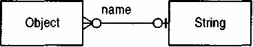

图 5.1 只有一个名称的对象。

Figure 5.1 Object with one name.

该模型暗示并非所有对象都必须有名称。有人可能会认为，没有 名称意味着指向一个空字符串，因此这种映射是强制性的。无论如何， 该模型表明一个字符串可以用作多个对象的名称。 从概念上讲，所有相同的字符串都是同一个字符串；也就是说，不存在完全相同的副本。

The model implies that not all objects have to have a name. You could argue that not having a name implies a link to an empty string, hence the mapping is mandatory. In either case this model indicates that a string can be used as a name for many objects. Conceptually all equal strings are the same string; that is, you don't have identical copies.

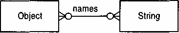

图 5.2 具有多个名称的对象。

Figure 5.2 Object with many names.

这模拟了一个带有别名的对象。一种变体是拥有一个（常用）名称和 多个别名。

This models an object with aliases. A variation may be to have one (usual) name and several aliases.

姓名并非个人的唯一身份标识。人们往往有很多名字，同一个名字也可能被不同的人使用，而且人们还会改名。所有这些因素都使得姓名不再是可靠的身份标识，尽管它仍然是迄今为止最常用的身份标识。

person's sole identifier. People have many names, the same name is used by different people, and people change names. All of these factors make names unreliable identifiers, although still by far the most common one.

名称和标识符还有另一个重要方面需要记住：名称是一种简洁的方式来向他人描述某个对象。它可以描述对象的某些属性。例如，将一款汽车型号命名为 16GL，可以告诉人们它的发动机排量和舒适度。虽然这个名称简洁地描述了该车型，但它并非标识符，因为很多车型都可以称为 16GL。

There is another aspect to names and identifiers that is important to remember: A name is a compact way of telling someone about an object. It can describe some of the properties of an object. Naming a car model 16GL tells someone about the engine size and the level of comfort. Although this name is a compact report on the model, it is not an identifier because many models could be called 16GL.

一个真正的标识符具有以下几个特性：它必须可靠地将用户引导至唯一一个对象，并且每次使用都必须指向同一个对象。图 5.3 展示了一个常见的标识符模型。与基本对象的情况不同，该标识符与对象的映射是单值的。

A true identifier has several properties: It must reliably lead the user to one and only one object and it must always lead to the same object whenever it is used. Figure 5.3 shows a common model of an identifier. Unlike the usual case with fundamental objects, the mapping back to the object is single-valued.

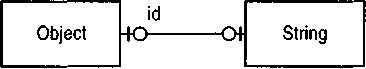

图 5.3 对象的标识符。

Figure 5.3 An identifier for an object.

这种模型意味着并非所有对象都有标识符，这在概念上是正确的， 即使在软件系统中并非如此。由于 ID 是字符串，并非所有字符串都能标识一个 对象，但要成为真正的标识符，它应该只标识一个对象。如果使用标识符类型 （通常情况下这是更可取的），那么它必须与某个对象进行强制映射 。

This model implies that not all objects have an identifier, which can be true conceptually even if it is not true in software systems. Since the id is a string, not all strings identify an object, but to be a true identifier, it should identify only one. If an identifier type were used, and that would usually be preferable, then that would have a mandatory mapping to an object.

#### 5.2 识别方案

#### 5.2 Identification Scheme

在简单的系统中，每个对象通常只有一个标识符；但更复杂的系统中，一个对象可能拥有多个标识符。医疗保健行业有多种患者识别方案：每家医院分配一个病例编号，各个科室也有各自的编号。银行业使用多种方案来识别银行：SWIFT、排序代码、CHAPS 等。这种更通用的方法可以用类似于图 5.4 的模型来支持。

In simple systems a single identifier for each object is typical, but more complex systems have many identifiers for one object. The health care industry has many schemes for identifying patients: Each hospital assigns a case number, and departments have individual numbers. Banking uses several schemes to identify banks: SWIFT, sort codes, CHAPS, and so on. This more general approach can be supported by a model along the lines of Figure 5.4.

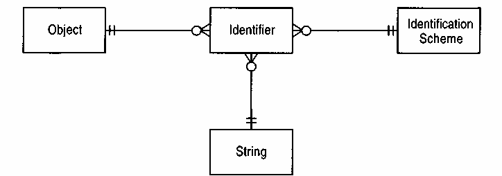

图 5.4 识别方案。

Figure 5.4 Identification schemes.

例如，世界卫生组织的《国际疾病分类》使用代码 E10 表示 I 型糖尿病。这可以表示为一个标识符，其字符串为“E10”，标识方案为 ICD-10，对象为疾病“I 型糖尿病”。

Example The World Health Organization's International Classification of Diseases uses the code E10 for type I diabetes. This can be represented as an identifier with string 'E10,' identification scheme ICD-10, and object the disease diabetes mellitus type I.

例如，假设我的护照号码是 123456。这表示为一个标识符，其字符串为“123456”，识别方案为“英国护照”，对象为“我自己”。但根据具体情况，对象也可以是我的护照。

Example Suppose I have a passport number of 123456. This is represented as an identifier with string '123456,' identification scheme UK passport, and object myself. Depending on the situation, however, the object could be my passport.

识别方案代表了用于识别对象的上下文。同一个账户可能拥有不同的SWIFT号码和CHAPS号码。相同的字符序列在SWIFT和CHAPS中可能代表两家不同的银行，但如果这些字符串采用不同的识别方案，则不会出现问题。

Identification schemes represent the context used to identify an object. A single account will have separate SWIFT and CHAPS numbers. The same character sequence can indicate two different banks in SWIFT and CHAPS, but this is not a problem if these strings are in different schemes.

图 5.4 中的模型虽然是一个起点，但并不完整。其粗糙的形式并未阻止同一个字符串在同一方案中代表多个对象。这里一个有用的概念是唯一性约束 [1]，它用于表明特定的映射组合对于某个对象类型必须具有唯一的值。

The model in Figure 5.4, although a start, is not the whole story. Its crude form includes nothing to stop one string from being used to represent more than one object within the same scheme. A useful concept here is the uniqueness constraint [1], which is used to indicate that a particular combination of mappings must have unique values for an object type.

考虑对标识方案和字符串之间的映射施加唯一性约束。这样的约束意味着任何两个标识符都不能拥有相同的标识方案和相同的字符串。由于从标识符到对象的映射是单值的，标识方案和字符串的组合可以标识一个对象——这正是我们所需要的。其他可能性也值得考虑。例如，对对象和字符串施加唯一性约束如何？这种约束意味着特定的对象和特定的字符串唯一地引用一个标识方案；换句话说，一个对象不能在两个不同的标识方案中使用相同的字符串。这种类型的唯一性约束不仅无法强制执行，而且很不方便。人们通常喜欢对不同的方案使用相同的字符串，这样就不用记住太多标识符。银行卡密码和社保号码就是两个例子。

Consider a uniqueness constraint on the mappings identification scheme and string. Such a constraint would say that no two identifiers can have the same identification scheme and the same string. Since the mapping from identifier to object is single-valued, the combination of identification scheme and string identifies a single object—exactly what we need. The other possibilities are also worth considering. How about a uniqueness constraint on object and string? This constraint would say that a particular object and a particular string uniquely reference an identification scheme; in other words, an object cannot have the same string in two different identification schemes. This type of uniqueness constraint is not only unenforceable but also inconvenient. People often like to use the same string for different schemes so they don't have to remember too many identifiers. Bank card PINs and social security numbers are two examples.

对标识方案和对象施加唯一性约束意味着，在同一个方案中，一个对象只能由一个字符串标识。这将禁止在标识方案中使用别名。别名虽然有用，但并非必不可少；它们可能带来不便，尤其是在人们将标识符与对象混淆的情况下，但并非一定会造成灾难性后果。对所有三个映射施加约束可以防止标识符的无用重复，但不会从根本上改变现状。

A uniqueness constraint on identification scheme and object would mean that within one scheme only one string can identify an object. This would disallow aliases within an identification scheme. Aliases can be useful but are not essential; they can be inconvenient, especially if people confuse the identifier with the object, but are not necessarily disastrous. A constraint for all three mappings would stop useless duplication of identifiers but would not materially alter the picture.

唯一性约束的第二部分规定对象的标识符不可更改。这意味着，在同一个方案中，同一个字符串不能从一个对象转移到另一个对象。这可以通过确保标识符不可删除以及标识符到对象的映射关系不可变来实现——也就是说，映射关系在创建时就被赋予，并且不能更改。一旦标识符被赋予，它就永久有效。实际上，有些方案确实会循环利用标识符，但只有从未被使用过的标识符才能被循环利用。

The second part of a uniqueness constraint states that an objects's identifier cannot be changed. This implies that, within a scheme, the same string cannot be switched from one object to another. This can be enforced by ensuring that identifiers cannot be deleted and that the mappings from the identifier are immutable—that is, they are assigned at creation and cannot change. Once an identifier is assigned, it is assigned for good. In reality some schemes do recycle identifiers, but only identifiers that have never been used can be recycled.

在典型的面向对象语言中，唯一性约束是如何实现的？标识符的不可变性对此大有帮助。由于不可变性不允许在软件内部更新映射关系，因此不存在公共的修改器操作。映射关系必须在创建操作中通过传递参数来设置。在创建操作期间，需要检查是否存在其他标识符具有相同映射组合的唯一性约束。

How are uniqueness constraints implemented in a typical object-oriented language? The immutability of the identifiers is a considerable help. Immutability allows no update of the mapping within software, so there is no public modifier operation. The mappings must be set in the creation operation by passing the values as arguments. During the creation operation a check needs to be made that no other identifier exists with the same combination of mappings that make up the uniqueness constraint.

通常，标识方案会负责检查其标识符所用字符串的格式。这项检查会在创建标识符时进行。如果字符串中包含任何关于被引用对象的重要信息，那么这些信息也应该被检查。例如，我的标识符可能是 U123，其中 U 表示我居住在美国。如果我返回英国，这个标识符就会造成问题。一般来说，将对象特征信息嵌入到标识字符串中是一种不好的做法，因为这种做法意味着当对象特征发生变化时，字符串也应该随之改变。更好的做法是生成一个单独的字符串来提供这类简洁的信息。

Usually the identification scheme would be responsible for checking the format of the strings used by its identifiers. This check would be made when the identifiers are created. If the string embeds any meaningful information about the referenced object, then this information should also be checked. I might have an identifier U123, where the U indicates I live in United States. This identifier would cause a problem should I return to England. In general it is bad practice to embed information about features of an object into an identification string, because such practice implies that the string should change when the features change. It is better to generate a separate string that provides this kind of compact information.